# Community Assy - Observational Data

Mike Verhoeven

2022-10-19

This script will pull in data for PI surveys (point and aggregated to survey level and up to watershed level), it will grab management data and slice out surveys from managed lakes.

Next we evaluate invaders, light, and species pools as drivers of native community Diversity, Richness, and Evenness. The goal of these analyses is to understand how these factors influence community assembly in aquatic plants.

# Document Preamble

```r
# load libraries ------------------------------------------------------------------
```

```r
# # Load Libraries
library(data.table)
update_dev_pkg()# remotes::install_github("Rdatatable/data.table")
```

```
## R data.table package is up-to-date at 0895fa247afcf6b38044bd5f56c0d209691ddb31 (1.14.5)
```

```
## Aggregate function missing, defaulting to 'length'
```

```
## Aggregate function missing, defaulting to 'length'
```

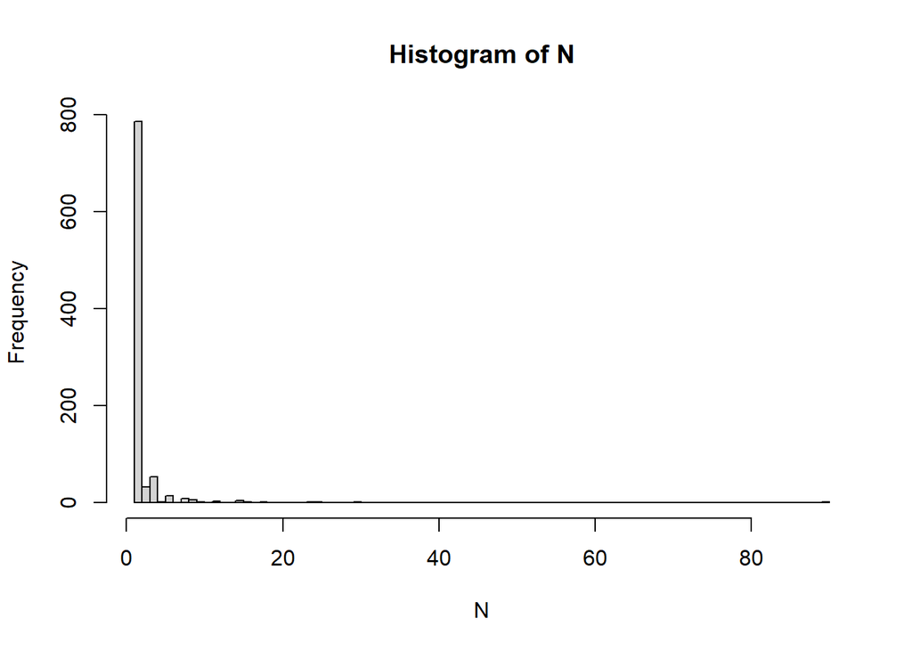

```r
library(ggplot2)
library(stringr)
# library(sf)
# library(vegan)
# library(gridExtra)
# library(dplyr)
library(tidyr)
library(lme4)
library(sjPlot)
library(mediation)
library(ggpubr)
library(EnvStats)
library(lmerTest)
library(merTools)
library(rstanarm)
library(janitor)
library(GGally)
library(VCA)
library(performance)
library(ggsignif)

# library(maps)
# library(rgdal)
# library(ggsn)
# library(moments)
# library(shiny)
# library(plotly)
# library(ggspatial)
# library(broom)
# library(woodson)



# load in functions -------------------------------------------------------

# ben bolkers CI calc fn (https://github.com/bbolker/asaglmm/blob/master/papers/bolker_chap.rmd)
easyPredCIbinom <- function(model,newdata,alpha=0.05) {
  ## baseline prediction, on the linear predictor (log-odds) scale:
  pred0 <- predict(model,re.form=NA,newdata=newdata)
  ## fixed-effects model matrix for new data
  X <- model.matrix(formula(model,fixed.only=TRUE)[-2],
                    newdata)
  beta <- fixef(model) ## fixed-effects coefficients
  V <- vcov(model)     ## variance-covariance matrix of beta
  pred.se <- sqrt(diag(X %*% V %*% t(X))) ## std errors of predictions
  ## inverse-link (logistic) function: could also use plogis()
  plogis <- model@resp$family$plogis
  ## construct 95% Normal CIs on the link scale and
  ##  transform back to the response (probability) scale:
  crit <- -qnorm(alpha/2)
  plogis(cbind(lwr=pred0-crit*pred.se,
               upr=pred0+crit*pred.se))
}



# load in data -------------------------------------------------

# this is an observation level dataset (our foundation plant data)
plants <- fread(file = "data&scripts/data/output/plants_env_data.csv")

#here we have aggregated the plants dataset into a typical format with a "wide" config, and a row for each point or rake throw
plants_occurrence_wide <- fread(file = "data&scripts/data/output/plants_env_data_wide.csv", drop = 1)

#here we have thinned to only obs with point level abunds and aggregated to "wide" config with a row for each point or rake throw, species matrix contains relative abundances
plants_rakeabund_wide <- fread(file = "data&scripts/data/output/plants_abund_env_data_wide.csv")

# here we have aggregated plants dataset to the survey level, each row is a set of survey statistics (richness, diversity, etc.) and a lake level species matrix
surveys <- fread(file = "data&scripts/data/output/surveys_aqplants.csv")

# other companion data like watershed & lake geodata, MN plants checklist, watershed aggregation of plants database
load("data&scripts/data/output/synthesis_script_datasets.Rdata")

#managemnt data is cleaned in a companion script & leaves data loaded into ws
source(file = "data&scripts/b1_community_assy_analysis.R") # will load and clean management data and leave in WS a mgmtdata file
```

```r
# data prep ---------------------------------------------------------------
```

# Data Prep:

Because of the distinct phenology of CLP, we’ve got to use estimates of abundance from early season surveys (during the growth phase of CLP annual life cycle).

We can do this ONLY for the survey level work… That’s b/c at the point level we don’t have the ability to connect two sample locations across time.

So at the lake scale, we will use spring (Mar-June) surveys to come up with a value for CLP abundance, then add that to subsequent summer surveys.

At the point scale we need to use the point-level abundance data. That means that we also need to model the date of observation because of the phenology effect.

```r
# CLP metric &  summer surveys ------------------------------------------------
```

## Spring CLP & Summer surveys:

Here we calc a spring CLP value and carry it forward to the summer survey (where native metrics come from).

```r
#put a CLP index into the peak surveys:
early_clpsurveys <- surveys[month(DATESURVEYSTART) %in% c(3,4,5,6) , .(SURVEY_ID, DOW, year = year(DATESURVEYSTART), LAKE_NAME, SUBBASIN, Potamogeton_crispus,DATESURVEYSTART, n_points_vegetated, tot_n_samp)  , ]

early_clpsurveys[ , potcri_early_vegdfoc := Potamogeton_crispus/n_points_vegetated ]
early_clpsurveys[is.na(potcri_early_vegdfoc), potcri_early_vegdfoc := 0]
early_clpsurveys[ ,.N , potcri_early_vegdfoc>0]
```

```
##    potcri_early_vegdfoc     N
##                  <lgcl> <int>
## 1:                FALSE   458
## 2:                 TRUE   669
```

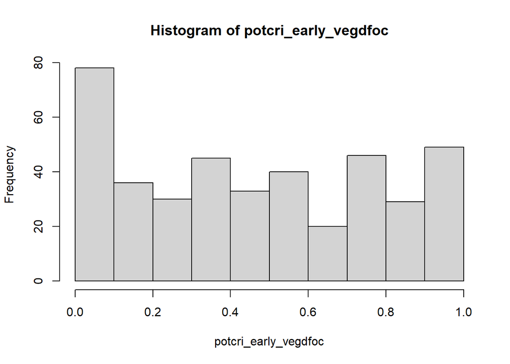

```
## $breaks
##  [1] 0.0 0.1 0.2 0.3 0.4 0.5 0.6 0.7 0.8 0.9 1.0
##
## $counts
##  [1] 78 36 30 45 33 40 20 46 29 49
##
## $density
##  [1] 1.9211823 0.8866995 0.7389163 1.1083744 0.8128079 0.9852217 0.4926108
##  [8] 1.1330049 0.7142857 1.2068966
##
## $mids
##  [1] 0.05 0.15 0.25 0.35 0.45 0.55 0.65 0.75 0.85 0.95
##
## $xname
## [1] "potcri_early_vegdfoc"
##
## $equidist
## [1] TRUE
##
## attr(,"class")
## [1] "histogram"
```

```r
surveys[ , year := year(DATESURVEYSTART) , ]

#thin summer surveys to exclude pre june 15
summer_surveys <- surveys[yday(DATESURVEYSTART) > 151  , , ]

#append early clp metrics to these summer surveys,:

summer_surveys[ , joindates := DATESURVEYSTART]
early_clpsurveys[ , joindateE := DATESURVEYSTART]


summer_surveys <- early_clpsurveys[summer_surveys, on = .(DOW, year, LAKE_NAME, SUBBASIN, joindateE < joindates), mult = "first" ]

names(summer_surveys)[names(summer_surveys) == "DATESURVEYSTART"] <- "SPRING_DATESURVEYSTART"
names(summer_surveys)[names(summer_surveys) == "SURVEY_ID"] <- "SPRING_SURVEY_ID"
names(summer_surveys)[names(summer_surveys) == "Potamogeton_crispus"] <- "SPRING_Potamogeton_crispus"
names(summer_surveys)[names(summer_surveys) == "n_points_vegetated"] <- "SPRING_n_points_vegetated"
names(summer_surveys)[names(summer_surveys) == "tot_n_samp"] <- "SPRING_tot_n_samp"

names(summer_surveys)[names(summer_surveys) == "i.DATESURVEYSTART"] <- "DATESURVEYSTART"
names(summer_surveys)[names(summer_surveys) == "i.SURVEY_ID"] <- "SURVEY_ID"
names(summer_surveys)[names(summer_surveys) == "i.Potamogeton_crispus"] <- "Potamogeton_crispus"
names(summer_surveys)[names(summer_surveys) == "i.n_points_vegetated"] <- "n_points_vegetated"
names(summer_surveys)[names(summer_surveys) == "i.tot_n_samp"] <- "tot_n_samp"

summer_surveys[ , hist(potcri_early_vegdfoc)]
```

```r
summer_surveys[ , .N , SPRING_Potamogeton_crispus==0]
```

```
##    SPRING_Potamogeton_crispus     N
##                        <lgcl> <int>
## 1:                         NA  2531
## 2:                      FALSE   364
## 3:                       TRUE    42
```

```r
# bring in mgmt data ------------------------------------------------------
```

## Management Data

check out the management data, and link it up to the surveys. Our goal is to be able to exclude managed systems from these analyses.

```r
#merge mgmt data on dows & years
mgmtdata[ , p_dow := round(downum/100, 0) ,]
summer_surveys[ , p_dow := round(DOW/100, 0) , ]

#gotta deal with subbasin exents
summer_surveys[ , sort(unique(SUBBASIN)) ,]
```

```
##  [1] ""                         "agency bay"
##  [3] "boy bay"                  "Carsons & St. Louis Bays"
##  [5] "Carsons Bay"              "cove bay"
##  [7] "East"                     "East and West Basins"
##  [9] "east basin"               "East Basin"
## [11] "East Phelps Bay"          "EastBasin"
## [13] "Gideons Bay"              "Grays Bay"
## [15] "Halsteads Bay"            "headquarters bay"
## [17] "isle bay"                 "kabekona bay"
## [19] "main lake"                "malmo"
## [21] "Maxwell Bay"              "North"
## [23] "North Arm Bay"            "north basin"
## [25] "portage bay"              "shabushkung bay"
## [27] "shingobee bay"            "Smiths Bay"
## [29] "South"                    "south basin"
## [31] "south portion"            "Southeast Basin"
## [33] "St Albans Bay"            "steamboat bay"
## [35] "Stubbs Bay"               "submarine island"
## [37] "sucker bay"               "Sunny"
## [39] "traders bay"              "twin bay"
## [41] "Vets Bay"                 "vineland bay"
## [43] "wahkon bay"               "walker center"
## [45] "walker north"             "walker south"
## [47] "weathwood"                "West"
## [49] "west basin"               "West Basin"
## [51] "West Phelps Bay"          "WestBasin"
## [53] "whipholt bay"             "wigwam bay"
## [55] "Zumbra"
```

```r
#minnetonka
summer_surveys[str_detect(LAKE_NAME, "inneto"), sort(unique(SUBBASIN))]
```

```
##  [1] "Carsons & St. Louis Bays" "Carsons Bay"
##  [3] "East Phelps Bay"          "Gideons Bay"
##  [5] "Grays Bay"                "Halsteads Bay"
##  [7] "Maxwell Bay"              "North Arm Bay"
##  [9] "Smiths Bay"               "St Albans Bay"
## [11] "Stubbs Bay"               "Vets Bay"
## [13] "West Phelps Bay"
```

```r
mgmtdata[str_detect(lakename, "innet") , sort(unique(lakename)) ,]
```

```
##  [1] "minnetonka-black lake"     "minnetonka-carsons bay"
##  [3] "minnetonka-carsonsbay"     "minnetonka-crystal bay"
##  [5] "minnetonka-crystalbay"     "minnetonka-emerald lake"
##  [7] "minnetonka-grays bay"      "minnetonka-graysbay"
##  [9] "minnetonka-halsteds bay"   "minnetonka-lower"
## [11] "minnetonka-lower lake"     "minnetonka-maxwell bay"
## [13] "minnetonka-north arm"      "minnetonka-northarm"
## [15] "minnetonka-seton lake"     "minnetonka-st. albans bay"
## [17] "minnetonka-st.albansbay"   "minnetonka-upper"
## [19] "minnetonka-upper lake"     "minnetonka-west arm"
```

```r
mgmtdata[str_detect(lakename, "innet") , sort(unique(subbasin)) ,]
```

```
## character(0)
```

```r
mgmtdata[str_detect(lakename, "innet") , subbasin := word(lakename, -1, sep = "-") , ]
mgmtdata[str_detect(lakename, "innet") , lakename := "minnetonka"]
#grays bay
mgmtdata[str_detect(lakename, "innet") &
           str_detect(subbasin, "gray") , subbasin := "Grays Bay"]
#lower lake
mgmtdata[str_detect(lakename, "innet") &
           str_detect(subbasin, "lower") , subbasin := "Lower Lake"]
#carsons bay
mgmtdata[str_detect(lakename, "innet") &
           str_detect(subbasin, "carsons") , subbasin := "Carsons Bay"]
#crystal bay
mgmtdata[str_detect(lakename, "innet") &
           str_detect(subbasin, "crystal") , subbasin := "Crystal Bay"]
#st.albans
mgmtdata[str_detect(lakename, "innet") &
           str_detect(subbasin, "albans") , subbasin := "St Albans Bay"]
#northarm
mgmtdata[str_detect(lakename, "innet") &
           str_detect(subbasin, "orth") , subbasin := "North Arm Bay" ]
#halsteads
mgmtdata[str_detect(lakename, "innet") &
           str_detect(subbasin, "halsted") , subbasin := "Halsteads Bay" ]
#upper
mgmtdata[str_detect(lakename, "innet") &
           str_detect(subbasin, "upper") , subbasin := "Upper Lake" ]

#compress to lake-year
mgmtdata[ , .N , .(downum,year)][N>1]
```

```
##        downum  year     N
##         <int> <int> <int>
##   1:  2002600  2017     4
##   2:  2004200  2016     4
##   3:  2004200  2017     4
##   4:  2004200  2018     2
##   5:  2004200  2019     3
##  ---
## 301: 86028800  2016     4
## 302: 86028800  2017     2
## 303: 86028800  2018     4
## 304: 86028800  2019     2
## 305: 86028900  2018     2
```

```r
mgmtdata[records >1]
```

```
##        year   downum         lakename clp_targeted ewm_targeted
##       <int>    <int>           <char>       <lgcl>       <lgcl>
##    1:  2017  2002600          linwood         TRUE           NA
##    2:  2017  2002600          linwood           NA         TRUE
##    3:  2017  2002600          linwood         TRUE           NA
##    4:  2017  2002600          linwood           NA         TRUE
##    5:  2016  2004200             coon         TRUE         TRUE
##   ---
## 1172:  2018 86028800             john         TRUE           NA
## 1173:  2019 86028800             john           NA         TRUE
## 1174:  2019 86028800             john         TRUE           NA
## 1175:  2018 86028900 east lake sylvia           NA         TRUE
## 1176:  2018 86028900 east lake sylvia           NA         TRUE
##                            controlmethod    trtdate acrestreated    permit
##                                   <char>     <char>        <num>    <char>
```

[output cut: 102 more lines]

```r
simp_mgmt <- mgmtdata[ , .N , .(lakename, year, downum) , ]

simp_mgmt[mgmtdata[ewm_targeted==T], ewmtargeted := ewm_targeted, on = .(lakename, year, downum)]

simp_mgmt[mgmtdata[clp_targeted==T], clptargeted := clp_targeted, on = .(lakename, year, downum)]

summary(simp_mgmt)
```

```
##    lakename              year          downum               N
##  Length:913         Min.   :2016   Min.   : 1009900   Min.   : 1.000
##  Class :character   1st Qu.:2017   1st Qu.:19002700   1st Qu.: 1.000
##  Mode  :character   Median :2017   Median :34015400   Median : 1.000
##                     Mean   :2018   Mean   :44190127   Mean   : 1.955
##                     3rd Qu.:2018   3rd Qu.:71008100   3rd Qu.: 2.000
##                     Max.   :2019   Max.   :87013400   Max.   :90.000
##  ewmtargeted    clptargeted
##  Mode:logical   Mode:logical
##  TRUE:413       TRUE:652
##  NA's:500       NA's:261
##
##
##
```

```r
fullmgmtdata <- mgmtdata

mgmtdata <- simp_mgmt

names(mgmtdata)[names(mgmtdata) == "downum"] <- "DOW"

summer_surveys[ , .N , Myriophyllum_spicatum>0]
```

```
##    Myriophyllum_spicatum     N
##                   <lgcl> <int>
## 1:                 FALSE  2460
## 2:                  TRUE   477
```

```r
summer_surveys[mgmtdata, clp_targeted := clptargeted  , on = .(DOW, year)]
summer_surveys[mgmtdata, ewm_targeted := ewmtargeted  , on = .(DOW, year)]


summer_surveys[ , .N , clp_targeted]
```

```
##    clp_targeted     N
##          <lgcl> <int>
## 1:           NA  2892
## 2:         TRUE    45
```

```r
summer_surveys[ , .N , ewm_targeted]
```

```
##    ewm_targeted     N
##          <lgcl> <int>
## 1:           NA  2895
## 2:         TRUE    42
```

```r
#summary stats

summer_surveys[ , summary(clp_targeted) ,]
```

```
##    Mode    TRUE    NA's
## logical      45    2892
```

```r
summer_surveys[potcri_early_vegdfoc > 0 , summary(clp_targeted) ,]
```

```
##    Mode    TRUE    NA's
## logical       7     357
```

```r
summer_surveys[is.na(potcri_early_vegdfoc) & clp_targeted == T , .(year, LAKE_NAME, DATASOURCE, DATESURVEYSTART )  ,]
```

```
##      year      LAKE_NAME           DATASOURCE DATESURVEYSTART
##     <int>         <char>               <char>          <IDat>
##  1:  2018   south center DNR Lakes and Rivers      2018-07-09
##  2:  2017 ossawinnamakee DNR Lakes and Rivers      2017-07-24
##  3:  2017        crooked        James Johnson      2017-08-14
##  4:  2018        crooked        James Johnson      2018-08-14
##  5:  2018           duck    Allison Gamble_19      2018-07-23
##  6:  2016       red rock        James Johnson      2016-07-25
##  7:  2018       red rock        James Johnson      2018-07-06
##  8:  2016         weaver        James Johnson      2016-07-29
##  9:  2018         weaver        James Johnson      2018-08-27
## 10:  2017        portage DNR Lakes and Rivers      2017-06-26
## 11:  2017        tetonka       Allison Gamble      2017-07-13
## 12:  2018     washington    Allison Gamble_19      2018-07-17
## 13:  2016       sullivan        James Johnson      2016-08-03
```

[output cut: 26 more lines]

```r
summer_surveys[ , summary(ewm_targeted) ,]
```

```
##    Mode    TRUE    NA's
## logical      42    2895
```

```r
summer_surveys[Myriophyllum_spicatum > 0 , summary(ewm_targeted) ,]
```

```
##    Mode    TRUE    NA's
## logical      39     438
```

```r
summer_surveys[Myriophyllum_spicatum == 0 & ewm_targeted == T , .(year, LAKE_NAME, DATASOURCE, DATESURVEYSTART)  ,]
```

```
##     year LAKE_NAME        DATASOURCE DATESURVEYSTART
##    <int>    <char>            <char>          <IDat>
## 1:  2018   frances Allison Gamble_19      2018-07-09
## 2:  2018      rush     James Johnson      2018-08-10
## 3:  2017     marie       Cole Loewen      2017-07-28
```

```r
summer_surveys[is.na(clp_targeted), .N , potcri_early_vegdfoc>0 ]
```

```
##    potcri_early_vegdfoc     N
##                  <lgcl> <int>
## 1:                   NA  2493
## 2:                 TRUE   357
## 3:                FALSE    42
```

```r
# invader metrics ---------------------------------------------------------
```

## Invader Abundance Metrics

```r
# visualize "effects" at lake level
summer_surveys[, myrspi_summer_vegdfoc := Myriophyllum_spicatum/n_points_vegetated]
summer_surveys[is.na(myrspi_summer_vegdfoc) , myrspi_summer_vegdfoc := 0 , ]

summer_surveys[ , .N , n_points_vegetated>0 ]
```

```
##    n_points_vegetated     N
##                <lgcl> <int>
## 1:               TRUE  2871
## 2:              FALSE    66
```

```r
summer_surveys[ , .N , myrspi_summer_vegdfoc>0]
```

```
##    myrspi_summer_vegdfoc     N
##                   <lgcl> <int>
## 1:                 FALSE  2460
## 2:                  TRUE   477
```

```r
summer_surveys[, potcri_summer_vegdfoc := Potamogeton_crispus/n_points_vegetated]
summer_surveys[is.na(potcri_summer_vegdfoc) , potcri_summer_vegdfoc := 0 , ]

# native metrics ----------------------------------------------------------
```

## Native Response Metrics

We have measured Diversity, Richness and Evenness for the native plants. Lets have a look at the correllations among these responses. In addition, we’ll grab some summary stats for a table in the paper.

I do think that it makes sense to have inv simpsons assigned as zero where it goes to inf for richness 0. That because the effective number of species is zero when there are zero species (i.e., it seems logical).

I don’t think that we want to be coercing the NAs in evenness to zero. It just doesn’t make sense. Evenness of a 0 species community is NA.

```r
#lake level
summer_surveys[ ,summary(simpsons_div_nat) ,]
```

```
##    Min. 1st Qu.  Median    Mean 3rd Qu.    Max.
##   0.000   2.532   4.285   5.086   7.188  20.761
```

```r
summer_surveys[ ,summary(nat_richness) ,]
```

```
##    Min. 1st Qu.  Median    Mean 3rd Qu.    Max.
##    0.00    5.00    9.00   10.98   16.00   47.00
```

```r
summer_surveys[ ,summary(simpsons_div_nat/nat_richness) ,]
```

```
##    Min. 1st Qu.  Median    Mean 3rd Qu.    Max.    NA's
## 0.08766 0.40074 0.51613 0.54086 0.65081 1.00000      86
```

```r
# evenness produces NAs because of zero richness values --
summer_surveys[nat_richness == 0 , .N ,  ]
```

```
## [1] 86
```

```r
summer_surveys[ , nat_evenness := simpsons_div_nat/nat_richness, ]


#watershed level
names(watershed_occurrence_wide)
```

```
##   [1] "watershed"                      "n_points"
##   [3] "n_species"                      "NA"
##   [5] "Acorus"                         "Acorus americanus"
##   [7] "Alisma"                         "Alisma triviale"
##   [9] "Alnus"                          "Andromeda glaucophylla"
##  [11] "Andromeda polifolia"            "Asclepias incarnata"
##  [13] "Asteraceae"                     "Azolla mexicana"
##  [15] "Betula pumila"                  "Bidens"
##  [17] "Bidens beckii"                  "Bolboschoenus fluviatilis"
##  [19] "Bolboschoenus maritimus"        "Boltonia asteroides"
##  [21] "Brasenia schreberi"             "Butomus umbellatus"
##  [23] "Calamagrostis canadensis"       "Calla palustris"
##  [25] "Callitriche"                    "Caltha palustris"
##  [27] "Carex"                          "Carex aquatilis"
##  [29] "Carex comosa"                   "Carex lacustris"
```

[output cut: 103 more lines]

```r
watershed_occurrence_wide[ , summary(n_species) ,] # this is total richness
```

```
##    Min. 1st Qu.  Median    Mean 3rd Qu.    Max.    NA's
##    1.00   30.00   54.50   53.79   77.25  118.00       2
```

```r
# native richness
natcols <- names(watershed_occurrence_wide)[4:235][!names(watershed_occurrence_wide)[4:235] %in% c(rte[native_status == "I", mn_dnr_scientific_name],
                                                                            "Nitellopsis", "Typha glauca")]
watershed_occurrence_wide[ ,  nat_richness := rowSums(watershed_occurrence_wide[ , .SD, .SDcols = natcols] > 0), ]
watershed_occurrence_wide[ ,summary(nat_richness)]
```

```
##    Min. 1st Qu.  Median    Mean 3rd Qu.    Max.
##    1.00   25.75   51.00   50.93   73.75  114.00
```

```r
watershed_occurrence_wide[simpson_div == Inf , simpson_div := 0 ,]
watershed_occurrence_wide[ , summary(simpson_div) ,]
```

```
##    Min. 1st Qu.  Median    Mean 3rd Qu.    Max.
##   0.000   5.739  10.796  10.752  15.341  24.482
```

```r
watershed_occurrence_wide[ , nat_evenness := simpson_div/nat_richness, ]
watershed_occurrence_wide[ , summary(nat_evenness), ]
```

```
##    Min. 1st Qu.  Median    Mean 3rd Qu.    Max.
##  0.0000  0.1591  0.2004  0.2293  0.2916  0.5880
```

```r
#add area to these
watershed_occurrence_wide[watersheds_huc8, on = .(watershed=major), acres := acres ]


#point level
plants_rakeabund_wide[ , summary(nat_richness) ,]
```

```
##    Min. 1st Qu.  Median    Mean 3rd Qu.    Max.
##   0.000   1.000   2.000   2.017   3.000  16.000
```

```r
plants_rakeabund_wide[simpsons_div_nat == Inf , simpsons_div_nat := 0 ,]
plants_rakeabund_wide[ , summary(simpsons_div_nat) , ]
```

```
##    Min. 1st Qu.  Median    Mean 3rd Qu.    Max.
##   0.000   1.000   1.600   1.878   2.667  14.286
```

```r
plants_rakeabund_wide[ , nat_evenness := simpsons_div_nat/nat_richness, ]
plants_rakeabund_wide[ , summary(nat_evenness), ]
```

```
##    Min. 1st Qu.  Median    Mean 3rd Qu.    Max.    NA's
##   0.750   0.900   1.000   0.953   1.000   1.000   11125
```

```r
#median area for each scale
watershed_occurrence_wide[ , summary(acres)]
```

```
##    Min. 1st Qu.  Median    Mean 3rd Qu.    Max.    NA's
##   45649  501312  671021  742577  979322 1831462       1
```

```r
summer_surveys[ , summary(acres.x) , ]
```

```
##      Min.   1st Qu.    Median      Mean   3rd Qu.      Max.      NA's
##      3.12     69.12    158.10   1661.18    362.82 128250.53        18
```

```r
#sample sizes by scale
watershed_occurrence_wide[!is.na(watershed), .N , ]
```

```
## [1] 67
```

```r
summer_surveys[ , .N ,]
```

```
## [1] 2937
```

```r
plants_rakeabund_wide[ , .N ,]
```

```
## [1] 81906
```

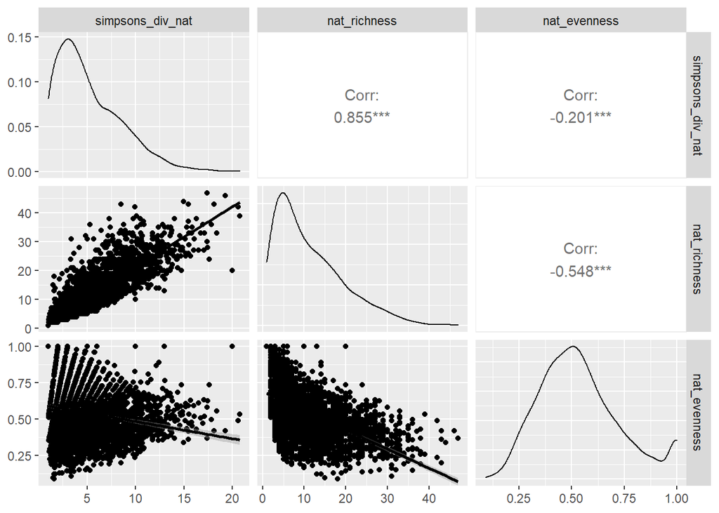

```r
#correlations and viz.
# plot covariance and correllation coefs (r) from the niche axes

# evenness is zero only where the richness is zero... and evenness of zero might not be a meaningful thing, so lets drop those here

ggpairs(summer_surveys[!is.na(nat_evenness),.(simpsons_div_nat, nat_richness, nat_evenness ) ,], lower = list(continuous = "smooth"), aes(fill = NULL))
```

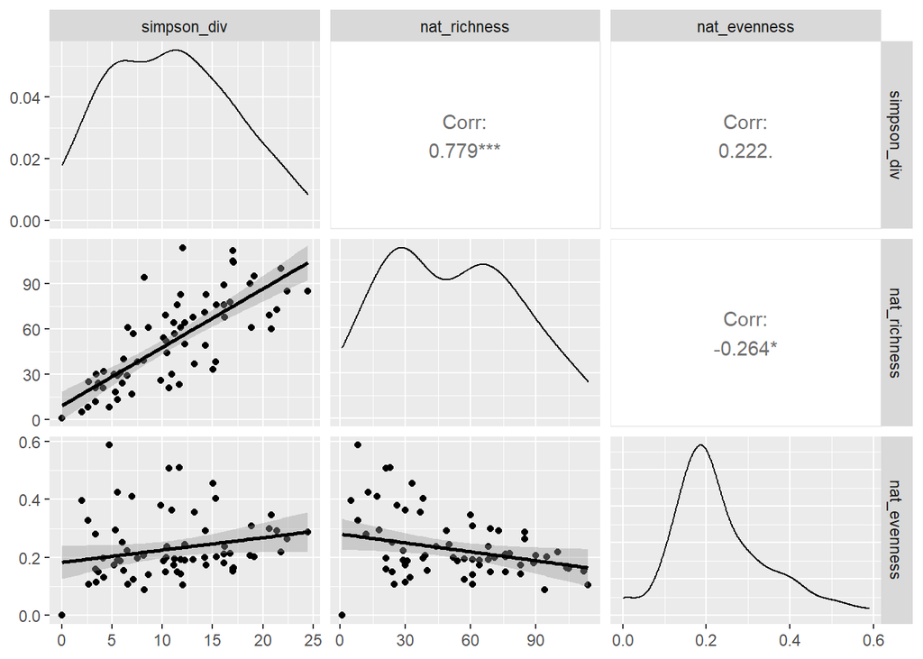

```r
ggpairs(watershed_occurrence_wide[!is.na(nat_evenness) ,.(simpson_div, nat_richness, nat_evenness ) ,], lower = list(continuous = "smooth"), aes(fill = NULL))
```

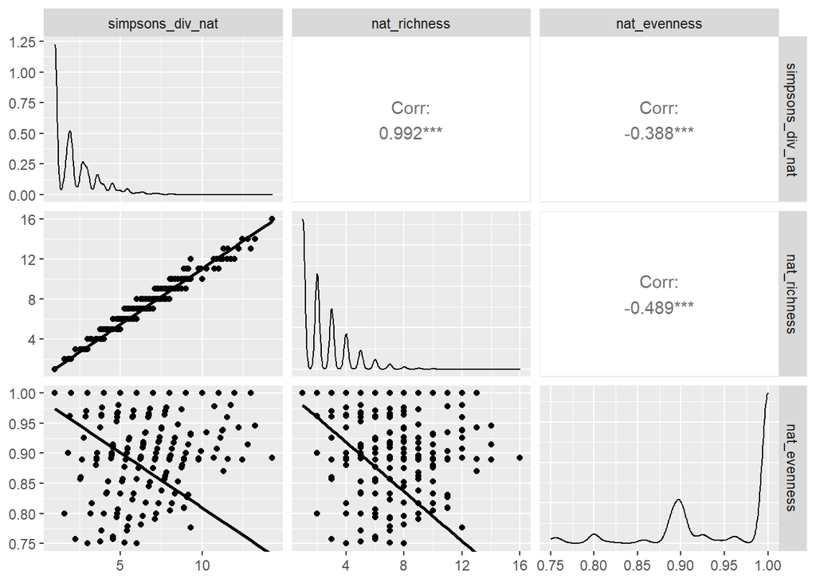

```r
ggpairs(plants_rakeabund_wide[!is.na(nat_evenness),.(simpsons_div_nat, nat_richness, nat_evenness ) ,], lower = list(continuous = "smooth"), aes(fill = NULL))
```

```r
#and we'll use a VCA to examine where diversity is coming from in out data

# names(plants_rakeabund_wide)
#
# varPlot(form = simpsons_div_nat~DOW/watershed,
#        Data=plants_rakeabund_wide)
#
# fitVCA(form=proplight~lake/site/plot + year,
#        Data=community[!quadrat == "m" ])




# data analysis -----------------------------------------------------------
```

# Data Analysis

Now we will have a look at how invaders, light, and species pools are related to the Diversity Richness & Evenness (DRE) of native plant communities.

```r
# viz lake level invader effects ----------------------------------------------
```

## Competitive Interactions

We’re going to take a look at the lake and point scale influence of invaders on native species. Some things to keep an eye out for in these analyses 1. We’re looking at only invaders as the independent variable 2. We have 3 metrics for native responses (DRE) 3. We’re interested in how the two species of invader’s differ in these relationships to natives. 4. We’ll be doing a two-step style analysis, first asking how the presence of the invader influences natives, then asking how increasing invader abundance is related to natives

Before we do our analyses, lets visualize the relationships that are of interest to us.

### Lake Level - Viz

```r
# presence absence lake scale boxplots ------------------------------------
# grab out just the rows where each invader could be estimated & make a plot table
clpboxplot <- summer_surveys[!is.na(potcri_early_vegdfoc), "inv.pres" := potcri_early_vegdfoc > 0 ] # here we exclude summer surveys with no early clp survey
clpboxplot[ , species := "CLP" ,]
clpboxplot <- clpboxplot[!is.na(inv.pres) , .SD , .SDcols = c("inv.pres", "species", "nat_richness", "simpsons_div_nat")]

ewmboxplot <- summer_surveys[!is.na(myrspi_summer_vegdfoc),"inv.pres" := myrspi_summer_vegdfoc > 0 ]
ewmboxplot[ , species := "EWM" ,]
ewmboxplot <- ewmboxplot[!is.na(inv.pres) , .SD , .SDcols = c("inv.pres", "species", "nat_richness", "simpsons_div_nat")]

boxplot_data <- rbind(ewmboxplot,clpboxplot)
rm(clpboxplot, ewmboxplot)

boxplot_data[ , evenness := simpsons_div_nat/nat_richness]
# boxplot_data[is.na(evenness), evenness := 0]

boxplot_data <- melt(boxplot_data, id.vars = c("inv.pres","species"), variable.name = "metric", value.name = "value")
boxplot_data[ , metric:= factor(metric, levels = c("simpsons_div_nat", "nat_richness", "evenness")),]

box1 <- ggplot(data = boxplot_data[metric == "simpsons_div_nat"], aes(species, value, fill = inv.pres))+
  geom_boxplot()+
  scale_x_discrete(limits= c("CLP", "EWM"),labels=c("Potamogeton crispus","Myriophyllum spicatum"))+
  scale_fill_discrete(limits= c("FALSE", "TRUE"),labels=c("Invader Absent","Invader Present"))+
  xlab(NULL)+
  ylab(bquote('Native diversity ('~ENS[PIE]~')'))+
  theme_bw()+
  theme(axis.text.x = element_text( face = "italic"), legend.position = c(.35,.9), legend.title = element_blank(), legend.background = element_blank())+
  ggtitle("All Lake Surveys")

boxplot_data[metric == "nat_richness", .N, .(species,inv.pres)]
```

```
##    species inv.pres     N
##     <char>   <lgcl> <int>
## 1:     EWM    FALSE  2460
## 2:     EWM     TRUE   477
## 3:     CLP     TRUE   364
## 4:     CLP    FALSE    42
```

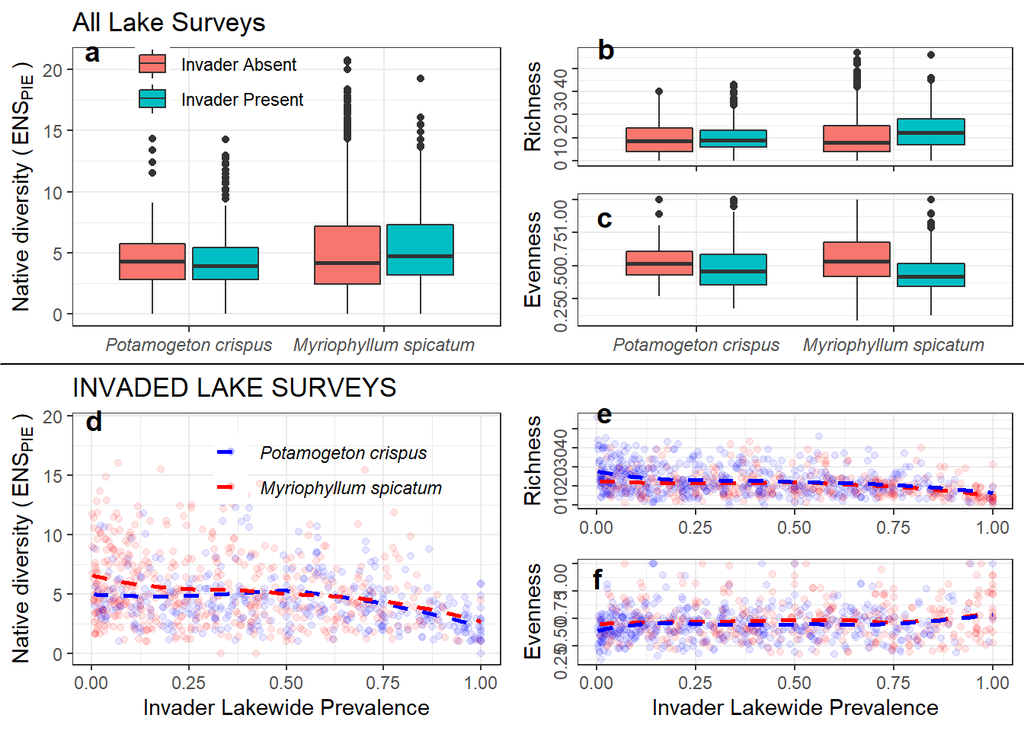

```r
box2 <- ggplot(data = boxplot_data[metric == "nat_richness"], aes(species, value, fill = inv.pres))+
  geom_boxplot()+
  scale_x_discrete(limits= c("CLP", "EWM"),labels=c("Potamogeton crispus","Myriophyllum spicatum"))+
  xlab(NULL)+
  ylab("Richness")+
  theme_bw()+
  theme(axis.text.x = element_blank(), legend.position = "none")+
  ggtitle("")+
  theme(axis.text.y.left = element_text(angle = 90))

box3 <- ggplot(data = boxplot_data[metric == "evenness"], aes(species, value, fill = inv.pres))+
  geom_boxplot()+
  scale_x_discrete(limits= c("CLP", "EWM"),labels=c("Potamogeton crispus","Myriophyllum spicatum"))+
  xlab(NULL)+
  ylab("Evenness")+
  theme_bw()+
  theme(axis.text.x = element_text( face = "italic"), legend.position = "none")+
  theme(axis.text.y.left = element_text(angle = 90))

boxps <- ggarrange(box1, ggarrange(box2, box3, ncol = 1,
                                   labels = c("b","c"),
                                   label.x = c(0.15,0.15),
                                   label.y = c(0.85,0.93)),
                   labels = c("a", ""),
                   label.x = 0.15,
                   label.y = 0.92)
# abundance lake scale regressions ----------------------------------------


legend_colors <- c("potcri_early_vegdfoc" = "blue", "myrspi_summer_vegdfoc" = "red")
INV_ENSpie <- ggplot()+
  geom_point(data = summer_surveys[myrspi_summer_vegdfoc > 0  ],
             aes(myrspi_summer_vegdfoc, simpsons_div_nat, color = "myrspi_summer_vegdfoc"),
             alpha = 0.1)+
  geom_point(data = summer_surveys[potcri_early_vegdfoc > 0],
             aes(potcri_early_vegdfoc, simpsons_div_nat, color = "potcri_early_vegdfoc"),
             alpha = 0.1)+
  geom_smooth(data = summer_surveys[potcri_early_vegdfoc > 0 ],
              aes(potcri_early_vegdfoc, simpsons_div_nat, color = "potcri_early_vegdfoc"),
              method = "loess", lty = 2, se = F)+
  geom_smooth(data = summer_surveys[myrspi_summer_vegdfoc > 0  ],
              aes(myrspi_summer_vegdfoc, simpsons_div_nat, color = "myrspi_summer_vegdfoc"),
              method = "loess", lty = 2, se = F)+
  xlab("Invader Lakewide Prevalence")+
  ylab(bquote('Native diversity ('~ENS[PIE]~')'))+
  ggtitle("INVADED LAKE SURVEYS")+
  labs(color = NULL) +
  scale_color_manual(values = legend_colors, labels = c("Potamogeton crispus","Myriophyllum spicatum"))+
  theme_bw()+
  theme(legend.position = c(0.6, 0.8), legend.background = element_blank(), legend.text = element_text(face = "italic"))



INV_richness <- ggplot()+
  geom_point(data = summer_surveys[potcri_early_vegdfoc > 0 ],
             aes(potcri_early_vegdfoc, nat_richness),
             alpha = 0.1, color = "red")+
  geom_point(data = summer_surveys[myrspi_summer_vegdfoc > 0  ],
             aes(myrspi_summer_vegdfoc, nat_richness),
             alpha = 0.1, color = "blue")+
  geom_smooth(data = summer_surveys[potcri_early_vegdfoc > 0 ],
              aes(potcri_early_vegdfoc, nat_richness),
              method = "loess", color = "red", lty = 2, se = F)+
  geom_smooth(data = summer_surveys[myrspi_summer_vegdfoc > 0  ],
              aes(myrspi_summer_vegdfoc, nat_richness),
              method = "loess", color = "blue", lty = 2, se = F)+
  xlab(NULL)+
  ylab("Richness")+
  ggtitle("")+
  theme_bw()+
  theme(axis.text.y.left = element_text(angle = 90))

INV_evenness <- ggplot()+
  geom_point(data = summer_surveys[potcri_early_vegdfoc > 0 & is.na(clp_targeted)],
             aes(potcri_early_vegdfoc, simpsons_div_nat/nat_richness),
             alpha = 0.1, color = "red")+
  geom_point(data = summer_surveys[myrspi_summer_vegdfoc > 0 & is.na(ewm_targeted) ],
             aes(myrspi_summer_vegdfoc, simpsons_div_nat/nat_richness),
             alpha = 0.1, color = "blue")+
  geom_smooth(data = summer_surveys[potcri_early_vegdfoc > 0 & is.na(clp_targeted)],
              aes(potcri_early_vegdfoc, simpsons_div_nat/nat_richness),
              method = "loess", color = "red", lty = 2, se =F)+
  geom_smooth(data = summer_surveys[myrspi_summer_vegdfoc > 0 & is.na(ewm_targeted) ],
              aes(myrspi_summer_vegdfoc, simpsons_div_nat/nat_richness),
              method = "loess", color = "blue", lty = 2, se =F)+
  xlab("Invader Lakewide Prevalence")+
  ylab("Evenness")+
  theme_bw()+
  theme(axis.text.y.left = element_text(angle = 90))

# ggarrange(INV_ENSpie, ggarrange(INV_richness, INV_evenness, ncol = 1))


abundps <- ggarrange(INV_ENSpie, ggarrange(INV_richness, INV_evenness,
                                           ncol = 1,
                                           labels = c("e","f"),
                                           label.x = c(0.15,0.15),
                                           label.y = c(0.86,0.95)),
                     labels = c("d",""),
                     label.x = 0.15,
                     label.y = 0.91)+
  border(color = "black", size = 0.8, linetype = NULL)
ggarrange(boxps,abundps, ncol = 1)
```

```r
# tests lake level invader effects ----------------------------------------
```

### Lake Level - Tests

Here we’ll make three tests (DRE) for each species (EWM/CLP) and data type (p/a v. abund).

```r
summer_surveys[ ,summary(dowlknum)]
```

```
##     Min.  1st Qu.   Median     Mean  3rd Qu.     Max.     NA's
##  1000100 18030901 34011200 39616868 62004700 87011600       18
```

```r
summer_surveys[ , DOW := as.factor(DOW) ,]

#Diversity
D_pa_ewm_lake <- lmer(simpsons_div_nat ~ (myrspi_summer_vegdfoc>0) + (1|DOW) + (1|year),   data = summer_surveys)
summary(D_pa_ewm_lake)
```

```
## Linear mixed model fit by REML. t-tests use Satterthwaite's method [
## lmerModLmerTest]
## Formula: simpsons_div_nat ~ (myrspi_summer_vegdfoc > 0) + (1 | DOW) +
##     (1 | year)
##    Data: summer_surveys
##
## REML criterion at convergence: 13892.4
##
## Scaled residuals:
##     Min      1Q  Median      3Q     Max
## -5.0282 -0.4046 -0.0701  0.3803  4.7389
##
## Random effects:
##  Groups   Name        Variance Std.Dev.
##  DOW      (Intercept) 10.36791 3.2199
##  year     (Intercept)  0.03718 0.1928
##  Residual              2.44847 1.5648
## Number of obs: 2919, groups:  DOW, 1494; year, 19
##
## Fixed effects:
##                                Estimate Std. Error        df t value Pr(>|t|)
## (Intercept)                      5.2902     0.1048  104.5336  50.475   <2e-16
## myrspi_summer_vegdfoc > 0TRUE    0.3658     0.1963 2615.2337   1.863   0.0625
##
## (Intercept)                   ***
## myrspi_summer_vegdfoc > 0TRUE .
## ---
## Signif. codes:  0 '***' 0.001 '**' 0.01 '*' 0.05 '.' 0.1 ' ' 1
##
## Correlation of Fixed Effects:
##             (Intr)
## myr__>0TRUE -0.171
```

```r
D_pa_clp_lake <- lmer(simpsons_div_nat ~ (potcri_early_vegdfoc>0) + (1|DOW) + (1|year),   data = summer_surveys)
summary(D_pa_clp_lake)
```

```
## Linear mixed model fit by REML. t-tests use Satterthwaite's method [
## lmerModLmerTest]
## Formula: simpsons_div_nat ~ (potcri_early_vegdfoc > 0) + (1 | DOW) + (1 |
##     year)
##    Data: summer_surveys
##
## REML criterion at convergence: 1569.3
##
## Scaled residuals:
##     Min      1Q  Median      3Q     Max
## -4.0242 -0.4811 -0.0332  0.4305  3.9252
##
## Random effects:
##  Groups   Name        Variance Std.Dev.
##  DOW      (Intercept) 6.52034  2.5535
##  year     (Intercept) 0.07471  0.2733
##  Residual             1.44544  1.2023
## Number of obs: 406, groups:  DOW, 101; year, 18
##
## Fixed effects:
##                              Estimate Std. Error       df t value Pr(>|t|)
## (Intercept)                    4.3737     0.3841 212.6558  11.388   <2e-16 ***
## potcri_early_vegdfoc > 0TRUE   0.4361     0.2978 369.9028   1.464    0.144
## ---
## Signif. codes:  0 '***' 0.001 '**' 0.01 '*' 0.05 '.' 0.1 ' ' 1
##
## Correlation of Fixed Effects:
##             (Intr)
## ptc__>0TRUE -0.683
```

```r
#Richness
R_pa_ewm_lake <- glmer(nat_richness ~ (myrspi_summer_vegdfoc>0) + (1|DOW) + (1|year),   data = summer_surveys, family = poisson())
summary(R_pa_ewm_lake)
```

```
## Generalized linear mixed model fit by maximum likelihood (Laplace
##   Approximation) [glmerMod]
##  Family: poisson  ( log )
## Formula: nat_richness ~ (myrspi_summer_vegdfoc > 0) + (1 | DOW) + (1 |
##     year)
##    Data: summer_surveys
##
##      AIC      BIC   logLik deviance df.resid
##  17877.6  17901.5  -8934.8  17869.6     2915
##
## Scaled residuals:
##     Min      1Q  Median      3Q     Max
## -4.2067 -0.5025 -0.0136  0.3163  5.2481
##
## Random effects:
##  Groups Name        Variance Std.Dev.
##  DOW    (Intercept) 0.588902 0.76740
##  year   (Intercept) 0.006374 0.07984
## Number of obs: 2919, groups:  DOW, 1494; year, 19
##
## Fixed effects:
##                               Estimate Std. Error z value Pr(>|z|)
## (Intercept)                    2.13024    0.02947  72.292  < 2e-16 ***
## myrspi_summer_vegdfoc > 0TRUE  0.20131    0.03861   5.214 1.85e-07 ***
## ---
## Signif. codes:  0 '***' 0.001 '**' 0.01 '*' 0.05 '.' 0.1 ' ' 1
##
## Correlation of Fixed Effects:
##             (Intr)
## myr__>0TRUE -0.131
```

```r
R_pa_clp_lake <- glmer(nat_richness ~ (potcri_early_vegdfoc>0) + (1|DOW) + (1|year),   data = summer_surveys, family = poisson())
summary(R_pa_clp_lake)
```

```
## Generalized linear mixed model fit by maximum likelihood (Laplace
##   Approximation) [glmerMod]
##  Family: poisson  ( log )
## Formula: nat_richness ~ (potcri_early_vegdfoc > 0) + (1 | DOW) + (1 |
##     year)
##    Data: summer_surveys
##
##      AIC      BIC   logLik deviance df.resid
##   2179.9   2195.9  -1086.0   2171.9      402
##
## Scaled residuals:
##      Min       1Q   Median       3Q      Max
## -2.83541 -0.48769  0.01061  0.39340  2.95142
##
## Random effects:
##  Groups Name        Variance Std.Dev.
##  DOW    (Intercept) 0.323274 0.56857
##  year   (Intercept) 0.003971 0.06301
## Number of obs: 406, groups:  DOW, 101; year, 18
##
## Fixed effects:
##                               Estimate Std. Error z value Pr(>|z|)
## (Intercept)                  2.2438438  0.0977593  22.953   <2e-16 ***
## potcri_early_vegdfoc > 0TRUE 0.0002848  0.0839833   0.003    0.997
## ---
## Signif. codes:  0 '***' 0.001 '**' 0.01 '*' 0.05 '.' 0.1 ' ' 1
##
## Correlation of Fixed Effects:
##             (Intr)
## ptc__>0TRUE -0.751
```

```r
#Evenness
E_pa_ewm_lake <- glmer(nat_evenness ~ (myrspi_summer_vegdfoc>0) + (1|DOW) + (1|year),   data = summer_surveys, family = binomial())
```

```
## boundary (singular) fit: see help('isSingular')
```

```r
summary(E_pa_ewm_lake)
```

```
## Generalized linear mixed model fit by maximum likelihood (Laplace
##   Approximation) [glmerMod]
##  Family: binomial  ( logit )
## Formula: nat_evenness ~ (myrspi_summer_vegdfoc > 0) + (1 | DOW) + (1 |
##     year)
##    Data: summer_surveys
##
##      AIC      BIC   logLik deviance df.resid
##   3779.8   3803.6  -1885.9   3771.8     2829
##
## Scaled residuals:
##      Min       1Q   Median       3Q      Max
## -0.94159 -0.28168 -0.03142  0.27104  1.54314
##
## Random effects:
##  Groups Name        Variance  Std.Dev.
##  DOW    (Intercept) 3.171e-02 1.781e-01
##  year   (Intercept) 5.623e-09 7.498e-05
## Number of obs: 2833, groups:  DOW, 1454; year, 19
##
## Fixed effects:
##                               Estimate Std. Error z value Pr(>|z|)
## (Intercept)                    0.35009    0.04314   8.115 4.87e-16 ***
## myrspi_summer_vegdfoc > 0TRUE -1.24006    0.11229 -11.043  < 2e-16 ***
## ---
## Signif. codes:  0 '***' 0.001 '**' 0.01 '*' 0.05 '.' 0.1 ' ' 1
##
## Correlation of Fixed Effects:
##             (Intr)
## myr__>0TRUE -0.379
## optimizer (Nelder_Mead) convergence code: 0 (OK)
## boundary (singular) fit: see help('isSingular')
```

```r
E_pa_clp_lake <- glmer(nat_evenness ~ (potcri_early_vegdfoc>0) + (1|DOW) + (1|year),   data = summer_surveys, family = binomial())
```

```
## boundary (singular) fit: see help('isSingular')
```

```r
summary(E_pa_clp_lake)
```

```
## Generalized linear mixed model fit by maximum likelihood (Laplace
##   Approximation) [glmerMod]
##  Family: binomial  ( logit )
## Formula: nat_evenness ~ (potcri_early_vegdfoc > 0) + (1 | DOW) + (1 |
##     year)
##    Data: summer_surveys
##
##      AIC      BIC   logLik deviance df.resid
##    538.2    554.2   -265.1    530.2      400
##
## Scaled residuals:
##      Min       1Q   Median       3Q      Max
## -0.50711 -0.08068  0.08566  0.29520  1.17379
##
## Random effects:
##  Groups Name        Variance Std.Dev.
##  DOW    (Intercept) 0.3355   0.5792
##  year   (Intercept) 0.0000   0.0000
## Number of obs: 404, groups:  DOW, 101; year, 18
##
## Fixed effects:
##                              Estimate Std. Error z value Pr(>|z|)
## (Intercept)                   -0.1378     0.3588  -0.384    0.701
## potcri_early_vegdfoc > 0TRUE  -0.3771     0.3740  -1.008    0.313
##
## Correlation of Fixed Effects:
##             (Intr)
## ptc__>0TRUE -0.929
## optimizer (Nelder_Mead) convergence code: 0 (OK)
## boundary (singular) fit: see help('isSingular')
```

```r
# ABUNDANCE
#diversity
EWMabund_nat_lake_ENSpie <- lmer(simpsons_div_nat~myrspi_summer_vegdfoc+ (1|DOW) + (1| year), data = summer_surveys[myrspi_summer_vegdfoc > 0] )
summary(EWMabund_nat_lake_ENSpie)
```

```
## Linear mixed model fit by REML. t-tests use Satterthwaite's method [
## lmerModLmerTest]
## Formula: simpsons_div_nat ~ myrspi_summer_vegdfoc + (1 | DOW) + (1 | year)
##    Data: summer_surveys[myrspi_summer_vegdfoc > 0]
##
## REML criterion at convergence: 2081.5
##
## Scaled residuals:
##     Min      1Q  Median      3Q     Max
## -3.8880 -0.4174 -0.0482  0.4452  3.2579
##
## Random effects:
##  Groups   Name        Variance Std.Dev.
##  DOW      (Intercept) 8.68993  2.9479
##  year     (Intercept) 0.03519  0.1876
##  Residual             2.37931  1.5425
## Number of obs: 477, groups:  DOW, 137; year, 18
##
## Fixed effects:
##                       Estimate Std. Error       df t value Pr(>|t|)
## (Intercept)             5.7781     0.3021 149.3078  19.127   <2e-16 ***
## myrspi_summer_vegdfoc  -0.9486     0.3995 419.0872  -2.374    0.018 *
## ---
## Signif. codes:  0 '***' 0.001 '**' 0.01 '*' 0.05 '.' 0.1 ' ' 1
##
## Correlation of Fixed Effects:
##             (Intr)
## myrsp_smmr_ -0.407
```

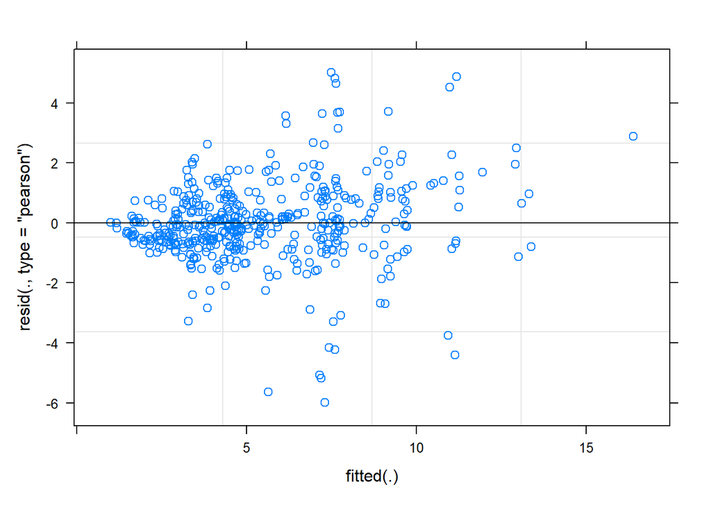

```r
plot(EWMabund_nat_lake_ENSpie)
```

```r
CLPabund_nat_lake_ENSpie <- lmer(simpsons_div_nat~potcri_early_vegdfoc+ (1|DOW) + (1| year), data = summer_surveys[potcri_early_vegdfoc > 0 & !is.na(Secchi_m)])
summary(CLPabund_nat_lake_ENSpie)
```

```
## Linear mixed model fit by REML. t-tests use Satterthwaite's method [
## lmerModLmerTest]
## Formula: simpsons_div_nat ~ potcri_early_vegdfoc + (1 | DOW) + (1 | year)
##    Data: summer_surveys[potcri_early_vegdfoc > 0 & !is.na(Secchi_m)]
##
## REML criterion at convergence: 1295.5
##
## Scaled residuals:
##     Min      1Q  Median      3Q     Max
## -3.7218 -0.4862 -0.0816  0.4453  3.9831
##
## Random effects:
##  Groups   Name        Variance Std.Dev.
##  DOW      (Intercept) 5.47012  2.3388
##  year     (Intercept) 0.03468  0.1862
##  Residual             1.41919  1.1913
## Number of obs: 338, groups:  DOW, 89; year, 18
##
## Fixed effects:
##                      Estimate Std. Error       df t value Pr(>|t|)
## (Intercept)            5.0936     0.3255 107.2168  15.650   <2e-16 ***
## potcri_early_vegdfoc  -0.6509     0.3688 187.0651  -1.765   0.0792 .
## ---
## Signif. codes:  0 '***' 0.001 '**' 0.01 '*' 0.05 '.' 0.1 ' ' 1
##
## Correlation of Fixed Effects:
##             (Intr)
## ptcr_rly_vg -0.557
```

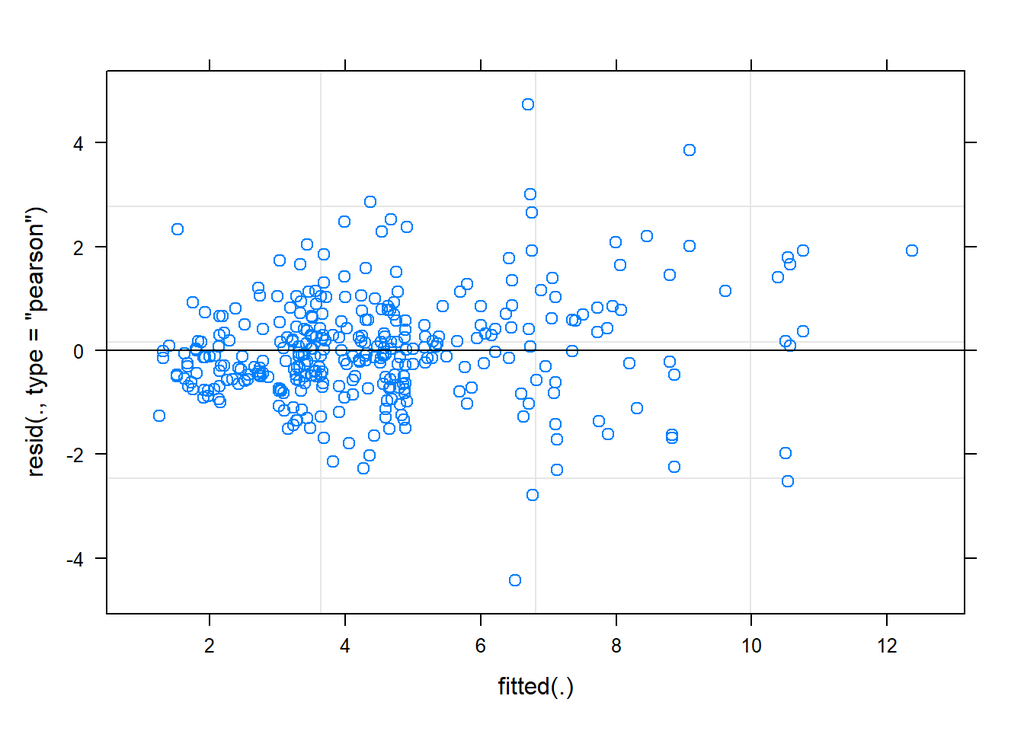

```r
plot(CLPabund_nat_lake_ENSpie)
```

```r
#Richness
EWMabund_nat_lake_richness <- glmer(nat_richness~myrspi_summer_vegdfoc+ (1|DOW) + (1| year), data = summer_surveys[myrspi_summer_vegdfoc > 0 ], family = poisson())
summary(EWMabund_nat_lake_richness)
```

```
## Generalized linear mixed model fit by maximum likelihood (Laplace
##   Approximation) [glmerMod]
##  Family: poisson  ( log )
## Formula: nat_richness ~ myrspi_summer_vegdfoc + (1 | DOW) + (1 | year)
##    Data: summer_surveys[myrspi_summer_vegdfoc > 0]
##
##      AIC      BIC   logLik deviance df.resid
##   2854.0   2870.6  -1423.0   2846.0      473
##
## Scaled residuals:
##     Min      1Q  Median      3Q     Max
## -3.8802 -0.4737 -0.0104  0.4058  3.9465
##
## Random effects:
##  Groups Name        Variance Std.Dev.
##  DOW    (Intercept) 0.295617 0.54371
##  year   (Intercept) 0.003591 0.05993
## Number of obs: 477, groups:  DOW, 137; year, 18
##
## Fixed effects:
##                       Estimate Std. Error z value Pr(>|z|)
## (Intercept)            2.53322    0.05856  43.257  < 2e-16 ***
## myrspi_summer_vegdfoc -0.27031    0.07575  -3.568 0.000359 ***
## ---
## Signif. codes:  0 '***' 0.001 '**' 0.01 '*' 0.05 '.' 0.1 ' ' 1
##
## Correlation of Fixed Effects:
##             (Intr)
## myrsp_smmr_ -0.407
```

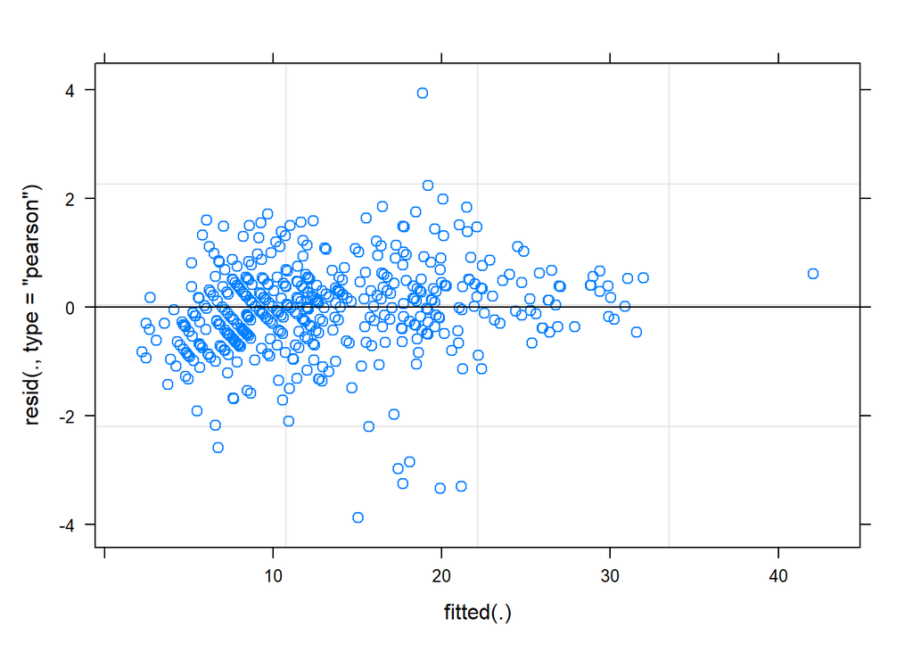

```r
plot(EWMabund_nat_lake_richness)
```

```r
CLPabund_nat_lake_richness <- glmer(nat_richness~potcri_early_vegdfoc+ (1|DOW) + (1| year), data = summer_surveys[potcri_early_vegdfoc > 0 ] , family = poisson())
summary(CLPabund_nat_lake_richness)
```

```
## Generalized linear mixed model fit by maximum likelihood (Laplace
##   Approximation) [glmerMod]
##  Family: poisson  ( log )
## Formula: nat_richness ~ potcri_early_vegdfoc + (1 | DOW) + (1 | year)
##    Data: summer_surveys[potcri_early_vegdfoc > 0]
##
##      AIC      BIC   logLik deviance df.resid
##   1936.8   1952.4   -964.4   1928.8      360
##
## Scaled residuals:
##     Min      1Q  Median      3Q     Max
## -2.8580 -0.4689  0.0093  0.4471  3.5254
##
## Random effects:
##  Groups Name        Variance Std.Dev.
##  DOW    (Intercept) 0.259931 0.50983
##  year   (Intercept) 0.001787 0.04227
## Number of obs: 364, groups:  DOW, 91; year, 18
##
## Fixed effects:
##                      Estimate Std. Error z value Pr(>|z|)
## (Intercept)           2.37291    0.07733  30.687   <2e-16 ***
## potcri_early_vegdfoc -0.23553    0.09701  -2.428   0.0152 *
## ---
## Signif. codes:  0 '***' 0.001 '**' 0.01 '*' 0.05 '.' 0.1 ' ' 1
##
## Correlation of Fixed Effects:
##             (Intr)
## ptcr_rly_vg -0.623
```

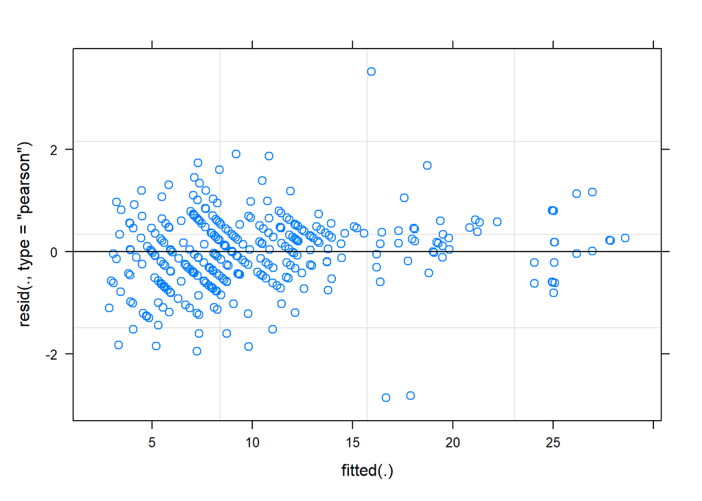

```r
plot(CLPabund_nat_lake_richness)
```

```r
# Evenness
#EWM Abund
EWMabund_nat_lake_evenness<- glmer(nat_evenness~myrspi_summer_vegdfoc+ (1|DOW) + (1| year), data = summer_surveys[myrspi_summer_vegdfoc > 0], family = binomial())
```

```
## boundary (singular) fit: see help('isSingular')
```

```r
summary(EWMabund_nat_lake_evenness)
```

```
## Generalized linear mixed model fit by maximum likelihood (Laplace
##   Approximation) [glmerMod]
##  Family: binomial  ( logit )
## Formula: nat_evenness ~ myrspi_summer_vegdfoc + (1 | DOW) + (1 | year)
##    Data: summer_surveys[myrspi_summer_vegdfoc > 0]
##
##      AIC      BIC   logLik deviance df.resid
##    578.6    595.2   -285.3    570.6      471
##
## Scaled residuals:
##     Min      1Q  Median      3Q     Max
## -0.3481  0.1130  0.2976  0.5145  1.6467
##
## Random effects:
##  Groups Name        Variance Std.Dev.
##  DOW    (Intercept) 0        0
##  year   (Intercept) 0        0
## Number of obs: 475, groups:  DOW, 137; year, 18
##
## Fixed effects:
##                       Estimate Std. Error z value Pr(>|z|)
## (Intercept)            -1.0708     0.1651  -6.484 8.91e-11 ***
## myrspi_summer_vegdfoc   0.5274     0.3782   1.395    0.163
## ---
## Signif. codes:  0 '***' 0.001 '**' 0.01 '*' 0.05 '.' 0.1 ' ' 1
##
## Correlation of Fixed Effects:
##             (Intr)
## myrsp_smmr_ -0.790
## optimizer (Nelder_Mead) convergence code: 0 (OK)
## boundary (singular) fit: see help('isSingular')
```

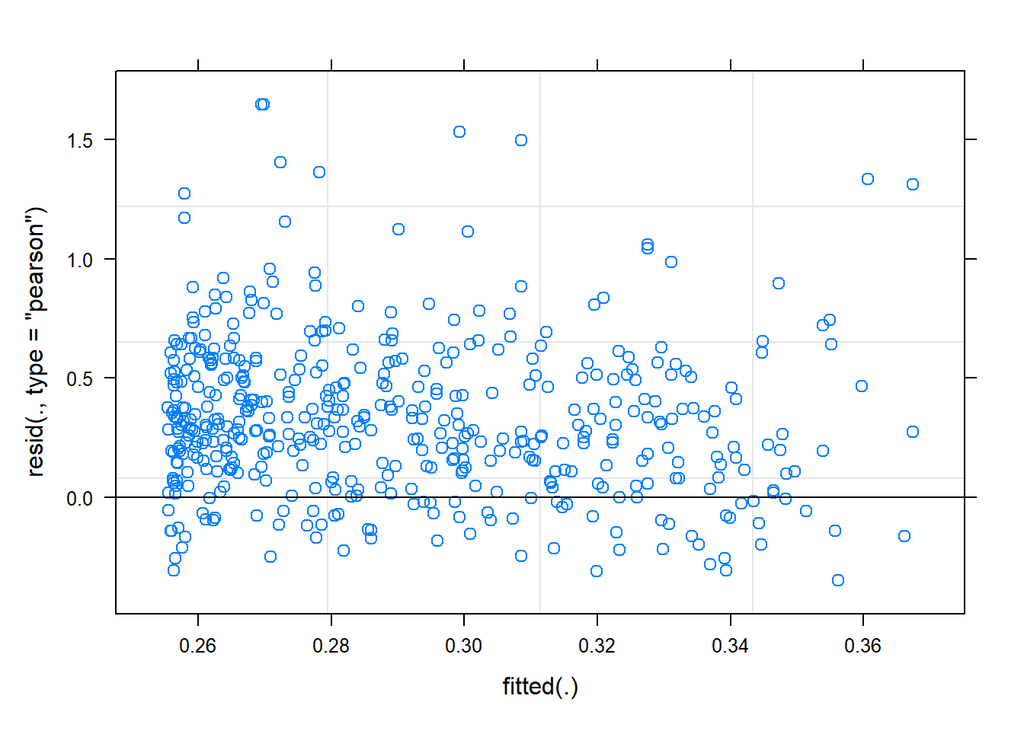

```r
plot(EWMabund_nat_lake_evenness)
```

```r
#CLP Abund
CLPabund_nat_lake_evenness <- glmer(nat_evenness~potcri_early_vegdfoc+ (1|DOW) + (1| year), data = summer_surveys[potcri_early_vegdfoc > 0 ], family = binomial())
```

```
## boundary (singular) fit: see help('isSingular')
```

```r
summary(CLPabund_nat_lake_evenness)
```

```
## Generalized linear mixed model fit by maximum likelihood (Laplace
##   Approximation) [glmerMod]
##  Family: binomial  ( logit )
## Formula: nat_evenness ~ potcri_early_vegdfoc + (1 | DOW) + (1 | year)
##    Data: summer_surveys[potcri_early_vegdfoc > 0]
##
##      AIC      BIC   logLik deviance df.resid
##    479.6    495.2   -235.8    471.6      359
##
## Scaled residuals:
##      Min       1Q   Median       3Q      Max
## -0.51298 -0.06198  0.10949  0.31152  1.25535
##
## Random effects:
##  Groups Name        Variance Std.Dev.
##  DOW    (Intercept) 0.2903   0.5388
##  year   (Intercept) 0.0000   0.0000
## Number of obs: 363, groups:  DOW, 91; year, 18
##
## Fixed effects:
##                      Estimate Std. Error z value Pr(>|z|)
## (Intercept)           -0.9525     0.2552  -3.732  0.00019 ***
## potcri_early_vegdfoc   0.8554     0.4133   2.070  0.03850 *
## ---
## Signif. codes:  0 '***' 0.001 '**' 0.01 '*' 0.05 '.' 0.1 ' ' 1
##
## Correlation of Fixed Effects:
##             (Intr)
## ptcr_rly_vg -0.842
## optimizer (Nelder_Mead) convergence code: 0 (OK)
## boundary (singular) fit: see help('isSingular')
```

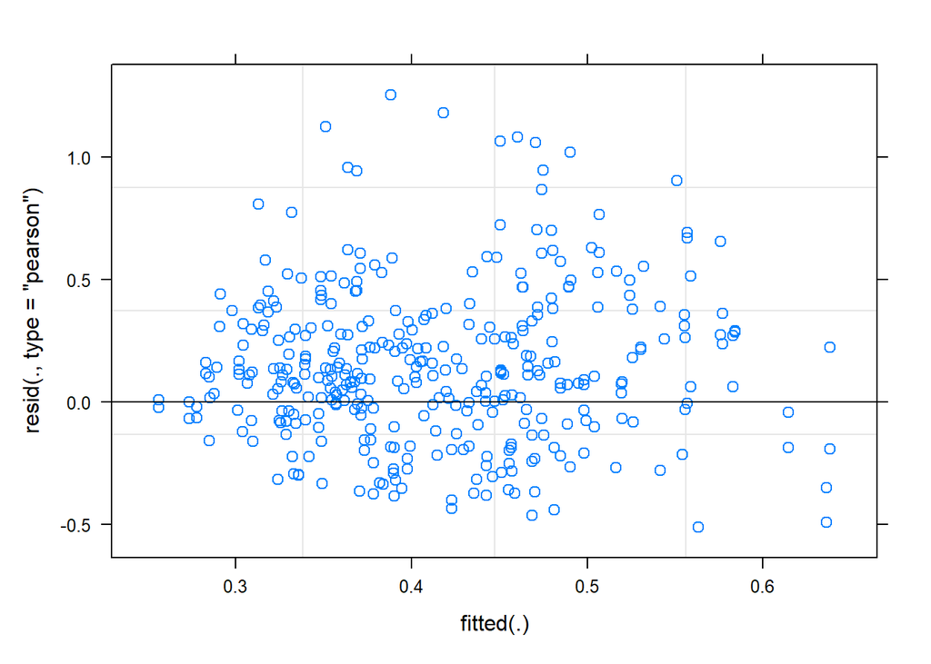

```r
plot(CLPabund_nat_lake_evenness)
```

```r
# Compile Model Tables ----------------------------------------------------

summary(D_pa_clp_lake)$coef
```

```
##                               Estimate Std. Error       df   t value
## (Intercept)                  4.3737021  0.3840553 212.6558 11.388210
## potcri_early_vegdfoc > 0TRUE 0.4361093  0.2977997 369.9028  1.464439
##                                  Pr(>|t|)
## (Intercept)                  9.070370e-24
## potcri_early_vegdfoc > 0TRUE 1.439235e-01
```

```r
summary(R_pa_clp_lake)$coef
```

```
##                                  Estimate Std. Error      z value      Pr(>|z|)
## (Intercept)                  2.2438438483 0.09775929 22.952743249 1.383396e-116
## potcri_early_vegdfoc > 0TRUE 0.0002847844 0.08398329  0.003390966  9.972944e-01
```

```r
summary(E_pa_clp_lake)$coef
```

```
##                                Estimate Std. Error    z value  Pr(>|z|)
## (Intercept)                  -0.1377663  0.3587695 -0.3839967 0.7009809
## potcri_early_vegdfoc > 0TRUE -0.3770861  0.3740337 -1.0081606 0.3133774
```

```r
inv_mods <- rbindlist(
  list(data.table(summary(D_pa_ewm_lake)$coef, keep.rownames = T),
       data.table(summary(R_pa_ewm_lake)$coef, keep.rownames = T),
       data.table(summary(E_pa_ewm_lake)$coef, keep.rownames = T),
       data.table(summary(D_pa_clp_lake)$coef, keep.rownames = T),
       data.table(summary(R_pa_clp_lake)$coef, keep.rownames = T),
       data.table(summary(E_pa_clp_lake)$coef, keep.rownames = T),
       data.table(summary(EWMabund_nat_lake_ENSpie)$coef, keep.rownames = T),
       data.table(summary(EWMabund_nat_lake_richness)$coef, keep.rownames = T),
       data.table(summary(EWMabund_nat_lake_evenness)$coef, keep.rownames = T),
       data.table(summary(CLPabund_nat_lake_ENSpie)$coef, keep.rownames = T),
       data.table(summary(CLPabund_nat_lake_richness)$coef, keep.rownames = T),
       data.table(summary(CLPabund_nat_lake_evenness)$coef, keep.rownames = T)
  ), fill = TRUE
)

inv_mods[ , species := rep(c(rep("Mspi", 6),rep("Pcri", 6)), 2) ]
inv_mods[ , response := rep(c(rep("Div", 2),rep("Rich", 2), rep("Even", 2)), 4) ]

inv_mods[response == "Rich", Estimate_backtrans := exp(Estimate)]
inv_mods[response == "Even", Estimate_backtrans := plogis(Estimate)]

inv_mods[response == "Rich", confint_lwr := exp(Estimate - 1.96*`Std. Error`)]
inv_mods[response == "Rich", confint_upr := exp(Estimate + 1.96*`Std. Error`)]

inv_mods[response == "Even", confint_lwr := plogis(Estimate - 1.96*`Std. Error`)]
inv_mods[response == "Even", confint_upr := plogis(Estimate + 1.96*`Std. Error`)]

inv_mods[response == "Div", confint_lwr := Estimate - 1.96*`Std. Error`]
inv_mods[response == "Div", confint_upr := Estimate + 1.96*`Std. Error`]

# fwrite(inv_mods, file = "data&scripts/data/output/obs_comp_mods.csv")
```

One crummy thing about using mixed effects models is that they tell me it’s challenging to make model predictions of confidence intervals that do a good job of incorporating the fixed and random effects variances (or something like that). Since thats the case, we’re just going to skip that, and instead we’ll just plot the estimates, and denote which have significant effects. The code to model confidence intervals is given in the first prediction, both via bootMer and mertools:predictInterval.

### Lake Level - Results Viz

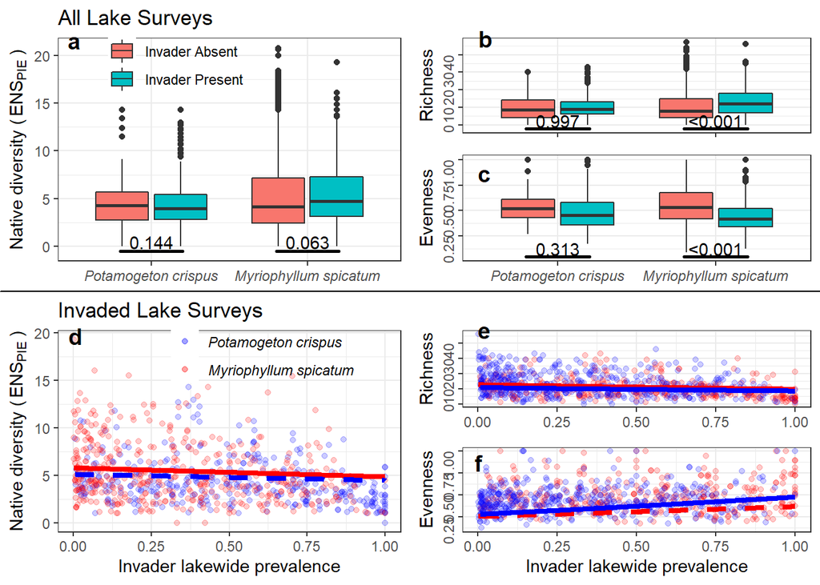

```r
# visualizations with test results ---------------------------------------------------------

#new data spanning abund to predict models from
# EWM
newdat1<-data.frame(myrspi_summer_vegdfoc = seq(min(summer_surveys[myrspi_summer_vegdfoc > 0 , myrspi_summer_vegdfoc]), max(summer_surveys[myrspi_summer_vegdfoc > 0 , myrspi_summer_vegdfoc]), length.out = nrow(summer_surveys[myrspi_summer_vegdfoc > 0 ])),
                    year = summer_surveys[myrspi_summer_vegdfoc > 0 , year],
                    DOW = summer_surveys[myrspi_summer_vegdfoc > 0 , DOW])
# CLP
newdat2<-data.frame(potcri_early_vegdfoc = seq(min(summer_surveys[potcri_early_vegdfoc > 0 , potcri_early_vegdfoc]), max(summer_surveys[potcri_early_vegdfoc > 0 , potcri_early_vegdfoc]), length.out = nrow(summer_surveys[potcri_early_vegdfoc > 0 ])),
                    year = summer_surveys[potcri_early_vegdfoc > 0 , year],
                    DOW = summer_surveys[potcri_early_vegdfoc > 0 , DOW])

# ENSPie ~ Abund:
#EWM
newdat1$fittedD <- predict(EWMabund_nat_lake_ENSpie, newdat1, re.form = NA)

  # #mertools() conf ints, from an estimation process I dont understand :)
  # preds <- predictInterval(EWMabund_nat_lake_ENSpie, newdat1, which = "fixed", n.sims = 9999, include.resid.var = F)
  # newdat1 <- cbind(newdat1,preds)
  #
  # #fitted confints from bootstrap -- this is the "goldest" standard (aparrently these are all challenging appproximations)
  # boot_pred1 <- bootMer(EWMabund_nat_lake_ENSpie, predict, nsim = 1000, re.form = NA)
  # str(boot_pred1
  # newdat1$lci <- apply(boot_pred1$t, 2, quantile, 0.025)
  # newdat1$uci <- apply(boot_pred1$t, 2, quantile, 0.975)

#CLP
newdat2$fittedD <- predict(CLPabund_nat_lake_ENSpie, newdat2, re.form = NA)

##Richness~Abund:
#EWM
newdat1$fittedR <- exp(predict(EWMabund_nat_lake_richness, newdat1, re.form = NA))
#CLP
newdat2$fittedR <- exp(predict(CLPabund_nat_lake_richness, newdat2, re.form = NA))

#Evenness~Abund:
#EWM
newdat1$fittedE <- plogis(predict(EWMabund_nat_lake_evenness, newdat1, re.form = NA))
#CLP
newdat2$fittedE <- plogis(predict(CLPabund_nat_lake_evenness, newdat2, re.form = NA))

#Diversity Plot
legend_colors <- c("potcri_early_vegdfoc" = "blue", "myrspi_summer_vegdfoc" = "red")
INV_ENSpie <- ggplot()+
    geom_point(data = summer_surveys[potcri_early_vegdfoc > 0 ],
               aes(potcri_early_vegdfoc, simpsons_div_nat, color = "potcri_early_vegdfoc"),
               alpha = 0.2)+
    geom_point(data = summer_surveys[myrspi_summer_vegdfoc > 0 & is.na(ewm_targeted) ],
               aes(myrspi_summer_vegdfoc, simpsons_div_nat, color = "myrspi_summer_vegdfoc"),
               alpha = 0.2)+
    geom_line(data = newdat1,
              aes(myrspi_summer_vegdfoc,fittedD), color = "red", size = 1.5)+
    # geom_ribbon(data = newdat1, aes(x = myrspi_summer_vegdfoc, ymin=lci, ymax=uci), color = NA , fill = "red", alpha = .15)+
    geom_line(data = newdat2,
              aes(potcri_early_vegdfoc,fittedD), color = "blue", size = 1.5, lty = 2)+
    # geom_ribbon(data = newdat2, aes(x = potcri_early_vegdfoc, ymin=lwr, ymax=upr), color = NA , fill = "blue", alpha = .15)+
    xlab("Invader lakewide prevalence")+
    ylab(bquote('Native diversity ('~ENS[PIE]~')'))+
    ggtitle("Invaded Lake Surveys")+
    labs(color = NULL) +
    scale_color_manual(values = legend_colors, labels = c("Potamogeton crispus","Myriophyllum spicatum"))+
    theme_bw()+
    theme(legend.position = c(0.6, 0.9), legend.background = element_blank(), legend.text = element_text(face = "italic"))

#Richness plot:
INV_richness <- ggplot()+
    geom_point(data = summer_surveys[potcri_early_vegdfoc > 0 ],
               aes(potcri_early_vegdfoc, nat_richness),
               alpha = 0.2, color = "red")+
    geom_point(data = summer_surveys[myrspi_summer_vegdfoc > 0  ],
               aes(myrspi_summer_vegdfoc, nat_richness),
               alpha = 0.2, color = "blue")+
    geom_line(data = newdat1,
              aes(myrspi_summer_vegdfoc,fittedR), color = "red", size = 1.5)+
    geom_line(data = newdat2,
              aes(potcri_early_vegdfoc,fittedR), color = "blue", size = 1.5)+
    xlab(NULL)+
    ylab("Richness")+
    ggtitle("")+
    theme_bw()+
    theme(axis.text.y.left = element_text(angle = 90))

INV_evenness <- ggplot()+
    geom_point(data = summer_surveys[potcri_early_vegdfoc > 0 & is.na(clp_targeted)],
               aes(potcri_early_vegdfoc, simpsons_div_nat/nat_richness),
               alpha = 0.2, color = "red")+
    geom_point(data = summer_surveys[myrspi_summer_vegdfoc > 0 & is.na(ewm_targeted) ],
               aes(myrspi_summer_vegdfoc, simpsons_div_nat/nat_richness),
               alpha = 0.2, color = "blue")+
    geom_line(data = newdat1,
              aes(myrspi_summer_vegdfoc,fittedE), color = "red", size = 1.5, lty = 2)+
    geom_line(data = newdat2,
              aes(potcri_early_vegdfoc,fittedE), color = "blue", size = 1.5)+
    xlab("Invader lakewide prevalence")+
    ylab("Evenness")+
    theme_bw()+
    theme(axis.text.y.left = element_text(angle = 90))

box1 <- box1+
  geom_signif(
    y_position = c(-0.5, -0.5), xmin = c(0.8, 1.8), xmax = c(1.2, 2.2),
    annotation = c("0.144", "0.063"), tip_length = 0, size = 1
  )

box2 <- box2+
  geom_signif(
    y_position = c(-2, -2), xmin = c(0.8, 1.8), xmax = c(1.2, 2.2),
    annotation = c("0.997", "<0.001"), tip_length = 0, size = 1
  )

box3 <- box3+
  geom_signif(
    y_position = c(0.05, 0.05), xmin = c(0.8, 1.8), xmax = c(1.2, 2.2),
    annotation = c("0.313", "<0.001"), tip_length = 0, size = 1
  )

  # remake Figure 1 with predictions from models -----------------------------

  boxps <- ggarrange(box1, ggarrange(box2, box3, ncol = 1,
                                     labels = c("b","c"),
                                     label.x = c(0.15,0.15),
                                     label.y = c(0.85,0.93)),
                     labels = c("a", ""),
                     label.x = 0.15,
                     label.y = 0.92)
  abundps <- ggarrange(INV_ENSpie, ggarrange(INV_richness, INV_evenness,
                                             ncol = 1,
                                             labels = c("e","f"),
                                             label.x = c(0.15,0.15),
                                             label.y = c(0.86,0.95)),
                       labels = c("d",""),
                       label.x = 0.15,
                       label.y = 0.91)+
    border(color = "black", size = 0.8, linetype = NULL)
  ggarrange(boxps,abundps, ncol = 1)
```

```r
  # Clean up Workspace:
  # rm(abundps, box1, box2, box3, boxplot_data, boxps, CLP_ENSpie, CLP_evenness, CLP_nat_lake_mod, CLP_richness, CLPabund_nat_lake_ENSpie, CLPabund_nat_lake_evenness, CLPabund_nat_lake_richness)
```

### Lake Level - Discuss:

It’s surprising to me that these trends are significant, but I suppose that is owed partly to the large sample sizes we’ve got. In addition, it should be noted that not all of our model diagnostics were very satisfactory (check out the binomial glmer for evenness.

### Point Level - Viz

```r
# viz point level rake abund --------------------------------------------------

#ENSpie
names(plants_rakeabund_wide) <- names(clean_names(plants_rakeabund_wide))

point_abund_ENSpie <- ggplot()+
  # geom_boxplot(aes(group = potamogeton_crispus))+
  stat_smooth(data = plants_rakeabund_wide[potamogeton_crispus> 0],
              aes(potamogeton_crispus, simpsons_div_nat, group = survey_id),
              method = "lm", geom = 'line', se =F, color = "blue", alpha = .04)+
  geom_smooth(data = plants_rakeabund_wide[potamogeton_crispus> 0],
              aes(potamogeton_crispus, simpsons_div_nat),
              method = "lm", color = "blue", size = 1.5)+
  ylab(bquote('Native diversity ('~ENS[PIE]~')'))+
  # theme(legend.position = "none")+
  stat_smooth(data = plants_rakeabund_wide[myriophyllum_spicatum> 0],
              aes(myriophyllum_spicatum, simpsons_div_nat, group = survey_id),
              method = "lm", geom = 'line', se = F, color = "red", alpha = .04)+
  geom_smooth(data = plants_rakeabund_wide[myriophyllum_spicatum> 0],
              aes(myriophyllum_spicatum, simpsons_div_nat),
              method = "lm", color = "red", size = 1.5)+
  theme_bw()+
  xlab("Relative Abundance of Invader")+
  ggtitle("INVADED SAMPLES")+
  scale_color_manual(values = legend_colors, labels = c("Potamogeton crispus","Myriophyllum spicatum"))+
  theme_bw()+
  theme(legend.position = c(0.6, 0.9), legend.background = element_blank(), legend.text = element_text(face = "italic"))


#Richness
point_abund_richness <- ggplot()+
  # geom_boxplot(aes(group = potamogeton_crispus))+
  stat_smooth(data = plants_rakeabund_wide[potamogeton_crispus> 0],
              aes(potamogeton_crispus, nat_richness, group = survey_id),
              method = "lm", geom = 'line', se = F, color = "blue", alpha = .04)+
  geom_smooth(data = plants_rakeabund_wide[potamogeton_crispus> 0],
              aes(potamogeton_crispus, nat_richness),
              method = "lm", color = "blue", size = 1.5)+
  ylab("Richness")+
  # theme(legend.position = "none")+
  stat_smooth(data = plants_rakeabund_wide[myriophyllum_spicatum> 0],
              aes(myriophyllum_spicatum, nat_richness, group = survey_id),
              method = "lm", geom = 'line', se = F, color = "red", alpha = .04)+
  geom_smooth(data = plants_rakeabund_wide[myriophyllum_spicatum> 0],
              aes(myriophyllum_spicatum, nat_richness),
              method = "lm", color = "red", size = 1.5)+
  theme_bw()+
  xlab("Relative Abundance of Invader")+
  scale_y_log10()+
  scale_color_manual(values = legend_colors, labels = c("Potamogeton crispus","Myriophyllum spicatum"))+
  theme_bw()+
  ggtitle("")+
  theme(legend.position = c(0.6, 0.9), legend.background = element_blank(), legend.text = element_text(face = "italic"))


#evenness?
point_abund_evenness <- ggplot()+
  # geom_boxplot(aes(group = potamogeton_crispus))+
  stat_smooth(data = plants_rakeabund_wide[potamogeton_crispus> 0],
              aes(potamogeton_crispus, simpsons_div_nat/nat_richness, group = survey_id),
              method = "lm", geom = 'line', se = F, color = "blue", alpha = .04)+
  geom_smooth(data = plants_rakeabund_wide[potamogeton_crispus> 0],
              aes(potamogeton_crispus, simpsons_div_nat/nat_richness),
              method = "lm", color = "blue", size = 1.5)+
  ylab("Evenness")+
  # theme(legend.position = "none")+
  stat_smooth(data = plants_rakeabund_wide[myriophyllum_spicatum> 0],
              aes(myriophyllum_spicatum, simpsons_div_nat/nat_richness, group = survey_id),
              method = "lm", geom = 'line', se = F, color = "red", alpha = .04)+
  geom_smooth(data = plants_rakeabund_wide[myriophyllum_spicatum> 0],
              aes(myriophyllum_spicatum, simpsons_div_nat/nat_richness),
              method = "lm", color = "red", size = 1.5)+
  theme_bw()+
  xlab("Relative Abundance of Invader")+
  scale_y_log10()+
  scale_color_manual(values = legend_colors, labels = c("Potamogeton crispus","Myriophyllum spicatum"))+
  theme_bw()+
  theme(legend.position = c(0.6, 0.9), legend.background = element_blank(), legend.text = element_text(face = "italic"))

point_abunds <- ggarrange(point_abund_ENSpie, ggarrange(point_abund_richness, point_abund_evenness,
                                                        ncol = 1,
                                                        labels = c("e","f"),
                                                        label.x = c(0.15,0.15),
                                                        label.y = c(0.86,0.95)),
                          labels = c("d",""),
                          label.x = 0.15,
                          label.y = 0.91)+  border(color = "black", size = 0.8, linetype = NULL)
# viz point level p/a (only rake data) ----------------------------------

#make a boxplotting dataset
point_boxes_dat <- melt(
  plants_rakeabund_wide[,.(point_id, nat_div = simpsons_div_nat, nat_richness, nat_evenness = simpsons_div_nat/nat_richness, inv_pot_cri = potamogeton_crispus > 0, inv_myr_spi = myriophyllum_spicatum > 0), ],
  id.vars = c("point_id", "inv_pot_cri", "inv_myr_spi" ),
  measure.vars = patterns("^nat"),
  variable.name = c("metric"),
  value.name = c("value")

)
point_boxes_dat <- melt(point_boxes_dat,
                        id.vars = c("point_id", "metric", "value" ),
                        measure.vars = patterns("^inv"),
                        variable.name = c("species"),
                        value.name = c("inv.pres")
)

point_boxes_dat[metric == "nat_div" , .N , .(species, inv.pres)  ]
```

```
##        species inv.pres     N
##         <fctr>   <lgcl> <int>
## 1: inv_pot_cri    FALSE 60591
## 2: inv_pot_cri     TRUE 21315
## 3: inv_myr_spi    FALSE 67566
## 4: inv_myr_spi     TRUE 14340
```

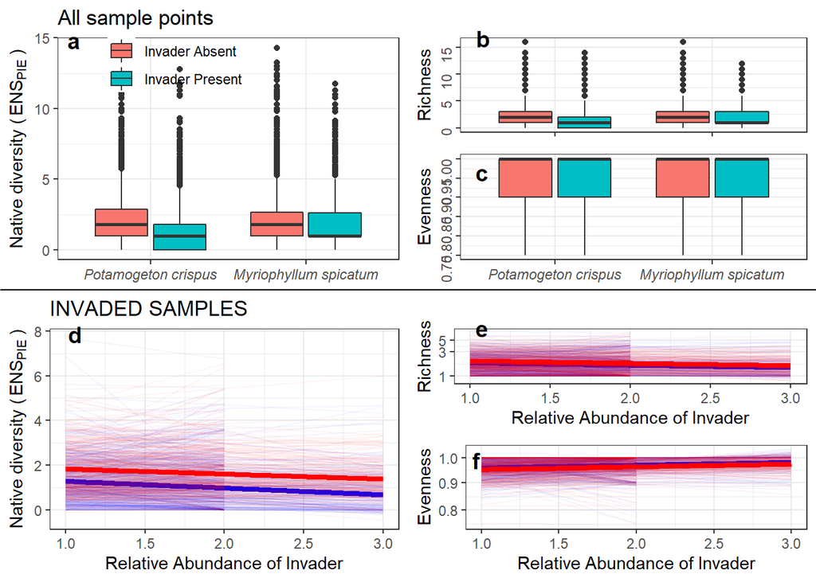

```r
box1p <- ggplot(data = point_boxes_dat[metric == "nat_div"], aes(species, value, fill = inv.pres))+
  geom_boxplot()+
  scale_x_discrete(limits= c("inv_pot_cri", "inv_myr_spi"),labels=c("Potamogeton crispus","Myriophyllum spicatum"))+
  scale_fill_discrete(limits= c("FALSE", "TRUE"),labels=c("Invader Absent","Invader Present"))+
  xlab(NULL)+
  ylab(bquote('Native diversity ('~ENS[PIE]~')'))+
  theme_bw()+
  ggtitle("All sample points")+
  theme(axis.text.x = element_text( face = "italic"), legend.position = c(.35,.9), legend.title = element_blank(), legend.background = element_blank())

box2p <- ggplot(data = point_boxes_dat[metric == "nat_richness"], aes(species, value, fill = inv.pres))+
  geom_boxplot()+
  scale_x_discrete(limits= c("inv_pot_cri", "inv_myr_spi"),labels=c("Potamogeton crispus","Myriophyllum spicatum"))+
  xlab(NULL)+
  ylab("Richness")+
  theme_bw()+
  theme(axis.text.x = element_blank(), legend.position = "none")+
  ggtitle("")+
  theme(axis.text.y.left = element_text(angle = 90))

box3p <- ggplot(data = point_boxes_dat[metric == "nat_evenness"], aes(species, value, fill = inv.pres))+
  geom_boxplot()+
  scale_x_discrete(limits= c("inv_pot_cri", "inv_myr_spi"),labels=c("Potamogeton crispus","Myriophyllum spicatum"))+
  xlab(NULL)+
  ylab("Evenness")+
  theme_bw()+
  theme(axis.text.x = element_text( face = "italic"), legend.position = "none")+
  theme(axis.text.y.left = element_text(angle = 90))

box1bp <- ggarrange(box2p, box3p, ncol = 1,
          labels = c("b","c"),
          label.x = c(0.15,0.15),
          label.y = c(0.85,0.93))
point_boxpsp <- ggarrange(box1p, box1bp,
                         labels = c("a", ""),
                         label.x = 0.15,
                         label.y = 0.92)

# Figure 2: Compile boxplots and abund plots

ggarrange(point_boxpsp,point_abunds, ncol = 1)
```

### Point Level - Test

This is an important spot to pause and talk a bit about the nuance of these figures (and the tests we’ll write to evaluate the relationships). At the point level, we don’t have any way to connect sample locations across time at least not very many of them. As such, we need to use each survey and consider in our model the influence of the phenology component of the systems members. We do that by modeling a polynomial date effect.

```r
#  test point level rake abund --------------------------------------------

#Div:
D_ab_clp_point <- lmer(simpsons_div_nat~ poly(yday(survey_date), 2)+  potamogeton_crispus+ (1|dow), data = plants_rakeabund_wide[potamogeton_crispus> 0 , ])
summary(D_ab_clp_point)
```

```
## Linear mixed model fit by REML. t-tests use Satterthwaite's method [
## lmerModLmerTest]
## Formula: simpsons_div_nat ~ poly(yday(survey_date), 2) + potamogeton_crispus +
##     (1 | dow)
##    Data: plants_rakeabund_wide[potamogeton_crispus > 0, ]
##
## REML criterion at convergence: 62965
##
## Scaled residuals:
##     Min      1Q  Median      3Q     Max
## -4.2389 -0.5785 -0.1313  0.4773 10.0215
##
## Random effects:
##  Groups   Name        Variance Std.Dev.
##  dow      (Intercept) 0.9102   0.9541
##  Residual             1.0891   1.0436
## Number of obs: 21315, groups:  dow, 183
##
## Fixed effects:
##                               Estimate Std. Error         df t value Pr(>|t|)
## (Intercept)                  1.823e+00  7.553e-02  1.902e+02   24.13   <2e-16
## poly(yday(survey_date), 2)1  3.756e+01  1.315e+00  2.131e+04   28.57   <2e-16
## poly(yday(survey_date), 2)2 -1.764e+01  1.306e+00  2.131e+04  -13.51   <2e-16
## potamogeton_crispus         -2.071e-01  1.205e-02  2.123e+04  -17.19   <2e-16
##
## (Intercept)                 ***
## poly(yday(survey_date), 2)1 ***
## poly(yday(survey_date), 2)2 ***
## potamogeton_crispus         ***
## ---
## Signif. codes:  0 '***' 0.001 '**' 0.01 '*' 0.05 '.' 0.1 ' ' 1
##
## Correlation of Fixed Effects:
##             (Intr) p((_),2)1 p((_),2)2
## ply((_),2)1 -0.068
## ply((_),2)2 -0.021 -0.184
## ptmgtn_crsp -0.225  0.099     0.158
```

```r
D_ab_ewm_point <- lmer(simpsons_div_nat~poly(yday(survey_date), 2)+ myriophyllum_spicatum + (1 | dow ), data = plants_rakeabund_wide[myriophyllum_spicatum> 0] )
summary(D_ab_ewm_point)
```

```
## Linear mixed model fit by REML. t-tests use Satterthwaite's method [
## lmerModLmerTest]
## Formula:
## simpsons_div_nat ~ poly(yday(survey_date), 2) + myriophyllum_spicatum +
##     (1 | dow)
##    Data: plants_rakeabund_wide[myriophyllum_spicatum > 0]
##
## REML criterion at convergence: 47606.5
##
## Scaled residuals:
##     Min      1Q  Median      3Q     Max
## -2.7926 -0.6331 -0.1089  0.4996  6.6478
##
## Random effects:
##  Groups   Name        Variance Std.Dev.
##  dow      (Intercept) 0.6441   0.8026
##  Residual             1.5831   1.2582
## Number of obs: 14340, groups:  dow, 106
##
## Fixed effects:
##                               Estimate Std. Error         df t value Pr(>|t|)
## (Intercept)                  2.023e+00  8.724e-02  1.191e+02  23.194  < 2e-16
## poly(yday(survey_date), 2)1  3.090e+01  1.435e+00  1.433e+04  21.541  < 2e-16
## poly(yday(survey_date), 2)2 -1.023e+01  1.478e+00  1.432e+04  -6.918 4.77e-12
## myriophyllum_spicatum       -1.919e-01  1.754e-02  1.430e+04 -10.944  < 2e-16
##
## (Intercept)                 ***
## poly(yday(survey_date), 2)1 ***
## poly(yday(survey_date), 2)2 ***
## myriophyllum_spicatum       ***
## ---
## Signif. codes:  0 '***' 0.001 '**' 0.01 '*' 0.05 '.' 0.1 ' ' 1
##
## Correlation of Fixed Effects:
##             (Intr) p((_),2)1 p((_),2)2
## ply((_),2)1  0.000
## ply((_),2)2  0.000 -0.007
## myrphyllm_s -0.290 -0.022     0.021
```

```r
#Rich:
R_ab_clp_point <- glmer(nat_richness~ poly(yday(survey_date), 2) + potamogeton_crispus + (1| dow ), data = plants_rakeabund_wide[potamogeton_crispus> 0], family = poisson())
summary(R_ab_clp_point)
```

```
## Generalized linear mixed model fit by maximum likelihood (Laplace
##   Approximation) [glmerMod]
##  Family: poisson  ( log )
## Formula: nat_richness ~ poly(yday(survey_date), 2) + potamogeton_crispus +
##     (1 | dow)
##    Data: plants_rakeabund_wide[potamogeton_crispus > 0]
##
##      AIC      BIC   logLik deviance df.resid
##  53839.0  53878.8 -26914.5  53829.0    21310
##
## Scaled residuals:
##     Min      1Q  Median      3Q     Max
## -2.1900 -0.6915 -0.3126  0.5324 10.8142
##
## Random effects:
##  Groups Name        Variance Std.Dev.
##  dow    (Intercept) 0.5061   0.7114
## Number of obs: 21315, groups:  dow, 183
##
## Fixed effects:
##                              Estimate Std. Error z value Pr(>|z|)
## (Intercept)                   0.44517    0.05720   7.783 7.07e-15 ***
## poly(yday(survey_date), 2)1  39.82548    1.10789  35.947  < 2e-16 ***
## poly(yday(survey_date), 2)2 -22.93862    1.28870 -17.800  < 2e-16 ***
## potamogeton_crispus          -0.21126    0.01184 -17.846  < 2e-16 ***
## ---
## Signif. codes:  0 '***' 0.001 '**' 0.01 '*' 0.05 '.' 0.1 ' ' 1
##
## Correlation of Fixed Effects:
##             (Intr) p((_),2)1 p((_),2)2
## ply((_),2)1 -0.102
## ply((_),2)2 -0.009 -0.246
## ptmgtn_crsp -0.282  0.135     0.119
```

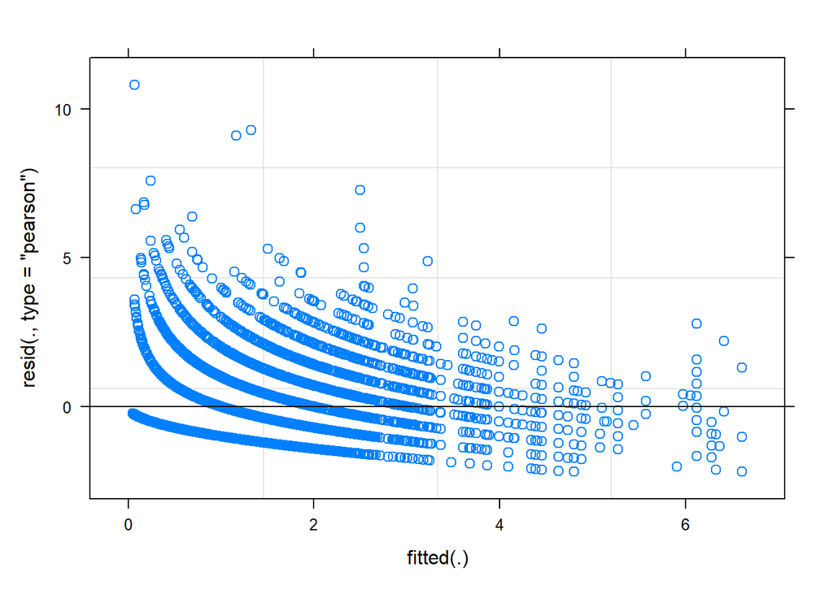

```r
plot(R_ab_clp_point)
```

```r
R_ab_ewm_point <- glmer(nat_richness~ poly(yday(survey_date), 2) + myriophyllum_spicatum+ (1| dow ), data = plants_rakeabund_wide[myriophyllum_spicatum> 0], family = poisson())
summary(R_ab_ewm_point)
```

```
## Generalized linear mixed model fit by maximum likelihood (Laplace
##   Approximation) [glmerMod]
##  Family: poisson  ( log )
## Formula: nat_richness ~ poly(yday(survey_date), 2) + myriophyllum_spicatum +
##     (1 | dow)
##    Data: plants_rakeabund_wide[myriophyllum_spicatum > 0]
##
##      AIC      BIC   logLik deviance df.resid
##  44774.7  44812.5 -22382.3  44764.7    14335
##
## Scaled residuals:
##     Min      1Q  Median      3Q     Max
## -2.0376 -0.7646 -0.1174  0.5485  6.1930
##
## Random effects:
##  Groups Name        Variance Std.Dev.
##  dow    (Intercept) 0.2535   0.5035
## Number of obs: 14340, groups:  dow, 106
##
## Fixed effects:
##                              Estimate Std. Error z value Pr(>|z|)
## (Intercept)                   0.65710    0.05447   12.06   <2e-16 ***
## poly(yday(survey_date), 2)1  24.84486    0.96735   25.68   <2e-16 ***
## poly(yday(survey_date), 2)2 -11.46245    1.01044  -11.34   <2e-16 ***
## myriophyllum_spicatum        -0.12907    0.01096  -11.78   <2e-16 ***
## ---
## Signif. codes:  0 '***' 0.001 '**' 0.01 '*' 0.05 '.' 0.1 ' ' 1
##
## Correlation of Fixed Effects:
##             (Intr) p((_),2)1 p((_),2)2
## ply((_),2)1 -0.028
## ply((_),2)2  0.023 -0.248
## myrphyllm_s -0.282  0.006    -0.024
```

```r
#evenness
E_ab_clp_point <- lmer(nat_evenness ~ poly(yday(survey_date), 2) + potamogeton_crispus + (1 | dow ), data = plants_rakeabund_wide[potamogeton_crispus> 0])
summary(E_ab_clp_point)
```

```
## Linear mixed model fit by REML. t-tests use Satterthwaite's method [
## lmerModLmerTest]
## Formula: nat_evenness ~ poly(yday(survey_date), 2) + potamogeton_crispus +
##     (1 | dow)
##    Data: plants_rakeabund_wide[potamogeton_crispus > 0]
##
## REML criterion at convergence: -36736.3
##
## Scaled residuals:
##     Min      1Q  Median      3Q     Max
## -4.3329 -0.6612  0.2997  0.6859  2.0237
##
## Random effects:
##  Groups   Name        Variance  Std.Dev.
##  dow      (Intercept) 0.0004686 0.02165
##  Residual             0.0029001 0.05385
## Number of obs: 12344, groups:  dow, 183
##
## Fixed effects:
##                               Estimate Std. Error         df t value Pr(>|t|)
## (Intercept)                  9.517e-01  2.233e-03  2.966e+02 426.116  < 2e-16
## poly(yday(survey_date), 2)1 -1.289e+00  9.083e-02  1.079e+04 -14.194  < 2e-16
## poly(yday(survey_date), 2)2  3.562e-01  1.010e-01  1.075e+04   3.527 0.000423
## potamogeton_crispus          9.982e-03  8.706e-04  1.231e+04  11.466  < 2e-16
##
## (Intercept)                 ***
## poly(yday(survey_date), 2)1 ***
## poly(yday(survey_date), 2)2 ***
## potamogeton_crispus         ***
## ---
## Signif. codes:  0 '***' 0.001 '**' 0.01 '*' 0.05 '.' 0.1 ' ' 1
##
## Correlation of Fixed Effects:
##             (Intr) p((_),2)1 p((_),2)2
## ply((_),2)1 -0.182
## ply((_),2)2 -0.015 -0.186
## ptmgtn_crsp -0.540  0.138     0.127
```

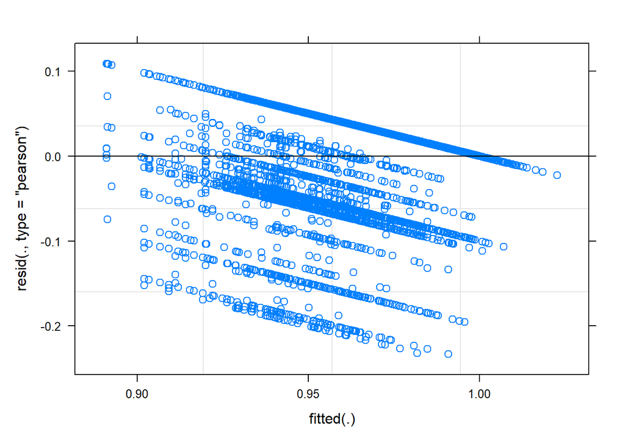

```r
plot(E_ab_clp_point)
```

```r
E_ab_ewm_point <- lmer(nat_evenness~ poly(yday(survey_date), 2) + myriophyllum_spicatum + (1|dow ), data = plants_rakeabund_wide[myriophyllum_spicatum> 0])

summary(E_ab_ewm_point)
```

```
## Linear mixed model fit by REML. t-tests use Satterthwaite's method [
## lmerModLmerTest]
## Formula: nat_evenness ~ poly(yday(survey_date), 2) + myriophyllum_spicatum +
##     (1 | dow)
##    Data: plants_rakeabund_wide[myriophyllum_spicatum > 0]
##
## REML criterion at convergence: -33046.1
##
## Scaled residuals:
##     Min      1Q  Median      3Q     Max
## -4.2491 -0.5946  0.3240  0.6772  2.0725
##
## Random effects:
##  Groups   Name        Variance  Std.Dev.
##  dow      (Intercept) 0.0006542 0.02558
##  Residual             0.0032273 0.05681
## Number of obs: 11494, groups:  dow, 103
##
## Fixed effects:
##                               Estimate Std. Error         df t value Pr(>|t|)
## (Intercept)                  9.427e-01  3.094e-03  1.225e+02 304.654  < 2e-16
## poly(yday(survey_date), 2)1 -1.061e+00  7.399e-02  1.138e+04 -14.336  < 2e-16
## poly(yday(survey_date), 2)2  3.735e-01  7.600e-02  1.120e+04   4.915 9.02e-07
## myriophyllum_spicatum        1.021e-02  8.968e-04  1.149e+04  11.381  < 2e-16
##
## (Intercept)                 ***
## poly(yday(survey_date), 2)1 ***
## poly(yday(survey_date), 2)2 ***
## myriophyllum_spicatum       ***
## ---
## Signif. codes:  0 '***' 0.001 '**' 0.01 '*' 0.05 '.' 0.1 ' ' 1
##
## Correlation of Fixed Effects:
##             (Intr) p((_),2)1 p((_),2)2
## ply((_),2)1 -0.017
## ply((_),2)2  0.008 -0.070
## myrphyllm_s -0.420 -0.012     0.009
```

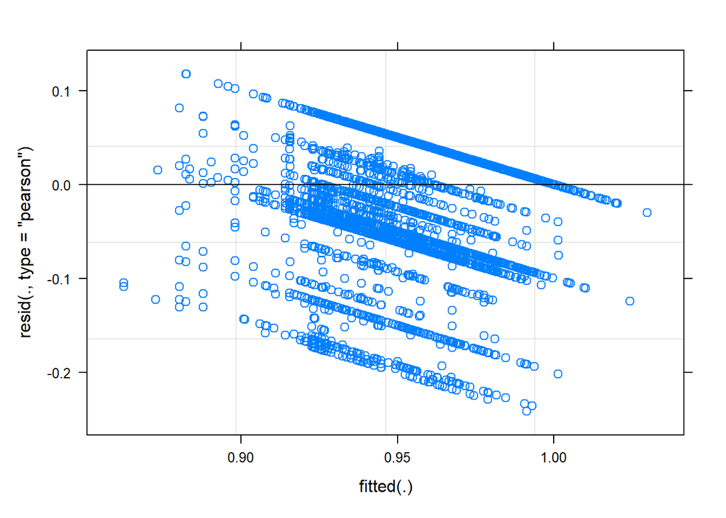

```r
plot(E_ab_ewm_point)
```

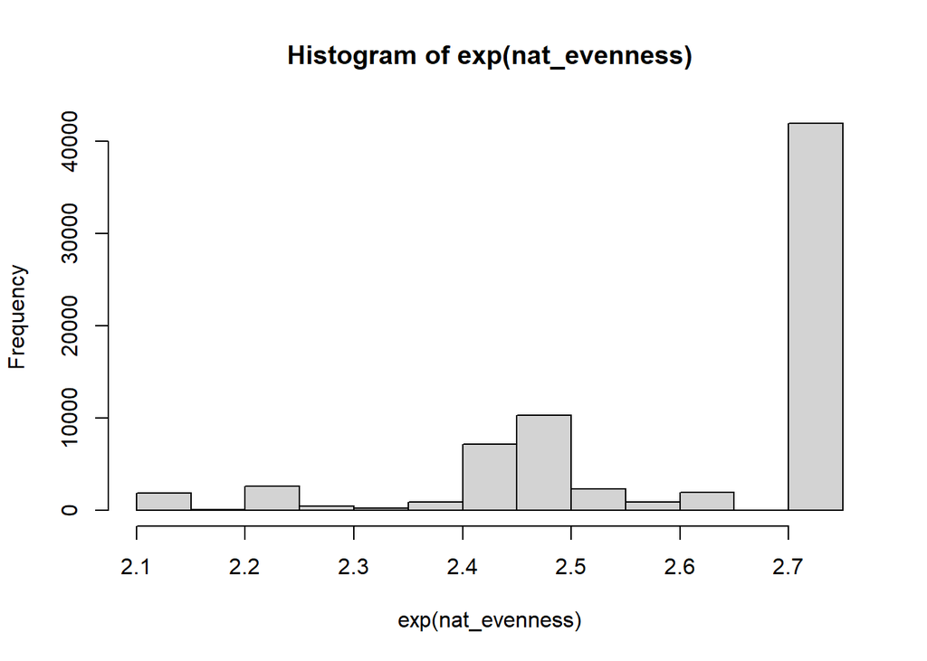

```
## $breaks
##  [1] 2.10 2.15 2.20 2.25 2.30 2.35 2.40 2.45 2.50 2.55 2.60 2.65 2.70 2.75
##
## $counts
##  [1]  1872    91  2618   441   248   887  7190 10324  2338   895  1986    18
## [13] 41873
##
## $density
##  [1]  0.528955511  0.025713115  0.739746542  0.124609712  0.070075303
##  [6]  0.250632232  2.031618655  2.917167036  0.660629265  0.252892725
## [11]  0.561167545  0.005086111 11.831706249
##
## $mids
##  [1] 2.125 2.175 2.225 2.275 2.325 2.375 2.425 2.475 2.525 2.575 2.625 2.675
## [13] 2.725
##
## $xname
## [1] "exp(nat_evenness)"
##
## $equidist
## [1] TRUE
##
## attr(,"class")
## [1] "histogram"
```

```r
plants_rakeabund_wide[ , hist(exp(nat_evenness)) , ]
```

```r
# point level presence/abs ------------------------------------------------
#Div:
D_pa_clp_point <- lmer(simpsons_div_nat~ poly(yday(survey_date), 2)+  (potamogeton_crispus>0)+ (1|dow), data = plants_rakeabund_wide)
summary(D_pa_clp_point)
```

```
## Linear mixed model fit by REML. t-tests use Satterthwaite's method [
## lmerModLmerTest]
## Formula:
## simpsons_div_nat ~ poly(yday(survey_date), 2) + (potamogeton_crispus >
##     0) + (1 | dow)
##    Data: plants_rakeabund_wide
##
## REML criterion at convergence: 267394
##
## Scaled residuals:
##     Min      1Q  Median      3Q     Max
## -3.5092 -0.6444 -0.1575  0.5021  9.1418
##
## Random effects:
##  Groups   Name        Variance Std.Dev.
##  dow      (Intercept) 0.6467   0.8041
##  Residual             1.5157   1.2311
## Number of obs: 81885, groups:  dow, 217
##
## Fixed effects:
##                               Estimate Std. Error         df t value Pr(>|t|)
## (Intercept)                  1.991e+00  5.542e-02  2.158e+02   35.93   <2e-16
## poly(yday(survey_date), 2)1  6.451e+01  1.541e+00  8.188e+04   41.87   <2e-16
## poly(yday(survey_date), 2)2 -2.638e+01  1.438e+00  8.185e+04  -18.34   <2e-16
## potamogeton_crispus > 0TRUE -5.329e-01  1.194e-02  8.187e+04  -44.64   <2e-16
##
## (Intercept)                 ***
## poly(yday(survey_date), 2)1 ***
## poly(yday(survey_date), 2)2 ***
## potamogeton_crispus > 0TRUE ***
## ---
## Signif. codes:  0 '***' 0.001 '**' 0.01 '*' 0.05 '.' 0.1 ' ' 1
##
## Correlation of Fixed Effects:
##             (Intr) p((_),2)1 p((_),2)2
## ply((_),2)1 -0.029
## ply((_),2)2  0.013 -0.036
## ptmg_>0TRUE -0.057  0.356    -0.022
```

```r
D_pa_ewm_point <- lmer(simpsons_div_nat~poly(yday(survey_date), 2)+ (myriophyllum_spicatum>0) + (1 | dow ), data = plants_rakeabund_wide )
summary(D_pa_ewm_point)
```

```
## Linear mixed model fit by REML. t-tests use Satterthwaite's method [
## lmerModLmerTest]
## Formula:
## simpsons_div_nat ~ poly(yday(survey_date), 2) + (myriophyllum_spicatum >
##     0) + (1 | dow)
##    Data: plants_rakeabund_wide
##
## REML criterion at convergence: 269349.4
##
## Scaled residuals:
##     Min      1Q  Median      3Q     Max
## -3.4728 -0.6603 -0.1399  0.4962  9.0203
##
## Random effects:
##  Groups   Name        Variance Std.Dev.
##  dow      (Intercept) 0.6971   0.8349
##  Residual             1.5522   1.2459
## Number of obs: 81885, groups:  dow, 217
##
## Fixed effects:
##                                 Estimate Std. Error         df t value Pr(>|t|)
## (Intercept)                    1.858e+00  5.745e-02  2.153e+02  32.341  < 2e-16
## poly(yday(survey_date), 2)1    8.906e+01  1.457e+00  8.187e+04  61.130  < 2e-16
## poly(yday(survey_date), 2)2   -2.789e+01  1.456e+00  8.186e+04 -19.155  < 2e-16
## myriophyllum_spicatum > 0TRUE -4.869e-02  1.370e-02  8.188e+04  -3.553 0.000381
##
## (Intercept)                   ***
## poly(yday(survey_date), 2)1   ***
## poly(yday(survey_date), 2)2   ***
## myriophyllum_spicatum > 0TRUE ***
## ---
## Signif. codes:  0 '***' 0.001 '**' 0.01 '*' 0.05 '.' 0.1 ' ' 1
##
## Correlation of Fixed Effects:
##             (Intr) p((_),2)1 p((_),2)2
## ply((_),2)1 -0.009
## ply((_),2)2  0.010 -0.030
## myrp_>0TRUE -0.037 -0.013     0.024
```

```r
#Rich:
R_pa_clp_point <- glmer(nat_richness~ poly(yday(survey_date), 2) + (potamogeton_crispus>0) + (1 | dow ), data = plants_rakeabund_wide, family = poisson(link = "log"))
summary(R_pa_clp_point)
```

```
## Generalized linear mixed model fit by maximum likelihood (Laplace
##   Approximation) [glmerMod]
##  Family: poisson  ( log )
## Formula: nat_richness ~ poly(yday(survey_date), 2) + (potamogeton_crispus >
##     0) + (1 | dow)
##    Data: plants_rakeabund_wide
##
##       AIC       BIC    logLik  deviance  df.resid
##  257583.4  257629.9 -128786.7  257573.4     81880
##
## Scaled residuals:
##     Min      1Q  Median      3Q     Max
## -2.0938 -0.6953 -0.1566  0.5118  9.4653
##
## Random effects:
##  Groups Name        Variance Std.Dev.
##  dow    (Intercept) 0.2387   0.4886
## Number of obs: 81885, groups:  dow, 217
##
## Fixed effects:
##                               Estimate Std. Error z value Pr(>|z|)
## (Intercept)                   0.610636   0.033693   18.12   <2e-16 ***
## poly(yday(survey_date), 2)1  46.283540   0.666651   69.43   <2e-16 ***
## poly(yday(survey_date), 2)2 -25.152113   0.749953  -33.54   <2e-16 ***
## potamogeton_crispus > 0TRUE  -0.351338   0.007634  -46.02   <2e-16 ***
## ---
## Signif. codes:  0 '***' 0.001 '**' 0.01 '*' 0.05 '.' 0.1 ' ' 1
##
## Correlation of Fixed Effects:
##             (Intr) p((_),2)1 p((_),2)2
## ply((_),2)1 -0.013
## ply((_),2)2  0.011 -0.067
## ptmg_>0TRUE -0.045  0.221     0.021
```

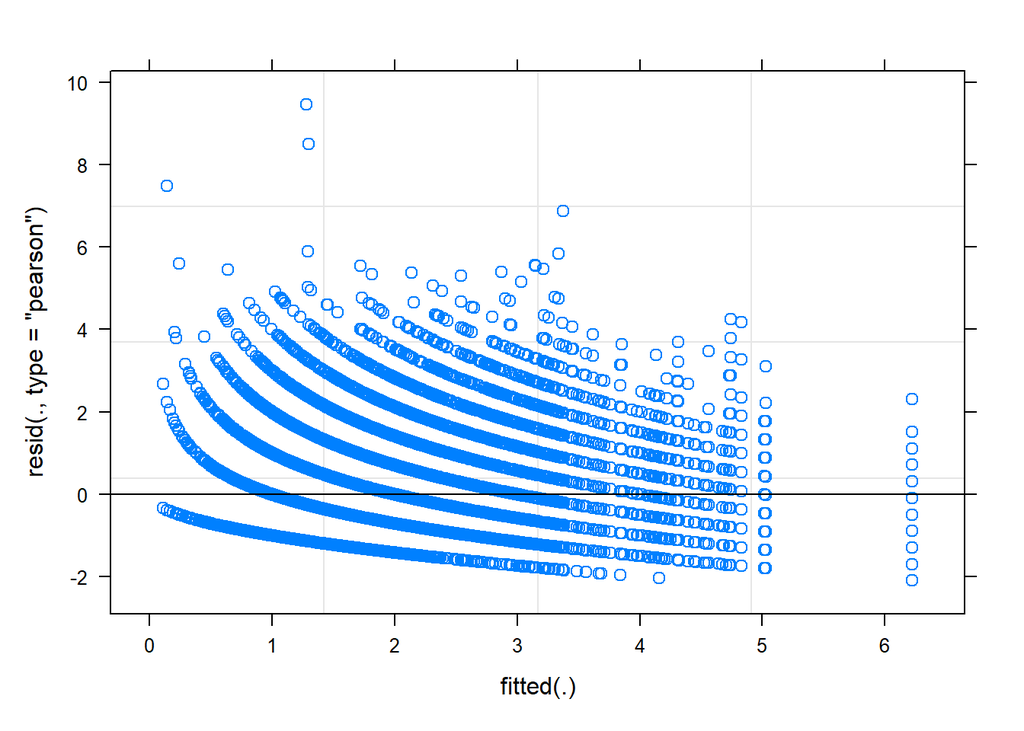

```r
plot(R_pa_clp_point)
```

```r
R_pa_ewm_point <- glmer(nat_richness~ poly(yday(survey_date), 2) + (myriophyllum_spicatum>0) + (1| dow ), data = plants_rakeabund_wide, family = poisson(link = "log"))
summary(R_pa_ewm_point)
```

```
## Generalized linear mixed model fit by maximum likelihood (Laplace
##   Approximation) [glmerMod]
##  Family: poisson  ( log )
## Formula: nat_richness ~ poly(yday(survey_date), 2) + (myriophyllum_spicatum >
##     0) + (1 | dow)
##    Data: plants_rakeabund_wide
##
##       AIC       BIC    logLik  deviance  df.resid
##  259682.7  259729.3 -129836.3  259672.7     81880
##
## Scaled residuals:
##     Min      1Q  Median      3Q     Max
## -2.1431 -0.7137 -0.1501  0.5186  8.1500
##
## Random effects:
##  Groups Name        Variance Std.Dev.
##  dow    (Intercept) 0.2669   0.5166
## Number of obs: 81885, groups:  dow, 217
##
## Fixed effects:
##                                 Estimate Std. Error z value Pr(>|z|)
## (Intercept)                     0.528939   0.035526  14.889   <2e-16 ***
## poly(yday(survey_date), 2)1    61.056865   0.484176 126.105   <2e-16 ***
## poly(yday(survey_date), 2)2   -26.496948   0.499037 -53.096   <2e-16 ***
## myriophyllum_spicatum > 0TRUE  -0.023380   0.007956  -2.939   0.0033 **
## ---
## Signif. codes:  0 '***' 0.001 '**' 0.01 '*' 0.05 '.' 0.1 ' ' 1
##
## Correlation of Fixed Effects:
##             (Intr) p((_),2)1 p((_),2)2
## ply((_),2)1 -0.005
## ply((_),2)2  0.011 -0.138
## myrp_>0TRUE -0.034  0.003     0.014
```

```r
#evenness
E_pa_clp_point <- lmer(nat_evenness ~ poly(yday(survey_date), 2) + (potamogeton_crispus>0) + (1 | dow ), data = plants_rakeabund_wide)
summary(E_pa_clp_point)
```

```
## Linear mixed model fit by REML. t-tests use Satterthwaite's method [
## lmerModLmerTest]
## Formula: nat_evenness ~ poly(yday(survey_date), 2) + (potamogeton_crispus >
##     0) + (1 | dow)
##    Data: plants_rakeabund_wide
##
## REML criterion at convergence: -192985.5
##
## Scaled residuals:
##     Min      1Q  Median      3Q     Max
## -3.7918 -0.6534  0.3196  0.7309  2.5044
##
## Random effects:
##  Groups   Name        Variance  Std.Dev.
##  dow      (Intercept) 0.0006872 0.02621
##  Residual             0.0037874 0.06154
## Number of obs: 70760, groups:  dow, 217
##
## Fixed effects:
##                               Estimate Std. Error         df t value Pr(>|t|)
## (Intercept)                  9.551e-01  1.844e-03  2.090e+02 518.060  < 2e-16
## poly(yday(survey_date), 2)1 -2.427e+00  8.261e-02  7.038e+04 -29.380  < 2e-16
## poly(yday(survey_date), 2)2  6.645e-01  7.998e-02  7.001e+04   8.309  < 2e-16
## potamogeton_crispus > 0TRUE  4.740e-03  6.839e-04  7.072e+04   6.931 4.21e-12
##
## (Intercept)                 ***
## poly(yday(survey_date), 2)1 ***
## poly(yday(survey_date), 2)2 ***
## potamogeton_crispus > 0TRUE ***
## ---
## Signif. codes:  0 '***' 0.001 '**' 0.01 '*' 0.05 '.' 0.1 ' ' 1
##
## Correlation of Fixed Effects:
##             (Intr) p((_),2)1 p((_),2)2
## ply((_),2)1 -0.047
## ply((_),2)2  0.023 -0.079
## ptmg_>0TRUE -0.077  0.280     0.029
```

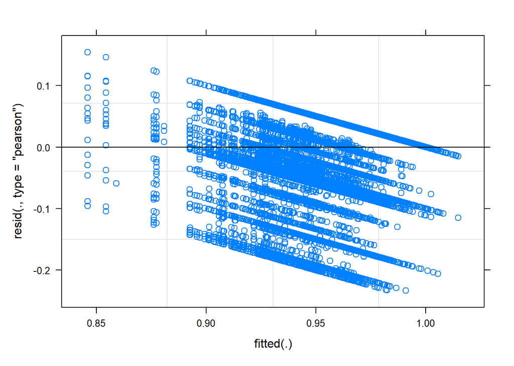

```r
plot(E_pa_clp_point)
```

```r
E_pa_ewm_point <- lmer(nat_evenness~ poly(yday(survey_date), 2) + (myriophyllum_spicatum>0) + (1 |dow ), data = plants_rakeabund_wide)
summary(E_pa_ewm_point)
```

```
## Linear mixed model fit by REML. t-tests use Satterthwaite's method [
## lmerModLmerTest]
## Formula: nat_evenness ~ poly(yday(survey_date), 2) + (myriophyllum_spicatum >
##     0) + (1 | dow)
##    Data: plants_rakeabund_wide
##
## REML criterion at convergence: -192941.2
##
## Scaled residuals:
##     Min      1Q  Median      3Q     Max
## -3.8273 -0.6547  0.3206  0.7343  2.5109
##
## Random effects:
##  Groups   Name        Variance Std.Dev.
##  dow      (Intercept) 0.000692 0.02631
##  Residual             0.003790 0.06156
## Number of obs: 70760, groups:  dow, 217
##
## Fixed effects:
##                                 Estimate Std. Error         df t value Pr(>|t|)
## (Intercept)                    9.558e-01  1.847e-03  2.079e+02 517.381  < 2e-16
## poly(yday(survey_date), 2)1   -2.586e+00  7.934e-02  7.022e+04 -32.598  < 2e-16
## poly(yday(survey_date), 2)2    6.525e-01  8.000e-02  7.002e+04   8.156 3.51e-16
## myriophyllum_spicatum > 0TRUE  1.392e-03  7.414e-04  7.015e+04   1.878   0.0604
##
## (Intercept)                   ***
## poly(yday(survey_date), 2)1   ***
## poly(yday(survey_date), 2)2   ***
## myriophyllum_spicatum > 0TRUE .
## ---
## Signif. codes:  0 '***' 0.001 '**' 0.01 '*' 0.05 '.' 0.1 ' ' 1
##
## Correlation of Fixed Effects:
##             (Intr) p((_),2)1 p((_),2)2
## ply((_),2)1 -0.027
## ply((_),2)2  0.024 -0.090
## myrp_>0TRUE -0.060  0.006     0.026
```

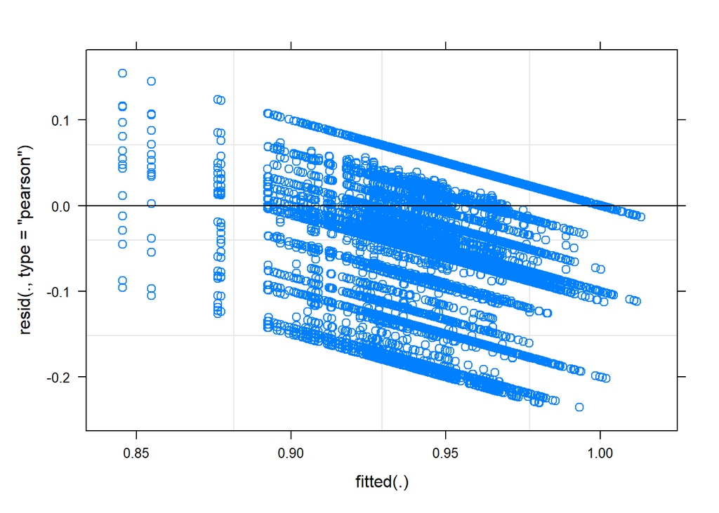

```r
plot(E_pa_ewm_point)
```

#### Interpret

What these results “look” like, is that there is a sig effect in each of the native response metrics (almost, ewm evenness is marginal).

Some notworthy bits here. We’ve modeled evenness as a gaussian error process because the modlels are failing somehow when we assess using binomial distributions.

Now export these model results:

```r
# Compile Model Tables - Point --------------------------------------------

inv_mods_point <- rbindlist(
  list(data.table(summary(D_pa_ewm_point)$coef[c(1,4),], keep.rownames = T),
       data.table(summary(R_pa_ewm_point)$coef[c(1,4),], keep.rownames = T),
       data.table(summary(E_pa_ewm_point)$coef[c(1,4),], keep.rownames = T),
       data.table(summary(D_pa_clp_point)$coef[c(1,4),], keep.rownames = T),
       data.table(summary(R_pa_clp_point)$coef[c(1,4),], keep.rownames = T),
       data.table(summary(E_pa_clp_point)$coef[c(1,4),], keep.rownames = T),
       data.table(summary(D_ab_ewm_point)$coef[c(1,4),], keep.rownames = T),
       data.table(summary(R_ab_ewm_point)$coef[c(1,4),], keep.rownames = T),
       data.table(summary(E_ab_ewm_point)$coef[c(1,4),], keep.rownames = T),
       data.table(summary(D_ab_clp_point)$coef[c(1,4),], keep.rownames = T),
       data.table(summary(R_ab_clp_point)$coef[c(1,4),], keep.rownames = T),
       data.table(summary(E_ab_clp_point)$coef[c(1,4),], keep.rownames = T)
  ), fill = TRUE
)

inv_mods_point[ , species := rep(c(rep("Mspi", 6),rep("Pcri", 6)), 2) ]
inv_mods_point[ , response := rep(c(rep("Div", 2),rep("Rich", 2), rep("Even", 2)), 4) ]

inv_mods_point[response == "Rich", Estimate_backtrans := exp(Estimate)]
inv_mods_point[response == "Even", Estimate_backtrans := plogis(Estimate)]

inv_mods_point[response == "Rich", confint_lwr := exp(Estimate - 1.96*`Std. Error`)]
inv_mods_point[response == "Rich", confint_upr := exp(Estimate + 1.96*`Std. Error`)]

inv_mods_point[response == "Even", confint_lwr := plogis(Estimate - 1.96*`Std. Error`)]
inv_mods_point[response == "Even", confint_upr := plogis(Estimate + 1.96*`Std. Error`)]

inv_mods_point[response == "Div", confint_lwr := Estimate - 1.96*`Std. Error`]
inv_mods_point[response == "Div", confint_upr := Estimate + 1.96*`Std. Error`]

rbindlist(list(inv_mods,inv_mods_point))
```

```
##                                rn      Estimate   Std. Error         df
##                            <char>         <num>        <num>      <num>
##  1:                   (Intercept)  5.2902248637 0.1048082555   104.5336
##  2: myrspi_summer_vegdfoc > 0TRUE  0.3658066744 0.1963079747  2615.2337
##  3:                   (Intercept)  2.1302387373 0.0294673180         NA
##  4: myrspi_summer_vegdfoc > 0TRUE  0.2013114932 0.0386096586         NA
##  5:                   (Intercept)  0.3500930639 0.0431433855         NA
##  6: myrspi_summer_vegdfoc > 0TRUE -1.2400561159 0.1122910340         NA
##  7:                   (Intercept)  4.3737020607 0.3840552827   212.6558
##  8:  potcri_early_vegdfoc > 0TRUE  0.4361093287 0.2977996754   369.9028
##  9:                   (Intercept)  2.2438438483 0.0977592885         NA
## 10:  potcri_early_vegdfoc > 0TRUE  0.0002847844 0.0839832883         NA
## 11:                   (Intercept) -0.1377662866 0.3587695000         NA
## 12:  potcri_early_vegdfoc > 0TRUE -0.3770860578 0.3740337148         NA
## 13:                   (Intercept)  5.7781138456 0.3020924371   149.3078
```

[output cut: 138 more lines]

```r
# fwrite(rbindlist(list(inv_mods,inv_mods_point)), file = "data&scripts/data/output/obs_comp_mods.csv")



# visualizations with tests -----------------------------------------------
```

```r
# predictions on abund ----------------------------------------------------


#new data spanning abund to predict models from
# EWM
newdat3<-data.frame(myriophyllum_spicatum = seq(1,3, length.out = nrow(plants_rakeabund_wide[myriophyllum_spicatum > 0 ])),
                    survey_date = plants_rakeabund_wide[myriophyllum_spicatum > 0 , mean(survey_date)],
                    dow = plants_rakeabund_wide[myriophyllum_spicatum > 0 , dow])
# CLP
newdat4<-data.frame(potamogeton_crispus = seq(1,3, length.out = nrow(plants_rakeabund_wide[potamogeton_crispus > 0 ])),
                    survey_date = plants_rakeabund_wide[potamogeton_crispus > 0 , mean(survey_date)],
                    dow = plants_rakeabund_wide[potamogeton_crispus > 0 , dow])

# ENSPie ~ Abund:
#EWM
newdat3$fittedD <- predict(D_ab_ewm_point, newdat3, re.form = NA)

#CLP
newdat4$fittedD <- predict(D_ab_clp_point, newdat4, re.form = NA)

##Richness~Abund:
#EWM
newdat3$fittedR <- predict(R_ab_ewm_point, newdat3, re.form = NA,type = "response" )
#CLP
newdat4$fittedR <- predict(R_ab_clp_point, newdat4, re.form = NA, type = "response")

#Evenness~Abund:
#EWM
newdat3$fittedE <- predict(E_ab_ewm_point, newdat3, re.form = NA)
#CLP
newdat4$fittedE <- predict(E_ab_clp_point, newdat4, re.form = NA)



#ENSpie
names(plants_rakeabund_wide) <- names(clean_names(plants_rakeabund_wide))

legend_colors <- c("potamogeton_crispus" = "blue", "myriophyllum_spicatum" = "red")
point_abund_ENSpie <- ggplot()+
  stat_smooth(data = plants_rakeabund_wide[potamogeton_crispus> 0],
              aes(potamogeton_crispus, simpsons_div_nat, color = "potamogeton_crispus", group = dow),
              method = "lm", geom = 'line', se =F,  alpha = .04)+
  ylab(bquote('Native diversity ('~ENS[PIE]~')'))+
  # theme(legend.position = "none")+
  stat_smooth(data = plants_rakeabund_wide[myriophyllum_spicatum> 0],
              aes(myriophyllum_spicatum, simpsons_div_nat,color = "myriophyllum_spicatum", group = dow),
              method = "lm", geom = 'line', se = F, color = "red", alpha = .04)+
  geom_line(data = newdat4,
            aes(potamogeton_crispus,fittedD), color = "blue", size = 1.5)+
  geom_line(data = newdat3,
            aes(myriophyllum_spicatum,fittedD), color = "red", size = 1.5)+
  theme_bw()+
  xlab("Relative Abundance of Invader")+
  ggtitle("Invaded sample points")+
  scale_color_manual(values = legend_colors, labels = c("Potamogeton crispus","Myriophyllum spicatum"))+
  theme_bw()+
  theme(legend.position = c(0.6, 0.9),legend.title = element_blank(), legend.background = element_blank(), legend.text = element_text(face = "italic"))+
  guides(colour = guide_legend(override.aes = list(alpha = 1)))


#Richness
point_abund_richness <- ggplot()+
  # geom_boxplot(aes(group = potamogeton_crispus))+
  stat_smooth(data = plants_rakeabund_wide[potamogeton_crispus> 0],
              aes(potamogeton_crispus, nat_richness, group = dow),
              method = "lm", geom = 'line', se = F, color = "blue", alpha = .04)+
  ylab("Richness")+
  # theme(legend.position = "none")+
  stat_smooth(data = plants_rakeabund_wide[myriophyllum_spicatum> 0],
              aes(myriophyllum_spicatum, nat_richness, group = dow),
              method = "lm", geom = 'line', se = F, color = "red", alpha = .04)+
  geom_line(data = newdat3,
            aes(myriophyllum_spicatum,fittedR),
            color = "red", size = 1.5)+
  geom_line(data = newdat4,
            aes(potamogeton_crispus,fittedR),
            color = "blue", size = 1.5)+
  theme_bw()+
  xlab("Relative Abundance of Invader")+
  scale_color_manual(values = legend_colors, labels = c("Potamogeton crispus","Myriophyllum spicatum"))+
  theme_bw()+
  ggtitle("")+
  theme(legend.position = c(0.6, 0.9), legend.background = element_blank(), legend.text = element_text(face = "italic"))+
  theme(axis.text.y.left = element_text(angle = 90))


#evenness?
point_abund_evenness <- ggplot()+
  # geom_boxplot(aes(group = potamogeton_crispus))+
  stat_smooth(data = plants_rakeabund_wide[potamogeton_crispus> 0],
              aes(potamogeton_crispus, nat_evenness, group = dow),
              method = "lm", geom = 'line', se = F, color = "blue", alpha = .04)+
  ylab("Evenness")+
  # theme(legend.position = "none")+
  stat_smooth(data = plants_rakeabund_wide[myriophyllum_spicatum> 0],
              aes(myriophyllum_spicatum, nat_evenness, group = dow),
              method = "lm", geom = 'line', se = F, color = "red", alpha = .04)+
  geom_line(data = newdat3, aes(myriophyllum_spicatum,fittedE), color = "red", size = 1.5)+
  geom_line(data = newdat4,
            aes(potamogeton_crispus,fittedE),
            color = "blue", size = 1.5)+
  theme_bw()+
  xlab("Relative Abundance of Invader")+
  scale_color_manual(values = legend_colors, labels = c("Potamogeton crispus","Myriophyllum spicatum"))+
  theme_bw()+
  theme(legend.position = c(0.6, 0.9), legend.background = element_blank(), legend.text = element_text(face = "italic"))+
  theme(axis.text.y.left = element_text(angle = 90))+
  ylim(c(0.7, 1.05))

point_abunds <- ggarrange(point_abund_ENSpie, ggarrange(point_abund_richness, point_abund_evenness,
                                                        ncol = 1,
                                                        labels = c("e","f"),
                                                        label.x = c(0.15,0.15),
                                                        label.y = c(0.86,0.95)),
                          labels = c("d",""),
                          label.x = 0.15,
                          label.y = 0.91)+  border(color = "black", size = 0.8, linetype = NULL)
# signific. on boxplots ---------------------------------------------------
```

Add significance levels to boxplots

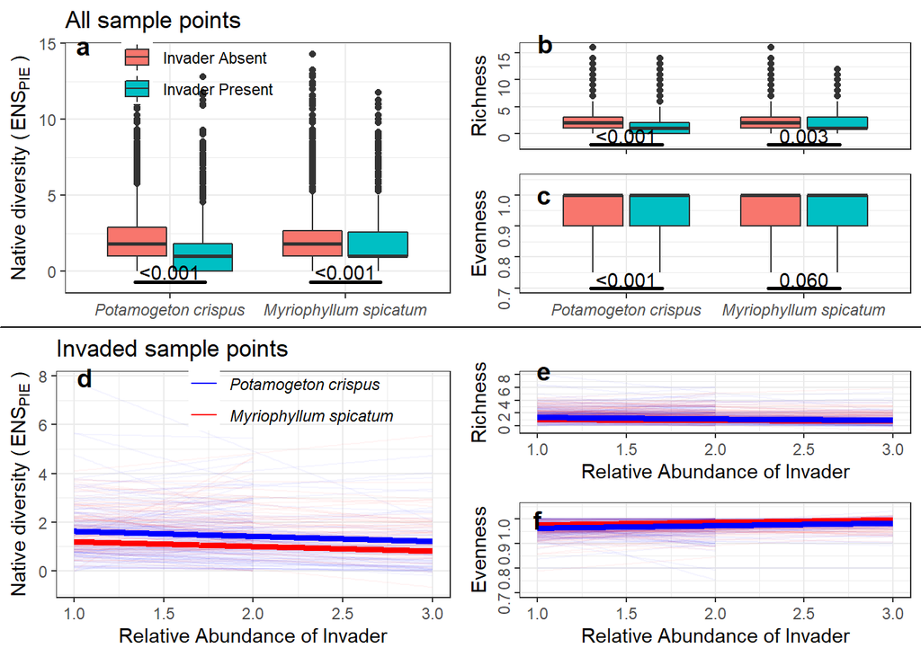

```r
box1p <- box1p+
  geom_signif(
    y_position = c(-0.7, -0.7), xmin = c(0.8, 1.8), xmax = c(1.2, 2.2),
    annotation = c("<0.001", "<0.001"), tip_length = 0, size = 1
  )

box2p <- box2p+
  geom_signif(
    y_position = c(-2, -2), xmin = c(0.8, 1.8), xmax = c(1.2, 2.2),
    annotation = c("<0.001", "0.003"), tip_length = 0, size = 1
  )

box3p <- box3p+
  geom_signif(
    y_position = c(0.7, 0.7), xmin = c(0.8, 1.8), xmax = c(1.2, 2.2),
    annotation = c("<0.001", "0.060"), tip_length = 0, size = 1
  )+ylim(c(0.7, 1.05))


box1bp <- ggarrange(box2p, box3p, ncol = 1,
                   labels = c("b","c"),
                   label.x = c(0.15,0.15),
                   label.y = c(0.85,0.93))
point_boxpsp <- ggarrange(box1p, box1bp,
                         labels = c("a", ""),
                         label.x = 0.15,
                         label.y = 0.92)

# Figure 2: Compile boxplots and abund plots

ggarrange(point_boxpsp,point_abunds, ncol = 1)
```

A few things I don’t love: 1. I can’t see the medians in the boxplots 2. I can’t tell whats happening in the evenness plots 3. There’s got to be a #3, I just can’t think of one right now.

### Methodological Conclusions: p/s vs. abund

Up to this point we have treated these (p/a and abund) as two models. A glance at the plots shows you that p/a at the lake scale is problematic because the effects of invader presence are generally opposite the effects of invader abundance.

From here forward we use only the present locs for the lake scale.

On the other hand, the point level observations tend to show same trends in p/a and abund, so we could consider them as one.

From here forward, we use all the point data including zeros and abunds.

Diversity as a metric allows us to incorporate both richness and evenness in our native community metric, so let’s use that moving forward, but we’ll model & print all the metrics (DRE).

```r
# lake level light/ Secchi ------------------------------------------------
```

The next thing we want to investigate is how light, is driving some of the native community and invader relationship.

## Environmental Conditions (Light)

### Lake Level - Viz

```r
#whats the relationship to clarity look like in uninvaded lakes

summer_surveys[ , invaded := (potcri_early_vegdfoc > 0 | myrspi_summer_vegdfoc > 0)|
                  (is.na(potcri_early_vegdfoc) & myrspi_summer_vegdfoc > 0),]
summer_surveys[ is.na(potcri_early_vegdfoc) , invaded := myrspi_summer_vegdfoc > 0 ,]
#check work:
summer_surveys[ , .N , .(myrspi_summer_vegdfoc>0,potcri_early_vegdfoc>0, invaded ) ]
```

```
##    myrspi_summer_vegdfoc potcri_early_vegdfoc invaded     N
##                   <lgcl>               <lgcl>  <lgcl> <int>
## 1:                 FALSE                   NA   FALSE  2202
## 2:                  TRUE                   NA    TRUE   329
## 3:                  TRUE                 TRUE    TRUE   140
## 4:                 FALSE                 TRUE    TRUE   224
## 5:                  TRUE                FALSE    TRUE     8
## 6:                 FALSE                FALSE   FALSE    34
```

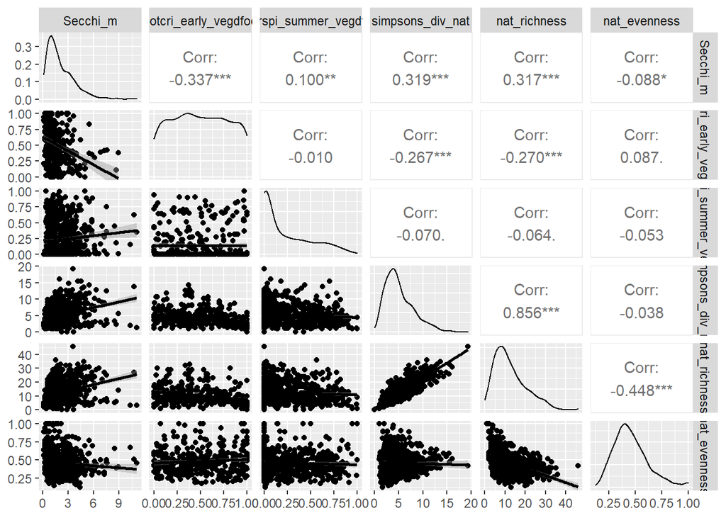

```r
ggpairs(summer_surveys[invaded == T , .(Secchi_m, potcri_early_vegdfoc, myrspi_summer_vegdfoc, simpsons_div_nat, nat_richness,nat_evenness)], lower = list(continuous = "smooth"), aes(fill = NULL))
```

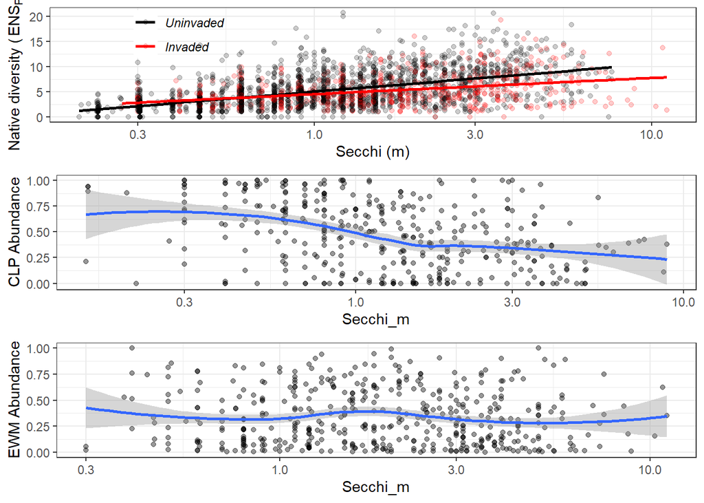

```r
nat_ENSpie <- ggplot(summer_surveys[!is.na(Secchi_m) & Secchi_m >0.2 , ],
                     aes(Secchi_m,simpsons_div_nat, color = invaded))+
  geom_point( alpha = 0.2)+
  geom_smooth(method = "lm", se = F)+
  xlab("Secchi (m)")+
  ylab(bquote('Native diversity ('~ENS[PIE]~')'))+
  scale_color_manual(values = c("black", "red"), labels = c("Uninvaded","Invaded"))+
  theme_bw()+
  theme(legend.position = c(0.2, 0.8), legend.background = element_blank(), legend.text = element_text(face = "italic"), legend.title = element_blank())+
  scale_x_log10()

nat_rich <- ggplot(summer_surveys[!is.na(Secchi_m) , ],
                     aes(Secchi_m,nat_richness, color = invaded))+
  geom_point( alpha = 0.4)+
  geom_smooth(method = "lm")+
  xlab("Secchi")+
  ylab("Richness")+
  scale_color_manual(values = c("black", "red"), labels = c("Uninvaded","Invaded"))+
  theme_bw()+
  theme(legend.position = c(0.6, 0.8), legend.background = element_blank(), legend.text = element_text(face = "italic"), legend.title = element_blank())+
  scale_x_log10()


nat_even <- ggplot(summer_surveys[!is.na(Secchi_m) , ],
                     aes(Secchi_m,nat_evenness, color = invaded))+
  geom_point( alpha = 0.4)+
  geom_smooth(method = "lm")+
  xlab("Secchi (m)")+
  ylab("Evenness")+
  scale_color_manual(values = c("black", "red"), labels = c("Uninvaded","Invaded"))+
  theme_bw()+
  theme(legend.position = c(0.6, 0.8), legend.background = element_blank(), legend.text = element_text(face = "italic"), legend.title = element_blank())+
  scale_x_log10()


clp_secchi <- ggplot(summer_surveys[!is.na(potcri_early_vegdfoc), , ], aes(Secchi_m, potcri_early_vegdfoc))+
  geom_point( alpha = 0.4)+
  geom_smooth(method = "loess")+
  ylab("CLP Abundance")+
  theme_bw()+
  scale_x_log10()

ewm_secchi <- ggplot(summer_surveys[myrspi_summer_vegdfoc>0], aes(Secchi_m, myrspi_summer_vegdfoc))+
  geom_point( alpha = 0.4)+
  geom_smooth( method = "loess")+
  ylab("EWM Abundance")+
  theme_bw()+
  scale_x_log10()

ggarrange(nat_ENSpie, clp_secchi, ewm_secchi, ncol = 1)
```

### Lake Level - Test

```r
#now we want to ask if the relationship between the invaders abund and native species sticks when we consider WQ:

#CLP
summary(CLPabund_nat_lake_ENSpie)
```

```
## Linear mixed model fit by REML. t-tests use Satterthwaite's method [
## lmerModLmerTest]
## Formula: simpsons_div_nat ~ potcri_early_vegdfoc + (1 | DOW) + (1 | year)
##    Data: summer_surveys[potcri_early_vegdfoc > 0 & !is.na(Secchi_m)]
##
## REML criterion at convergence: 1295.5
##
## Scaled residuals:
##     Min      1Q  Median      3Q     Max
## -3.7218 -0.4862 -0.0816  0.4453  3.9831
##
## Random effects:
##  Groups   Name        Variance Std.Dev.
##  DOW      (Intercept) 5.47012  2.3388
##  year     (Intercept) 0.03468  0.1862
##  Residual             1.41919  1.1913
## Number of obs: 338, groups:  DOW, 89; year, 18
##
## Fixed effects:
##                      Estimate Std. Error       df t value Pr(>|t|)
## (Intercept)            5.0936     0.3255 107.2168  15.650   <2e-16 ***
## potcri_early_vegdfoc  -0.6509     0.3688 187.0651  -1.765   0.0792 .
## ---
## Signif. codes:  0 '***' 0.001 '**' 0.01 '*' 0.05 '.' 0.1 ' ' 1
##
## Correlation of Fixed Effects:
##             (Intr)
## ptcr_rly_vg -0.557
```

```r
summary(CLPabund_nat_lake_richness)
```

```
## Generalized linear mixed model fit by maximum likelihood (Laplace
##   Approximation) [glmerMod]
##  Family: poisson  ( log )
## Formula: nat_richness ~ potcri_early_vegdfoc + (1 | DOW) + (1 | year)
##    Data: summer_surveys[potcri_early_vegdfoc > 0]
##
##      AIC      BIC   logLik deviance df.resid
##   1936.8   1952.4   -964.4   1928.8      360
##
## Scaled residuals:
##     Min      1Q  Median      3Q     Max
## -2.8580 -0.4689  0.0093  0.4471  3.5254
##
## Random effects:
##  Groups Name        Variance Std.Dev.
##  DOW    (Intercept) 0.259931 0.50983
##  year   (Intercept) 0.001787 0.04227
## Number of obs: 364, groups:  DOW, 91; year, 18
##
## Fixed effects:
##                      Estimate Std. Error z value Pr(>|z|)
## (Intercept)           2.37291    0.07733  30.687   <2e-16 ***
## potcri_early_vegdfoc -0.23553    0.09701  -2.428   0.0152 *
## ---
## Signif. codes:  0 '***' 0.001 '**' 0.01 '*' 0.05 '.' 0.1 ' ' 1
##
## Correlation of Fixed Effects:
##             (Intr)
## ptcr_rly_vg -0.623
```

```r
summary(CLPabund_nat_lake_evenness)
```

```
## Generalized linear mixed model fit by maximum likelihood (Laplace
##   Approximation) [glmerMod]
##  Family: binomial  ( logit )
## Formula: nat_evenness ~ potcri_early_vegdfoc + (1 | DOW) + (1 | year)
##    Data: summer_surveys[potcri_early_vegdfoc > 0]
##
##      AIC      BIC   logLik deviance df.resid
##    479.6    495.2   -235.8    471.6      359
##
## Scaled residuals:
##      Min       1Q   Median       3Q      Max
## -0.51298 -0.06198  0.10949  0.31152  1.25535
##
## Random effects:
##  Groups Name        Variance Std.Dev.
##  DOW    (Intercept) 0.2903   0.5388
##  year   (Intercept) 0.0000   0.0000
## Number of obs: 363, groups:  DOW, 91; year, 18
##
## Fixed effects:
##                      Estimate Std. Error z value Pr(>|z|)
## (Intercept)           -0.9525     0.2552  -3.732  0.00019 ***
## potcri_early_vegdfoc   0.8554     0.4133   2.070  0.03850 *
## ---
## Signif. codes:  0 '***' 0.001 '**' 0.01 '*' 0.05 '.' 0.1 ' ' 1
##
## Correlation of Fixed Effects:
##             (Intr)
## ptcr_rly_vg -0.842
## optimizer (Nelder_Mead) convergence code: 0 (OK)
## boundary (singular) fit: see help('isSingular')
```

```r
m.div.clp.wc <- lmer(simpsons_div_nat ~ potcri_early_vegdfoc * Secchi_m + (1|DOW) + (1| year), data = summer_surveys[potcri_early_vegdfoc > 0 & !is.na(Secchi_m)] )

m.ric.clp.wc <- glmer(nat_richness ~ potcri_early_vegdfoc * Secchi_m + (1|DOW) + (1| year), data = summer_surveys[potcri_early_vegdfoc > 0 ], family = poisson())

m.evn.clp.wc <- lmer(nat_evenness ~ potcri_early_vegdfoc * Secchi_m + (1|DOW) + (1| year), data = summer_surveys[potcri_early_vegdfoc > 0 ] )

summary(m.div.clp.wc) # here everything becomes non significant
```

```
## Linear mixed model fit by REML. t-tests use Satterthwaite's method [
## lmerModLmerTest]
## Formula: simpsons_div_nat ~ potcri_early_vegdfoc * Secchi_m + (1 | DOW) +
##     (1 | year)
##    Data: summer_surveys[potcri_early_vegdfoc > 0 & !is.na(Secchi_m)]
##
## REML criterion at convergence: 1298.3
##
## Scaled residuals:
##     Min      1Q  Median      3Q     Max
## -3.5672 -0.4922 -0.0595  0.4479  3.8730
##
## Random effects:
##  Groups   Name        Variance Std.Dev.
##  DOW      (Intercept) 5.74443  2.3968
##  year     (Intercept) 0.03183  0.1784
##  Residual             1.40321  1.1846
## Number of obs: 338, groups:  DOW, 89; year, 18
##
## Fixed effects:
##                                Estimate Std. Error        df t value Pr(>|t|)
## (Intercept)                     5.28335    0.42265 211.76825  12.500   <2e-16
## potcri_early_vegdfoc           -0.70737    0.51965 268.41175  -1.361    0.175
## Secchi_m                       -0.10088    0.14501 299.85369  -0.696    0.487
## potcri_early_vegdfoc:Secchi_m   0.01456    0.25418 269.95459   0.057    0.954
##
## (Intercept)                   ***
## potcri_early_vegdfoc
## Secchi_m
## potcri_early_vegdfoc:Secchi_m
## ---
## Signif. codes:  0 '***' 0.001 '**' 0.01 '*' 0.05 '.' 0.1 ' ' 1
##
## Correlation of Fixed Effects:
##             (Intr) ptcr__ Scch_m
## ptcr_rly_vg -0.694
## Secchi_m    -0.627  0.640
## ptcr_rl_:S_  0.516 -0.702 -0.847
```

```r
summary(m.ric.clp.wc) # here clp still has a negative effect
```

```
## Generalized linear mixed model fit by maximum likelihood (Laplace
##   Approximation) [glmerMod]
##  Family: poisson  ( log )
## Formula: nat_richness ~ potcri_early_vegdfoc * Secchi_m + (1 | DOW) +
##     (1 | year)
##    Data: summer_surveys[potcri_early_vegdfoc > 0]
##
##      AIC      BIC   logLik deviance df.resid
##   1829.7   1852.7   -908.9   1817.7      332
##
## Scaled residuals:
##     Min      1Q  Median      3Q     Max
## -2.8031 -0.4899  0.0169  0.4408  3.5289
##
## Random effects:
##  Groups Name        Variance Std.Dev.
##  DOW    (Intercept) 0.257383 0.50733
##  year   (Intercept) 0.001117 0.03342
## Number of obs: 338, groups:  DOW, 89; year, 18
##
## Fixed effects:
##                               Estimate Std. Error z value Pr(>|z|)
## (Intercept)                    2.46393    0.10484  23.503   <2e-16 ***
## potcri_early_vegdfoc          -0.32601    0.14692  -2.219   0.0265 *
## Secchi_m                      -0.02275    0.03721  -0.611   0.5409
## potcri_early_vegdfoc:Secchi_m  0.01032    0.07106   0.145   0.8845
## ---
## Signif. codes:  0 '***' 0.001 '**' 0.01 '*' 0.05 '.' 0.1 ' ' 1
##
## Correlation of Fixed Effects:
##             (Intr) ptcr__ Scch_m
## ptcr_rly_vg -0.757
## Secchi_m    -0.668  0.663
## ptcr_rl_:S_  0.549 -0.723 -0.843
```

```r
summary(m.evn.clp.wc) # here everything becomes non significant
```

```
## Linear mixed model fit by REML. t-tests use Satterthwaite's method [
## lmerModLmerTest]
## Formula: nat_evenness ~ potcri_early_vegdfoc * Secchi_m + (1 | DOW) +
##     (1 | year)
##    Data: summer_surveys[potcri_early_vegdfoc > 0]
##
## REML criterion at convergence: -320.5
##
## Scaled residuals:
##     Min      1Q  Median      3Q     Max
## -2.5037 -0.5525 -0.1158  0.4838  3.6414
##
## Random effects:
##  Groups   Name        Variance Std.Dev.
##  DOW      (Intercept) 0.014253 0.11938
##  year     (Intercept) 0.000354 0.01881
##  Residual             0.014819 0.12173
## Number of obs: 337, groups:  DOW, 89; year, 18
##
## Fixed effects:
##                                 Estimate Std. Error         df t value Pr(>|t|)
## (Intercept)                     0.464718   0.033908 220.046782  13.705   <2e-16
## potcri_early_vegdfoc            0.041001   0.048614 319.721542   0.843    0.400
## Secchi_m                       -0.003285   0.013200 325.558180  -0.249    0.804
## potcri_early_vegdfoc:Secchi_m  -0.011347   0.024520 319.893863  -0.463    0.644
##
## (Intercept)                   ***
## potcri_early_vegdfoc
## Secchi_m
## potcri_early_vegdfoc:Secchi_m
## ---
## Signif. codes:  0 '***' 0.001 '**' 0.01 '*' 0.05 '.' 0.1 ' ' 1
##
## Correlation of Fixed Effects:
##             (Intr) ptcr__ Scch_m
## ptcr_rly_vg -0.805
## Secchi_m    -0.724  0.676
## ptcr_rl_:S_  0.571 -0.714 -0.841
```

```r
#plot_model(m.nat.clp.wc, type = "pred", terms = "potcri_early_vegdfoc")
# plot_model(m.nat.clp, type = "pred", terms = "potcri_early_vegdfoc")

#EWM
summary(EWMabund_nat_lake_ENSpie)
```

```
## Linear mixed model fit by REML. t-tests use Satterthwaite's method [
## lmerModLmerTest]
## Formula: simpsons_div_nat ~ myrspi_summer_vegdfoc + (1 | DOW) + (1 | year)
##    Data: summer_surveys[myrspi_summer_vegdfoc > 0]
##
## REML criterion at convergence: 2081.5
##
## Scaled residuals:
##     Min      1Q  Median      3Q     Max
## -3.8880 -0.4174 -0.0482  0.4452  3.2579
##
## Random effects:
##  Groups   Name        Variance Std.Dev.
##  DOW      (Intercept) 8.68993  2.9479
##  year     (Intercept) 0.03519  0.1876
##  Residual             2.37931  1.5425
## Number of obs: 477, groups:  DOW, 137; year, 18
##
## Fixed effects:
##                       Estimate Std. Error       df t value Pr(>|t|)
## (Intercept)             5.7781     0.3021 149.3078  19.127   <2e-16 ***
## myrspi_summer_vegdfoc  -0.9486     0.3995 419.0872  -2.374    0.018 *
## ---
## Signif. codes:  0 '***' 0.001 '**' 0.01 '*' 0.05 '.' 0.1 ' ' 1
##
## Correlation of Fixed Effects:
##             (Intr)
## myrsp_smmr_ -0.407
```

```r
summary(EWMabund_nat_lake_richness)
```

```
## Generalized linear mixed model fit by maximum likelihood (Laplace
##   Approximation) [glmerMod]
##  Family: poisson  ( log )
## Formula: nat_richness ~ myrspi_summer_vegdfoc + (1 | DOW) + (1 | year)
##    Data: summer_surveys[myrspi_summer_vegdfoc > 0]
##
##      AIC      BIC   logLik deviance df.resid
##   2854.0   2870.6  -1423.0   2846.0      473
##
## Scaled residuals:
##     Min      1Q  Median      3Q     Max
## -3.8802 -0.4737 -0.0104  0.4058  3.9465
##
## Random effects:
##  Groups Name        Variance Std.Dev.
##  DOW    (Intercept) 0.295617 0.54371
##  year   (Intercept) 0.003591 0.05993
## Number of obs: 477, groups:  DOW, 137; year, 18
##
## Fixed effects:
##                       Estimate Std. Error z value Pr(>|z|)
## (Intercept)            2.53322    0.05856  43.257  < 2e-16 ***
## myrspi_summer_vegdfoc -0.27031    0.07575  -3.568 0.000359 ***
## ---
## Signif. codes:  0 '***' 0.001 '**' 0.01 '*' 0.05 '.' 0.1 ' ' 1
##
## Correlation of Fixed Effects:
##             (Intr)
## myrsp_smmr_ -0.407
```

```r
summary(EWMabund_nat_lake_evenness)
```

```
## Generalized linear mixed model fit by maximum likelihood (Laplace
##   Approximation) [glmerMod]
##  Family: binomial  ( logit )
## Formula: nat_evenness ~ myrspi_summer_vegdfoc + (1 | DOW) + (1 | year)
##    Data: summer_surveys[myrspi_summer_vegdfoc > 0]
##
##      AIC      BIC   logLik deviance df.resid
##    578.6    595.2   -285.3    570.6      471
##
## Scaled residuals:
##     Min      1Q  Median      3Q     Max
## -0.3481  0.1130  0.2976  0.5145  1.6467
##
## Random effects:
##  Groups Name        Variance Std.Dev.
##  DOW    (Intercept) 0        0
##  year   (Intercept) 0        0
## Number of obs: 475, groups:  DOW, 137; year, 18
##
## Fixed effects:
##                       Estimate Std. Error z value Pr(>|z|)
## (Intercept)            -1.0708     0.1651  -6.484 8.91e-11 ***
## myrspi_summer_vegdfoc   0.5274     0.3782   1.395    0.163
## ---
## Signif. codes:  0 '***' 0.001 '**' 0.01 '*' 0.05 '.' 0.1 ' ' 1
##
## Correlation of Fixed Effects:
##             (Intr)
## myrsp_smmr_ -0.790
## optimizer (Nelder_Mead) convergence code: 0 (OK)
## boundary (singular) fit: see help('isSingular')
```

```r
m.div.ewm.wc <- lmer(simpsons_div_nat ~ myrspi_summer_vegdfoc * Secchi_m + (1|DOW) + (1| year), data = summer_surveys[myrspi_summer_vegdfoc > 0 ])

m.ric.ewm.wc <- glmer(nat_richness ~ myrspi_summer_vegdfoc * Secchi_m + (1|DOW) + (1| year), data = summer_surveys[myrspi_summer_vegdfoc > 0 ], family = poisson())

m.evn.ewm.wc <- lmer(nat_evenness ~ myrspi_summer_vegdfoc * Secchi_m + (1|DOW) + (1| year), data = summer_surveys[myrspi_summer_vegdfoc > 0 ])

summary(m.div.ewm.wc)# here everything becomes non significant
```

```
## Linear mixed model fit by REML. t-tests use Satterthwaite's method [
## lmerModLmerTest]
## Formula: simpsons_div_nat ~ myrspi_summer_vegdfoc * Secchi_m + (1 | DOW) +
##     (1 | year)
##    Data: summer_surveys[myrspi_summer_vegdfoc > 0]
##
## REML criterion at convergence: 2052.1
##
## Scaled residuals:
##     Min      1Q  Median      3Q     Max
## -3.8719 -0.4078 -0.0663  0.4647  3.2606
##
## Random effects:
##  Groups   Name        Variance Std.Dev.
##  DOW      (Intercept) 8.97481  2.9958
##  year     (Intercept) 0.04123  0.2031
##  Residual             2.36218  1.5369
## Number of obs: 470, groups:  DOW, 133; year, 18
##
## Fixed effects:
##                                 Estimate Std. Error        df t value Pr(>|t|)
## (Intercept)                      5.65009    0.38732 272.12469  14.588   <2e-16
## myrspi_summer_vegdfoc           -0.26784    0.61239 377.31844  -0.437    0.662
## Secchi_m                         0.05788    0.10752 419.67220   0.538    0.591
## myrspi_summer_vegdfoc:Secchi_m  -0.31261    0.21666 373.53268  -1.443    0.150
##
## (Intercept)                    ***
## myrspi_summer_vegdfoc
## Secchi_m
## myrspi_summer_vegdfoc:Secchi_m
## ---
## Signif. codes:  0 '***' 0.001 '**' 0.01 '*' 0.05 '.' 0.1 ' ' 1
##
## Correlation of Fixed Effects:
##             (Intr) myrs__ Scch_m
## myrsp_smmr_ -0.531
## Secchi_m    -0.598  0.529
## myrsp_s_:S_  0.445 -0.755 -0.732
```

```r
summary(m.ric.ewm.wc)# here everything becomes non significant
```

```
## Generalized linear mixed model fit by maximum likelihood (Laplace
##   Approximation) [glmerMod]
##  Family: poisson  ( log )
## Formula: nat_richness ~ myrspi_summer_vegdfoc * Secchi_m + (1 | DOW) +
##     (1 | year)
##    Data: summer_surveys[myrspi_summer_vegdfoc > 0]
##
##      AIC      BIC   logLik deviance df.resid
##   2808.0   2832.9  -1398.0   2796.0      464
##
## Scaled residuals:
##     Min      1Q  Median      3Q     Max
## -3.8055 -0.4864 -0.0076  0.4095  3.6813
##
## Random effects:
##  Groups Name        Variance Std.Dev.
##  DOW    (Intercept) 0.302259 0.54978
##  year   (Intercept) 0.003903 0.06247
## Number of obs: 470, groups:  DOW, 133; year, 18
##
## Fixed effects:
##                                Estimate Std. Error z value Pr(>|z|)
## (Intercept)                     2.56228    0.07295  35.122   <2e-16 ***
## myrspi_summer_vegdfoc          -0.17563    0.12058  -1.457    0.145
## Secchi_m                       -0.01413    0.01927  -0.733    0.463
## myrspi_summer_vegdfoc:Secchi_m -0.03718    0.04065  -0.915    0.360
## ---
## Signif. codes:  0 '***' 0.001 '**' 0.01 '*' 0.05 '.' 0.1 ' ' 1
##
## Correlation of Fixed Effects:
##             (Intr) myrs__ Scch_m
## myrsp_smmr_ -0.526
## Secchi_m    -0.568  0.514
## myrsp_s_:S_  0.432 -0.774 -0.704
```

```r
summary(m.evn.ewm.wc)# here everything becomes non significant
```

```
## Linear mixed model fit by REML. t-tests use Satterthwaite's method [
## lmerModLmerTest]
## Formula: nat_evenness ~ myrspi_summer_vegdfoc * Secchi_m + (1 | DOW) +
##     (1 | year)
##    Data: summer_surveys[myrspi_summer_vegdfoc > 0]
##
## REML criterion at convergence: -591.6
##
## Scaled residuals:
##     Min      1Q  Median      3Q     Max
## -2.4659 -0.5726 -0.0867  0.4418  4.2949
##
## Random effects:
##  Groups   Name        Variance  Std.Dev.
##  DOW      (Intercept) 0.0117724 0.10850
##  year     (Intercept) 0.0009458 0.03075
##  Residual             0.0103245 0.10161
## Number of obs: 468, groups:  DOW, 133; year, 18
##
## Fixed effects:
##                                  Estimate Std. Error         df t value
## (Intercept)                      0.422831   0.021713 158.920213  19.474
## myrspi_summer_vegdfoc            0.030356   0.038622 433.904998   0.786
## Secchi_m                        -0.002309   0.006432 452.742795  -0.359
## myrspi_summer_vegdfoc:Secchi_m   0.013195   0.013672 427.753045   0.965
##                                Pr(>|t|)
## (Intercept)                      <2e-16 ***
## myrspi_summer_vegdfoc             0.432
## Secchi_m                          0.720
## myrspi_summer_vegdfoc:Secchi_m    0.335
## ---
## Signif. codes:  0 '***' 0.001 '**' 0.01 '*' 0.05 '.' 0.1 ' ' 1
##
## Correlation of Fixed Effects:
##             (Intr) myrs__ Scch_m
## myrsp_smmr_ -0.603
## Secchi_m    -0.661  0.550
## myrsp_s_:S_  0.489 -0.772 -0.730
```

```r
# plot_model(m.nat.ewm.wc, type = "pred", terms = "myrspi_summer_vegdfoc")
# plot_model(m.nat.ewm, type = "pred", terms = "myrspi_summer_vegdfoc")

#do the invaders exhibit negative relationships to secchi?
clp_secchi_test <- glmer(potcri_early_vegdfoc ~ log(Secchi_m) + (1|DOW) + (1| year), data = summer_surveys[!is.na(potcri_early_vegdfoc) ], family = binomial(), weights = SPRING_n_points_vegetated)
summary(clp_secchi_test)
```

```
## Generalized linear mixed model fit by maximum likelihood (Laplace
##   Approximation) [glmerMod]
##  Family: binomial  ( logit )
## Formula: potcri_early_vegdfoc ~ log(Secchi_m) + (1 | DOW) + (1 | year)
##    Data: summer_surveys[!is.na(potcri_early_vegdfoc)]
## Weights: SPRING_n_points_vegetated
##
##      AIC      BIC   logLik deviance df.resid
##   4622.5   4638.3  -2307.3   4614.5      373
##
## Scaled residuals:
##      Min       1Q   Median       3Q      Max
## -11.1834  -1.4519  -0.0479   1.2657   8.5357
##
## Random effects:
##  Groups Name        Variance Std.Dev.
##  DOW    (Intercept) 4.670    2.161
##  year   (Intercept) 1.014    1.007
## Number of obs: 377, groups:  DOW, 99; year, 18
##
## Fixed effects:
##               Estimate Std. Error z value Pr(>|z|)
## (Intercept)   -0.37015    0.32732  -1.131    0.258
## log(Secchi_m) -0.17949    0.03252  -5.520 3.39e-08 ***
## ---
## Signif. codes:  0 '***' 0.001 '**' 0.01 '*' 0.05 '.' 0.1 ' ' 1
##
## Correlation of Fixed Effects:
##             (Intr)
## log(Scch_m) -0.018
```

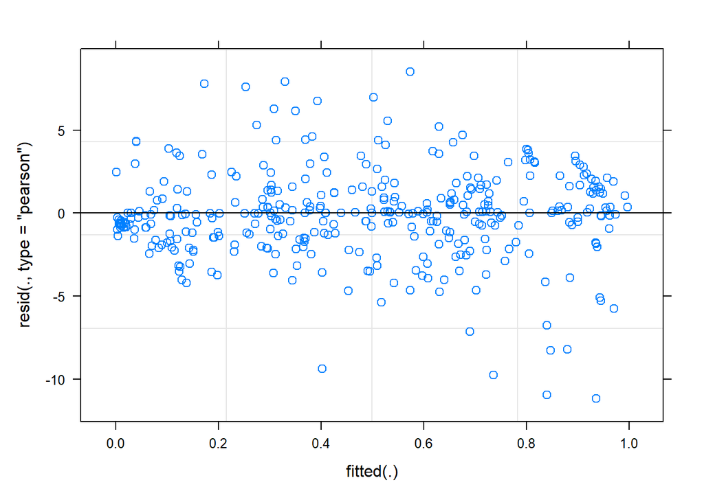

```r
plot(clp_secchi_test)
```

```r
ewm_secchi_test <- glmer(myrspi_summer_vegdfoc ~ log(Secchi_m) + (1|DOW) + (1| year), data = summer_surveys[ myrspi_summer_vegdfoc>0], family = binomial(), weights = n_points_vegetated)
summary(ewm_secchi_test)
```

```
## Generalized linear mixed model fit by maximum likelihood (Laplace
##   Approximation) [glmerMod]
##  Family: binomial  ( logit )
## Formula: myrspi_summer_vegdfoc ~ log(Secchi_m) + (1 | DOW) + (1 | year)
##    Data: summer_surveys[myrspi_summer_vegdfoc > 0]
## Weights: n_points_vegetated
##
##      AIC      BIC   logLik deviance df.resid
##   8265.8   8282.4  -4128.9   8257.8      466
##
## Scaled residuals:
##     Min      1Q  Median      3Q     Max
## -8.7100 -1.9896 -0.0172  1.8167 18.4380
##
## Random effects:
##  Groups Name        Variance Std.Dev.
##  DOW    (Intercept) 2.7207   1.6495
##  year   (Intercept) 0.4377   0.6616
## Number of obs: 470, groups:  DOW, 133; year, 18
##
## Fixed effects:
##               Estimate Std. Error z value Pr(>|z|)
## (Intercept)   -0.94178    0.21522  -4.376 1.21e-05 ***
## log(Secchi_m)  0.11864    0.02909   4.078 4.54e-05 ***
## ---
## Signif. codes:  0 '***' 0.001 '**' 0.01 '*' 0.05 '.' 0.1 ' ' 1
##
## Correlation of Fixed Effects:
##             (Intr)
## log(Scch_m) -0.075
```

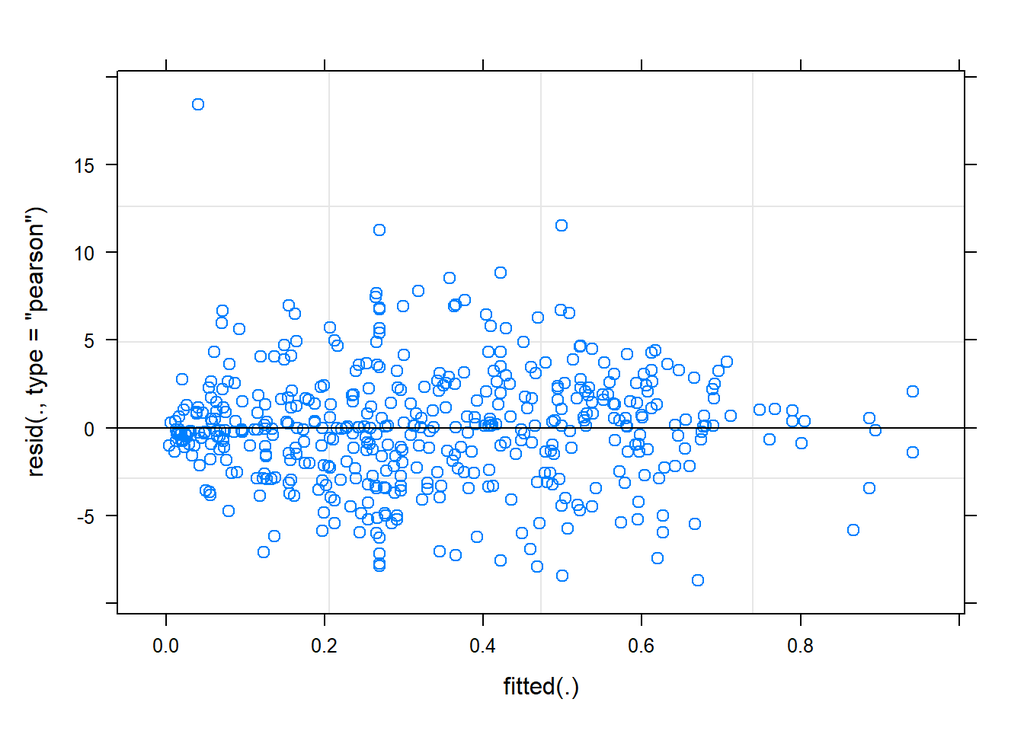

```r
plot(ewm_secchi_test)
```

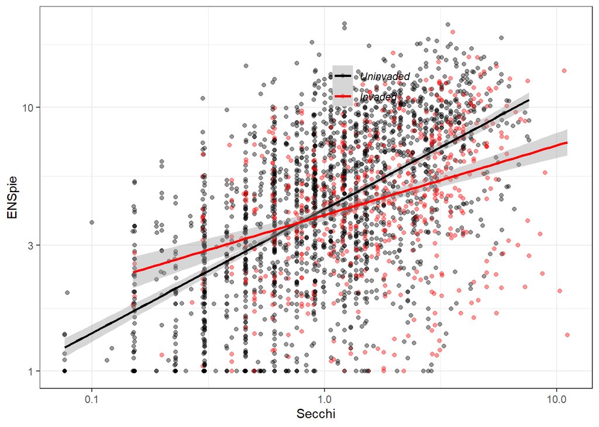

```r
# we could also ask if the decline in the positive secchi effect is significant:
ggplot(summer_surveys[!is.na(Secchi_m) & Secchi_m >0.05 & simpsons_div_nat > 0 , ],
       aes(Secchi_m,simpsons_div_nat, color = invaded))+
  geom_point( alpha = 0.4)+
  geom_smooth(method = "lm")+
  xlab("Secchi")+
  ylab("ENSpie")+
  scale_color_manual(values = c("black", "red"), labels = c("Uninvaded","Invaded"))+
  theme_bw()+
  theme(legend.position = c(0.6, 0.8), legend.background = element_blank(), legend.text = element_text(face = "italic"), legend.title = element_blank())+scale_x_log10()+scale_y_log10()
```

```r
secchi_nat_inv <- lmer(log(simpsons_div_nat)~invaded*log(Secchi_m) + (1|DOW) + (1| year) ,
                       data = summer_surveys[!is.na(Secchi_m) & Secchi_m >0.05 & simpsons_div_nat > 0 , ])
summary(secchi_nat_inv)
```

```
## Linear mixed model fit by REML. t-tests use Satterthwaite's method [
## lmerModLmerTest]
## Formula: log(simpsons_div_nat) ~ invaded * log(Secchi_m) + (1 | DOW) +
##     (1 | year)
##    Data:
## summer_surveys[!is.na(Secchi_m) & Secchi_m > 0.05 & simpsons_div_nat >
##     0, ]
##
## REML criterion at convergence: 3892.7
##
## Scaled residuals:
##     Min      1Q  Median      3Q     Max
## -4.4890 -0.4638  0.0695  0.5037  2.8293
##
## Random effects:
##  Groups   Name        Variance  Std.Dev.
##  DOW      (Intercept) 0.2337950 0.48352
##  year     (Intercept) 0.0009992 0.03161
##  Residual             0.1300940 0.36069
## Number of obs: 2637, groups:  DOW, 1306; year, 19
##
## Fixed effects:
##                             Estimate Std. Error         df t value Pr(>|t|)
## (Intercept)                  1.44440    0.01834   85.98087  78.747  < 2e-16 ***
## invadedTRUE                  0.11323    0.03292 2474.94290   3.440 0.000591 ***
## log(Secchi_m)                0.33966    0.01558 2509.71443  21.801  < 2e-16 ***
## invadedTRUE:log(Secchi_m)   -0.28376    0.03013 2033.83253  -9.417  < 2e-16 ***
## ---
## Signif. codes:  0 '***' 0.001 '**' 0.01 '*' 0.05 '.' 0.1 ' ' 1
##
## Correlation of Fixed Effects:
##             (Intr) inTRUE lg(S_)
## invadedTRUE -0.213
## log(Scch_m) -0.035  0.074
## inTRUE:(S_) -0.012 -0.250 -0.445
```

### Point Level - Viz

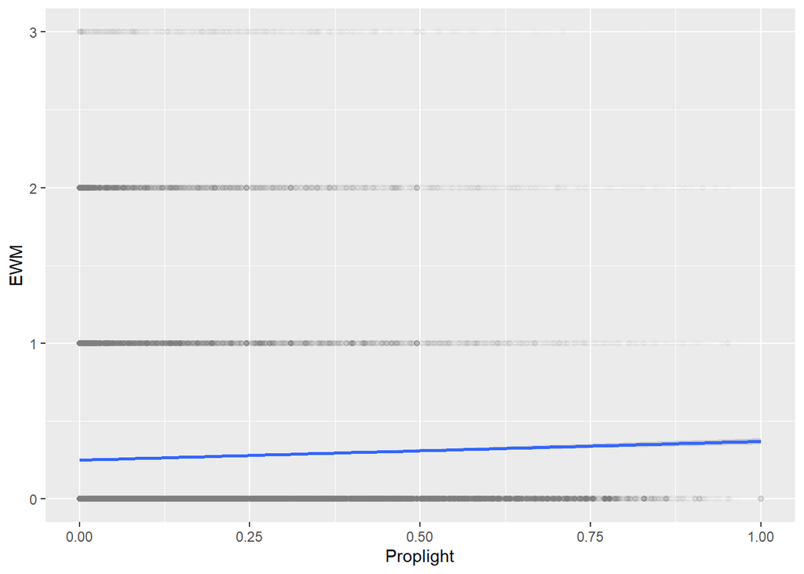

```r
# point level light avail -------------------------------------------------

point_nat_light <- ggplot(plants_rakeabund_wide[!is.na(proplight)], aes(proplight, simpsons_div_nat))+
  geom_point( alpha = 0.02, size = 2.5)+
  geom_smooth(method = "lm")+
  xlab("Proplight")+
  ylab("ENSpie")


ggplot(plants_rakeabund_wide[!is.na(proplight)], aes(proplight, myriophyllum_spicatum))+
  geom_point( alpha = 0.005)+
  geom_smooth(method = "lm")+
  xlab("Proplight")+
  ylab("EWM")
```

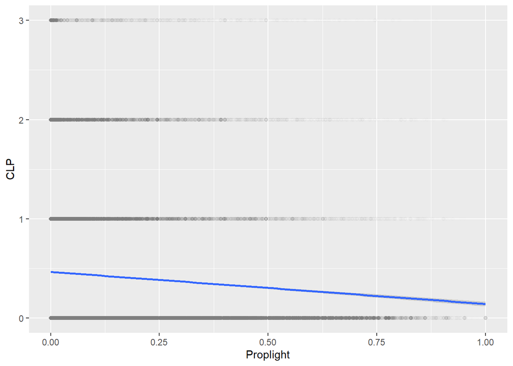

```r
ggplot(plants_rakeabund_wide[!is.na(proplight)], aes(proplight, potamogeton_crispus))+
  geom_point( alpha = 0.005)+
  geom_smooth(method = "lm")+
  xlab("Proplight")+
  ylab("CLP")
```

We’ll use a VCA to examine where light var is coming from in our data: This is a nice solution to Dan’s question about how much in-lake variation in depth can even contribute to the overall variance in proplight.

Currently not sucessful in implememnting this because of memory allocation.

```r
#
# names(plants)
#
# varPlot(form = proplight~watershed/dow/survey_id/point_id,
#        Data=plants_rakeabund_wide)
#
# fitVCA(form=proplight~watershed/DOW/SURVEY_ID/POINT_ID,
#        Data=plants[!is.na(proplight) & !is.na(watershed)])
#
```

### Point Level - Test

Does negative point scale rel goes away if we account for light & if that effect varies by species:

```r
# test: point level invader eff + water clarity ---------------------------

D_ab_clp_point
```

```
## Linear mixed model fit by REML ['lmerModLmerTest']
## Formula: simpsons_div_nat ~ poly(yday(survey_date), 2) + potamogeton_crispus +
##     (1 | dow)
##    Data: plants_rakeabund_wide[potamogeton_crispus > 0, ]
## REML criterion at convergence: 62965
## Random effects:
##  Groups   Name        Std.Dev.
##  dow      (Intercept) 0.9541
##  Residual             1.0436
## Number of obs: 21315, groups:  dow, 183
## Fixed Effects:
##                 (Intercept)  poly(yday(survey_date), 2)1
##                      1.8226                      37.5579
## poly(yday(survey_date), 2)2          potamogeton_crispus
##                    -17.6388                      -0.2071
```

```r
D_clp_point <- lmer(simpsons_div_nat ~ potamogeton_crispus + poly(yday(survey_date), 2) +  (1 | dow), data = plants_rakeabund_wide)
summary(D_clp_point)
```

```
## Linear mixed model fit by REML. t-tests use Satterthwaite's method [
## lmerModLmerTest]
## Formula: simpsons_div_nat ~ potamogeton_crispus + poly(yday(survey_date),
##     2) + (1 | dow)
##    Data: plants_rakeabund_wide
##
## REML criterion at convergence: 267280.1
##
## Scaled residuals:
##     Min      1Q  Median      3Q     Max
## -3.5104 -0.6487 -0.1490  0.4953  9.1556
##
## Random effects:
##  Groups   Name        Variance Std.Dev.
##  dow      (Intercept) 0.6413   0.8008
##  Residual             1.5136   1.2303
## Number of obs: 81885, groups:  dow, 217
##
## Fixed effects:
##                               Estimate Std. Error         df t value Pr(>|t|)
## (Intercept)                  1.985e+00  5.518e-02  2.156e+02   35.97   <2e-16
## potamogeton_crispus         -3.256e-01  7.089e-03  8.188e+04  -45.94   <2e-16
## poly(yday(survey_date), 2)1  6.513e+01  1.530e+00  8.188e+04   42.58   <2e-16
## poly(yday(survey_date), 2)2 -2.900e+01  1.437e+00  8.185e+04  -20.18   <2e-16
##
## (Intercept)                 ***
## potamogeton_crispus         ***
## poly(yday(survey_date), 2)1 ***
## poly(yday(survey_date), 2)2 ***
## ---
## Signif. codes:  0 '***' 0.001 '**' 0.01 '*' 0.05 '.' 0.1 ' ' 1
##
## Correlation of Fixed Effects:
##             (Intr) ptmgt_ p((_),2)1
## ptmgtn_crsp -0.053
## ply((_),2)1 -0.027  0.340
## ply((_),2)2  0.010  0.019 -0.022
```

```r
D_clp_point.wc <- lmer(simpsons_div_nat ~ proplight*potamogeton_crispus + poly(yday(survey_date), 2) +  (1 | dow), data = plants_rakeabund_wide)
summary(D_clp_point.wc)
```

```
## Linear mixed model fit by REML. t-tests use Satterthwaite's method [
## lmerModLmerTest]
## Formula:
## simpsons_div_nat ~ proplight * potamogeton_crispus + poly(yday(survey_date),
##     2) + (1 | dow)
##    Data: plants_rakeabund_wide
##
## REML criterion at convergence: 190952.2
##
## Scaled residuals:
##     Min      1Q  Median      3Q     Max
## -3.3773 -0.6402 -0.1177  0.4880  9.1712
##
## Random effects:
##  Groups   Name        Variance Std.Dev.
##  dow      (Intercept) 0.5946   0.7711
##  Residual             1.3268   1.1519
## Number of obs: 60946, groups:  dow, 168
##
## Fixed effects:
##                                 Estimate Std. Error         df t value Pr(>|t|)
## (Intercept)                    1.478e+00  6.072e-02  1.707e+02  24.345  < 2e-16
## proplight                      2.103e+00  2.880e-02  6.094e+04  73.013  < 2e-16
## potamogeton_crispus           -2.941e-01  1.030e-02  6.094e+04 -28.554  < 2e-16
## poly(yday(survey_date), 2)1    1.016e+02  1.732e+00  6.094e+04  58.646  < 2e-16
## poly(yday(survey_date), 2)2   -4.890e+01  1.713e+00  6.092e+04 -28.548  < 2e-16
## proplight:potamogeton_crispus  1.756e-01  3.631e-02  6.094e+04   4.838 1.32e-06
##
## (Intercept)                   ***
## proplight                     ***
## potamogeton_crispus           ***
## poly(yday(survey_date), 2)1   ***
## poly(yday(survey_date), 2)2   ***
## proplight:potamogeton_crispus ***
## ---
## Signif. codes:  0 '***' 0.001 '**' 0.01 '*' 0.05 '.' 0.1 ' ' 1
##
## Correlation of Fixed Effects:
##             (Intr) prplgh ptmgt_ p((_),2)1 p((_),2)2
## proplight   -0.109
## ptmgtn_crsp -0.072  0.325
## ply((_),2)1 -0.057  0.258  0.269
## ply((_),2)2  0.020 -0.058  0.024 -0.121
## prplght:pt_  0.040 -0.369 -0.675 -0.016    -0.008
```

```r
R_clp_point <- glmer(nat_richness ~ potamogeton_crispus + poly(yday(survey_date), 2) +  (1 | dow), data = plants_rakeabund_wide, family = poisson())
summary(R_clp_point)
```

```
## Generalized linear mixed model fit by maximum likelihood (Laplace
##   Approximation) [glmerMod]
##  Family: poisson  ( log )
## Formula: nat_richness ~ potamogeton_crispus + poly(yday(survey_date),
##     2) + (1 | dow)
##    Data: plants_rakeabund_wide
##
##       AIC       BIC    logLik  deviance  df.resid
##  257126.7  257173.3 -128558.4  257116.7     81880
##
## Scaled residuals:
##     Min      1Q  Median      3Q     Max
## -2.0930 -0.6909 -0.1576  0.5133  9.0247
##
## Random effects:
##  Groups Name        Variance Std.Dev.
##  dow    (Intercept) 0.2304   0.48
## Number of obs: 81885, groups:  dow, 217
##
## Fixed effects:
##                               Estimate Std. Error z value Pr(>|z|)
## (Intercept)                   0.618036   0.033112   18.66   <2e-16 ***
## potamogeton_crispus          -0.250768   0.004986  -50.30   <2e-16 ***
## poly(yday(survey_date), 2)1  44.983249   0.514746   87.39   <2e-16 ***
## poly(yday(survey_date), 2)2 -25.883382   0.665355  -38.90   <2e-16 ***
## ---
## Signif. codes:  0 '***' 0.001 '**' 0.01 '*' 0.05 '.' 0.1 ' ' 1
##
## Correlation of Fixed Effects:
##             (Intr) ptmgt_ p((_),2)1
## ptmgtn_crsp -0.045
## ply((_),2)1 -0.017  0.169
## ply((_),2)2  0.010  0.036 -0.031
```

```r
R_clp_point.wc <- glmer(nat_richness ~ proplight*potamogeton_crispus + poly(yday(survey_date), 2) +  (1 | dow), data = plants_rakeabund_wide, family = poisson())
summary(R_clp_point.wc)
```

```
## Generalized linear mixed model fit by maximum likelihood (Laplace
##   Approximation) [glmerMod]
##  Family: poisson  ( log )
## Formula:
## nat_richness ~ proplight * potamogeton_crispus + poly(yday(survey_date),
##     2) + (1 | dow)
##    Data: plants_rakeabund_wide
##
##      AIC      BIC   logLik deviance df.resid
## 184541.7 184604.8 -92263.9 184527.7    60939
##
## Scaled residuals:
##     Min      1Q  Median      3Q     Max
## -2.3639 -0.6536 -0.1351  0.4929  7.7366
##
## Random effects:
##  Groups Name        Variance Std.Dev.
##  dow    (Intercept) 0.1918   0.4379
## Number of obs: 60946, groups:  dow, 168
##
## Fixed effects:
##                                 Estimate Std. Error z value Pr(>|z|)
## (Intercept)                     0.367400   0.034707   10.59   <2e-16 ***
## proplight                       0.998427   0.015817   63.12   <2e-16 ***
## potamogeton_crispus            -0.328982   0.008484  -38.78   <2e-16 ***
## poly(yday(survey_date), 2)1    69.433026   0.990558   70.09   <2e-16 ***
## poly(yday(survey_date), 2)2   -41.606348   1.082792  -38.42   <2e-16 ***
## proplight:potamogeton_crispus   0.518018   0.025047   20.68   <2e-16 ***
## ---
## Signif. codes:  0 '***' 0.001 '**' 0.01 '*' 0.05 '.' 0.1 ' ' 1
##
## Correlation of Fixed Effects:
##             (Intr) prplgh ptmgt_ p((_),2)1 p((_),2)2
## proplight   -0.119
## ptmgtn_crsp -0.068  0.252
## ply((_),2)1 -0.067  0.217  0.174
## ply((_),2)2  0.033 -0.059  0.005 -0.271
## prplght:pt_  0.038 -0.299 -0.731 -0.004     0.002
```

```r
E_clp_point <- lmer(nat_evenness ~ potamogeton_crispus + poly(yday(survey_date), 2) +  (1 | dow), data = plants_rakeabund_wide)
summary(E_clp_point)
```

```
## Linear mixed model fit by REML. t-tests use Satterthwaite's method [
## lmerModLmerTest]
## Formula: nat_evenness ~ potamogeton_crispus + poly(yday(survey_date),
##     2) + (1 | dow)
##    Data: plants_rakeabund_wide
##
## REML criterion at convergence: -193048.8
##
## Scaled residuals:
##     Min      1Q  Median      3Q     Max
## -3.7777 -0.6521  0.3224  0.7288  2.5008
##
## Random effects:
##  Groups   Name        Variance  Std.Dev.
##  dow      (Intercept) 0.0006827 0.02613
##  Residual             0.0037840 0.06151
## Number of obs: 70760, groups:  dow, 217
##
## Fixed effects:
##                               Estimate Std. Error         df t value Pr(>|t|)
## (Intercept)                  9.546e-01  1.837e-03  2.088e+02 519.602   <2e-16
## potamogeton_crispus          4.632e-03  4.369e-04  7.061e+04  10.601   <2e-16
## poly(yday(survey_date), 2)1 -2.344e+00  8.253e-02  7.039e+04 -28.405   <2e-16
## poly(yday(survey_date), 2)2  6.857e-01  7.999e-02  6.999e+04   8.573   <2e-16
##
## (Intercept)                 ***
## potamogeton_crispus         ***
## poly(yday(survey_date), 2)1 ***
## poly(yday(survey_date), 2)2 ***
## ---
## Signif. codes:  0 '***' 0.001 '**' 0.01 '*' 0.05 '.' 0.1 ' ' 1
##
## Correlation of Fixed Effects:
##             (Intr) ptmgt_ p((_),2)1
## ptmgtn_crsp -0.073
## ply((_),2)1 -0.046  0.278
## ply((_),2)2  0.022  0.044 -0.075
```

```r
E_clp_point.wc <- lmer(nat_evenness ~ proplight*potamogeton_crispus + poly(yday(survey_date), 2) +  (1 | dow), data = plants_rakeabund_wide)
summary(E_clp_point.wc)
```

```
## Linear mixed model fit by REML. t-tests use Satterthwaite's method [
## lmerModLmerTest]
## Formula:
## nat_evenness ~ proplight * potamogeton_crispus + poly(yday(survey_date),
##     2) + (1 | dow)
##    Data: plants_rakeabund_wide
##
## REML criterion at convergence: -145712.8
##
## Scaled residuals:
##     Min      1Q  Median      3Q     Max
## -4.0087 -0.6586  0.3224  0.7191  2.4002
##
## Random effects:
##  Groups   Name        Variance  Std.Dev.
##  dow      (Intercept) 0.0005732 0.02394
##  Residual             0.0036333 0.06028
## Number of obs: 52637, groups:  dow, 168
##
## Fixed effects:
##                                 Estimate Std. Error         df t value Pr(>|t|)
## (Intercept)                    9.682e-01  1.954e-03  1.704e+02 495.600  < 2e-16
## proplight                     -4.152e-02  1.564e-03  5.204e+04 -26.543  < 2e-16
## potamogeton_crispus            4.440e-03  7.063e-04  5.234e+04   6.286 3.28e-10
## poly(yday(survey_date), 2)1   -3.243e+00  9.991e-02  5.215e+04 -32.462  < 2e-16
## poly(yday(survey_date), 2)2    1.324e+00  1.020e-01  5.144e+04  12.979  < 2e-16
## proplight:potamogeton_crispus -5.679e-03  2.364e-03  5.236e+04  -2.403   0.0163
##
## (Intercept)                   ***
## proplight                     ***
## potamogeton_crispus           ***
## poly(yday(survey_date), 2)1   ***
## poly(yday(survey_date), 2)2   ***
## proplight:potamogeton_crispus *
## ---
## Signif. codes:  0 '***' 0.001 '**' 0.01 '*' 0.05 '.' 0.1 ' ' 1
##
## Correlation of Fixed Effects:
##             (Intr) prplgh ptmgt_ p((_),2)1 p((_),2)2
## proplight   -0.188
## ptmgtn_crsp -0.104  0.271
## ply((_),2)1 -0.106  0.278  0.186
## ply((_),2)2  0.046 -0.084  0.028 -0.226
## prplght:pt_  0.059 -0.316 -0.724 -0.001    -0.001
```

```r
#EWM
D_ewm_point <- lmer(simpsons_div_nat ~ myriophyllum_spicatum + poly(yday(survey_date), 2) +  (1 | dow), data = plants_rakeabund_wide)
summary(D_ewm_point)
```

```
## Linear mixed model fit by REML. t-tests use Satterthwaite's method [
## lmerModLmerTest]
## Formula: simpsons_div_nat ~ myriophyllum_spicatum + poly(yday(survey_date),
##     2) + (1 | dow)
##    Data: plants_rakeabund_wide
##
## REML criterion at convergence: 269280.5
##
## Scaled residuals:
##     Min      1Q  Median      3Q     Max
## -3.4737 -0.6563 -0.1423  0.4970  8.9955
##
## Random effects:
##  Groups   Name        Variance Std.Dev.
##  dow      (Intercept) 0.6911   0.8313
##  Residual             1.5509   1.2453
## Number of obs: 81885, groups:  dow, 217
##
## Fixed effects:
##                               Estimate Std. Error         df t value Pr(>|t|)
## (Intercept)                  1.868e+00  5.720e-02  2.152e+02  32.659   <2e-16
## myriophyllum_spicatum       -7.401e-02  8.142e-03  8.188e+04  -9.089   <2e-16
## poly(yday(survey_date), 2)1  8.918e+01  1.456e+00  8.186e+04  61.238   <2e-16
## poly(yday(survey_date), 2)2 -2.806e+01  1.455e+00  8.186e+04 -19.286   <2e-16
##
## (Intercept)                 ***
## myriophyllum_spicatum       ***
## poly(yday(survey_date), 2)1 ***
## poly(yday(survey_date), 2)2 ***
## ---
## Signif. codes:  0 '***' 0.001 '**' 0.01 '*' 0.05 '.' 0.1 ' ' 1
##
## Correlation of Fixed Effects:
##             (Intr) myrph_ p((_),2)1
## myrphyllm_s -0.034
## ply((_),2)1 -0.009 -0.014
## ply((_),2)2  0.010  0.023 -0.030
```

```r
D_ewm_point.wc <- lmer(simpsons_div_nat ~ proplight*myriophyllum_spicatum + poly(yday(survey_date), 2) +  (1 | dow), data = plants_rakeabund_wide)
summary(D_ewm_point.wc)
```

```
## Linear mixed model fit by REML. t-tests use Satterthwaite's method [
## lmerModLmerTest]
## Formula:
## simpsons_div_nat ~ proplight * myriophyllum_spicatum + poly(yday(survey_date),
##     2) + (1 | dow)
##    Data: plants_rakeabund_wide
##
## REML criterion at convergence: 192088.8
##
## Scaled residuals:
##     Min      1Q  Median      3Q     Max
## -3.5669 -0.6484 -0.1195  0.4982  8.9975
##
## Random effects:
##  Groups   Name        Variance Std.Dev.
##  dow      (Intercept) 0.6135   0.7833
##  Residual             1.3517   1.1626
## Number of obs: 60946, groups:  dow, 168
##
## Fixed effects:
##                                   Estimate Std. Error         df t value
## (Intercept)                      1.350e+00  6.156e-02  1.694e+02  21.924
## proplight                        2.272e+00  2.860e-02  6.093e+04  79.446
## myriophyllum_spicatum           -4.306e-02  1.221e-02  6.093e+04  -3.527
## poly(yday(survey_date), 2)1      1.226e+02  1.640e+00  6.093e+04  74.748
## poly(yday(survey_date), 2)2     -4.735e+01  1.730e+00  6.093e+04 -27.365
## proplight:myriophyllum_spicatum -7.282e-02  3.833e-02  6.085e+04  -1.900
##                                 Pr(>|t|)
## (Intercept)                      < 2e-16 ***
## proplight                        < 2e-16 ***
## myriophyllum_spicatum            0.00042 ***
## poly(yday(survey_date), 2)1      < 2e-16 ***
## poly(yday(survey_date), 2)2      < 2e-16 ***
## proplight:myriophyllum_spicatum  0.05746 .
## ---
## Signif. codes:  0 '***' 0.001 '**' 0.01 '*' 0.05 '.' 0.1 ' ' 1
##
## Correlation of Fixed Effects:
##             (Intr) prplgh myrph_ p((_),2)1 p((_),2)2
## proplight   -0.100
## myrphyllm_s -0.047  0.249
## ply((_),2)1 -0.035  0.218 -0.047
## ply((_),2)2  0.020 -0.049  0.040 -0.141
## prplght:my_  0.031 -0.343 -0.700  0.047    -0.047
```

```r
R_ewm_point <- glmer(nat_richness ~ myriophyllum_spicatum + poly(yday(survey_date), 2) +  (1 | dow), data = plants_rakeabund_wide, family = poisson())
summary(R_ewm_point)
```

```
## Generalized linear mixed model fit by maximum likelihood (Laplace
##   Approximation) [glmerMod]
##  Family: poisson  ( log )
## Formula: nat_richness ~ myriophyllum_spicatum + poly(yday(survey_date),
##     2) + (1 | dow)
##    Data: plants_rakeabund_wide
##
##       AIC       BIC    logLik  deviance  df.resid
##  259615.0  259661.6 -129802.5  259605.0     81880
##
## Scaled residuals:
##     Min      1Q  Median      3Q     Max
## -2.1431 -0.7141 -0.1461  0.5186  8.1493
##
## Random effects:
##  Groups Name        Variance Std.Dev.
##  dow    (Intercept) 0.2648   0.5146
## Number of obs: 81885, groups:  dow, 217
##
## Fixed effects:
##                               Estimate Std. Error z value Pr(>|z|)
## (Intercept)                   0.535328   0.035403  15.121   <2e-16 ***
## myriophyllum_spicatum        -0.042406   0.004884  -8.683   <2e-16 ***
## poly(yday(survey_date), 2)1  61.042933   0.839344  72.727   <2e-16 ***
## poly(yday(survey_date), 2)2 -26.566894   0.651195 -40.797   <2e-16 ***
## ---
## Signif. codes:  0 '***' 0.001 '**' 0.01 '*' 0.05 '.' 0.1 ' ' 1
##
## Correlation of Fixed Effects:
##             (Intr) myrph_ p((_),2)1
## myrphyllm_s -0.032
## ply((_),2)1 -0.028  0.005
## ply((_),2)2  0.019  0.011 -0.243
```

```r
R_ewm_point.wc <- glmer(nat_richness ~ proplight*myriophyllum_spicatum + poly(yday(survey_date), 2) +  (1 | dow), data = plants_rakeabund_wide, family = poisson())
summary(R_ewm_point.wc)
```

```
## Generalized linear mixed model fit by maximum likelihood (Laplace
##   Approximation) [glmerMod]
##  Family: poisson  ( log )
## Formula:
## nat_richness ~ proplight * myriophyllum_spicatum + poly(yday(survey_date),
##     2) + (1 | dow)
##    Data: plants_rakeabund_wide
##
##      AIC      BIC   logLik deviance df.resid
## 186242.9 186306.0 -93114.5 186228.9    60939
##
## Scaled residuals:
##     Min      1Q  Median      3Q     Max
## -2.5097 -0.6684 -0.1199  0.4935  8.4593
##
## Random effects:
##  Groups Name        Variance Std.Dev.
##  dow    (Intercept) 0.2021   0.4496
## Number of obs: 60946, groups:  dow, 168
##
## Fixed effects:
##                                  Estimate Std. Error z value Pr(>|z|)
## (Intercept)                       0.26067    0.03552   7.339 2.15e-13 ***
## proplight                         1.13591    0.01570  72.373  < 2e-16 ***
## myriophyllum_spicatum            -0.05436    0.00849  -6.403 1.53e-10 ***
## poly(yday(survey_date), 2)1      83.98229    0.89162  94.191  < 2e-16 ***
## poly(yday(survey_date), 2)2     -42.60526    0.88399 -48.197  < 2e-16 ***
## proplight:myriophyllum_spicatum   0.09721    0.02407   4.039 5.36e-05 ***
## ---
## Signif. codes:  0 '***' 0.001 '**' 0.01 '*' 0.05 '.' 0.1 ' ' 1
##
## Correlation of Fixed Effects:
##             (Intr) prplgh myrph_ p((_),2)1 p((_),2)2
## proplight   -0.110
## myrphyllm_s -0.051  0.236
## ply((_),2)1 -0.041  0.174 -0.015
## ply((_),2)2  0.023 -0.028  0.018 -0.181
## prplght:my_  0.030 -0.292 -0.733  0.021    -0.024
```

```r
E_ewm_point <- lmer(nat_evenness ~ myriophyllum_spicatum + poly(yday(survey_date), 2) +  (1 | dow), data = plants_rakeabund_wide)
summary(E_ewm_point)
```

```
## Linear mixed model fit by REML. t-tests use Satterthwaite's method [
## lmerModLmerTest]
## Formula: nat_evenness ~ myriophyllum_spicatum + poly(yday(survey_date),
##     2) + (1 | dow)
##    Data: plants_rakeabund_wide
##
## REML criterion at convergence: -192975.6
##
## Scaled residuals:
##     Min      1Q  Median      3Q     Max
## -3.8724 -0.6520  0.3250  0.7289  2.5107
##
## Random effects:
##  Groups   Name        Variance Std.Dev.
##  dow      (Intercept) 0.000683 0.02613
##  Residual             0.003788 0.06155
## Number of obs: 70760, groups:  dow, 217
##
## Fixed effects:
##                               Estimate Std. Error         df t value Pr(>|t|)
## (Intercept)                  9.554e-01  1.835e-03  2.075e+02 520.504  < 2e-16
## myriophyllum_spicatum        2.785e-03  4.460e-04  7.019e+04   6.244 4.28e-10
## poly(yday(survey_date), 2)1 -2.586e+00  7.932e-02  7.020e+04 -32.596  < 2e-16
## poly(yday(survey_date), 2)2  6.604e-01  7.997e-02  6.999e+04   8.258  < 2e-16
##
## (Intercept)                 ***
## myriophyllum_spicatum       ***
## poly(yday(survey_date), 2)1 ***
## poly(yday(survey_date), 2)2 ***
## ---
## Signif. codes:  0 '***' 0.001 '**' 0.01 '*' 0.05 '.' 0.1 ' ' 1
##
## Correlation of Fixed Effects:
##             (Intr) myrph_ p((_),2)1
## myrphyllm_s -0.056
## ply((_),2)1 -0.027  0.004
## ply((_),2)2  0.024  0.023 -0.090
```

```r
E_ewm_point.wc <- lmer(nat_evenness ~ proplight*myriophyllum_spicatum + poly(yday(survey_date), 2) +  (1 | dow), data = plants_rakeabund_wide)
summary(E_ewm_point.wc)
```

```
## Linear mixed model fit by REML. t-tests use Satterthwaite's method [
## lmerModLmerTest]
## Formula:
## nat_evenness ~ proplight * myriophyllum_spicatum + poly(yday(survey_date),
##     2) + (1 | dow)
##    Data: plants_rakeabund_wide
##
## REML criterion at convergence: -145699.2
##
## Scaled residuals:
##     Min      1Q  Median      3Q     Max
## -4.0919 -0.6579  0.3214  0.7176  2.4129
##
## Random effects:
##  Groups   Name        Variance  Std.Dev.
##  dow      (Intercept) 0.0005592 0.02365
##  Residual             0.0036345 0.06029
## Number of obs: 52637, groups:  dow, 168
##
## Fixed effects:
##                                   Estimate Std. Error         df t value
## (Intercept)                      9.689e-01  1.927e-03  1.684e+02 502.732
## proplight                       -4.352e-02  1.563e-03  5.176e+04 -27.850
## myriophyllum_spicatum            2.581e-03  7.136e-04  5.247e+04   3.617
## poly(yday(survey_date), 2)1     -3.416e+00  9.630e-02  5.185e+04 -35.475
## poly(yday(survey_date), 2)2      1.300e+00  1.020e-01  5.138e+04  12.743
## proplight:myriophyllum_spicatum  1.629e-03  2.193e-03  5.261e+04   0.743
##                                 Pr(>|t|)
## (Intercept)                      < 2e-16 ***
## proplight                        < 2e-16 ***
## myriophyllum_spicatum           0.000298 ***
## poly(yday(survey_date), 2)1      < 2e-16 ***
## poly(yday(survey_date), 2)2      < 2e-16 ***
## proplight:myriophyllum_spicatum 0.457777
## ---
## Signif. codes:  0 '***' 0.001 '**' 0.01 '*' 0.05 '.' 0.1 ' ' 1
##
## Correlation of Fixed Effects:
##             (Intr) prplgh myrph_ p((_),2)1 p((_),2)2
## proplight   -0.184
## myrphyllm_s -0.083  0.241
## ply((_),2)1 -0.086  0.262 -0.019
## ply((_),2)2  0.047 -0.073  0.037 -0.246
## prplght:my_  0.052 -0.318 -0.715  0.030    -0.043
```

```r
# species pools -----------------------------------------------------------
```

## Species Pools

We want to use the pool above each scale as a predictor of the pool at that scale: For obs data: We want lakediv ~ watersheddiv; then pointdiv~lakediv + watershed div

### Both scales - Viz & Test

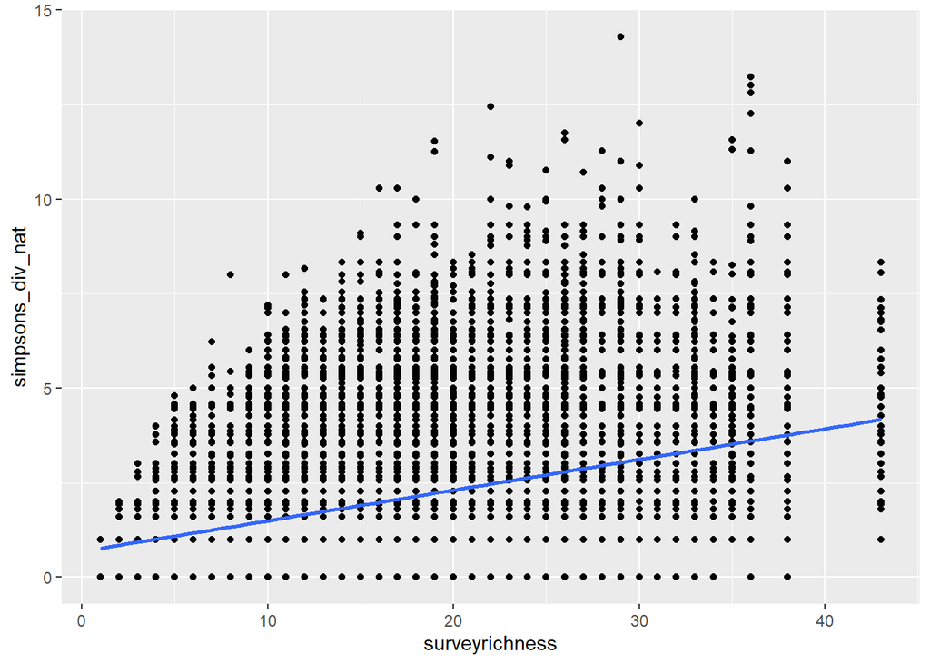

```r
ggplot( data = plants_rakeabund_wide, aes( surveyrichness, simpsons_div_nat))+
  geom_point()+
  geom_smooth(method = "lm")
```

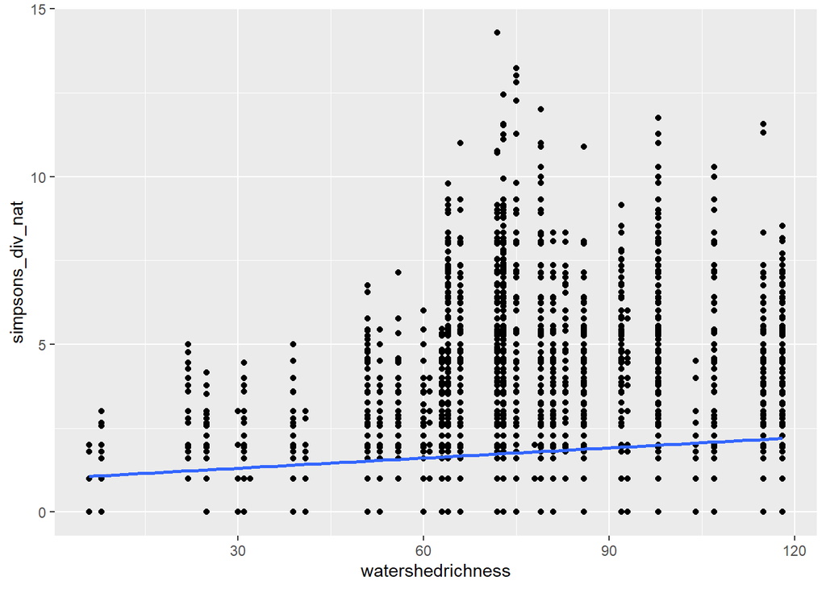

```r
# watershed richness as the predictor of a neighborhood:
ggplot( data = plants_rakeabund_wide, aes( watershedrichness, simpsons_div_nat))+
  geom_point()+
  geom_smooth(method = "lm")
```

```r
point_div_pools <- lm(simpsons_div_nat ~ surveyrichness + watershedrichness, data = plants_rakeabund_wide)
summary(point_div_pools)
```

```
##
## Call:
## lm(formula = simpsons_div_nat ~ surveyrichness + watershedrichness,
##     data = plants_rakeabund_wide)
##
## Residuals:
##     Min      1Q  Median      3Q     Max
## -3.7586 -0.9218 -0.1905  0.6813 11.2663
##
## Coefficients:
##                    Estimate Std. Error t value Pr(>|t|)
## (Intercept)       0.6439228  0.0201251  31.996   <2e-16 ***
## surveyrichness    0.0805866  0.0006178 130.431   <2e-16 ***
## watershedrichness 0.0005347  0.0002360   2.266   0.0235 *
## ---
## Signif. codes:  0 '***' 0.001 '**' 0.01 '*' 0.05 '.' 0.1 ' ' 1
##
## Residual standard error: 1.351 on 81903 degrees of freedom
## Multiple R-squared:  0.1886, Adjusted R-squared:  0.1886
## F-statistic:  9520 on 2 and 81903 DF,  p-value: < 2.2e-16
```

```r
point_ric_pools <- lm(nat_richness ~ surveyrichness + watershedrichness, data = plants_rakeabund_wide)
summary(point_ric_pools)
```

```
##
## Call:
## lm(formula = nat_richness ~ surveyrichness + watershedrichness,
##     data = plants_rakeabund_wide)
##
## Residuals:
##     Min      1Q  Median      3Q     Max
## -4.1032 -1.0413 -0.2320  0.7681 12.7056
##
## Coefficients:
##                    Estimate Std. Error t value Pr(>|t|)
## (Intercept)       6.891e-01  2.228e-02  30.926   <2e-16 ***
## surveyrichness    8.965e-02  6.841e-04 131.047   <2e-16 ***
## watershedrichness 7.642e-05  2.613e-04   0.292     0.77
## ---
## Signif. codes:  0 '***' 0.001 '**' 0.01 '*' 0.05 '.' 0.1 ' ' 1
##
## Residual standard error: 1.496 on 81903 degrees of freedom
## Multiple R-squared:  0.1886, Adjusted R-squared:  0.1886
## F-statistic:  9518 on 2 and 81903 DF,  p-value: < 2.2e-16
```

```r
point_evn_pools <- lm(nat_evenness ~ surveyrichness + watershedrichness, data = plants_rakeabund_wide)
summary(point_evn_pools)
```

```
##
## Call:
## lm(formula = nat_evenness ~ surveyrichness + watershedrichness,
##     data = plants_rakeabund_wide)
##
## Residuals:
##      Min       1Q   Median       3Q      Max
## -0.22136 -0.04763  0.03287  0.04580  0.09289
##
## Coefficients:
##                     Estimate Std. Error t value Pr(>|t|)
## (Intercept)        9.680e-01  1.118e-03 866.202   <2e-16 ***
## surveyrichness    -1.644e-03  3.176e-05 -51.770   <2e-16 ***
## watershedrichness  1.177e-04  1.268e-05   9.282   <2e-16 ***
## ---
## Signif. codes:  0 '***' 0.001 '**' 0.01 '*' 0.05 '.' 0.1 ' ' 1
##
## Residual standard error: 0.06467 on 70778 degrees of freedom
##   (11125 observations deleted due to missingness)
## Multiple R-squared:  0.03679,    Adjusted R-squared:  0.03676
## F-statistic:  1352 on 2 and 70778 DF,  p-value: < 2.2e-16
```